# Ch. 5 Vorticity Dynamics — fluidpy

← All chapters🎮 All explainers

← PreviousNext →

[▶ Open in Colab](https://colab.research.google.com/github/shammun/fluidpy/blob/main/notebooks/ch05_vorticity_dynamics_colab.ipynb) ↓ Download .ipynb [View on GitHub](https://github.com/shammun/fluidpy/blob/main/notebooks/ch05_vorticity_dynamics.ipynb)

## Interactive explainers in this chapter

🎮 1**Can a vortex just stop in the middle of the water?**Slide a cross-section along a narrowing, twisting vortex tube: its area and mean spin trade off while the flux through it (the tube's strength) stays pinned; break the field and Gauss' budget fails.🎮 2**Why is a spinning bucket a bowl and a drain a funnel?**Four vortices on one pair of axes — a spinning tank, an ideal line vortex, a Rankine core, a rotating cylinder — with their free surfaces and isobars, the radial force balance at a probe, and the viscous stress that the irrotational vortex has but does not feel.🎮 3**Stretch and tangle a loop of dye: what stays the same?**A loop of dye carried by six flows on one clock: its circulation stays flat while it is stretched and tangled, until you break one of Kelvin's hypotheses and the matching force term switches on; a loop painted on a vortex tube wall keeps zero circulation (Helmholtz).🎮 4**How can density make fluid spin?**A fluid disc with isobars and isopycnals: turn one set against the other and the pressure force's line of action leaves the centre of mass; the torque, divided by the moment of inertia, is the baroclinic spin-up; then the same torque tips over a lock exchange.🎮 5**How can a flow spin fluid faster without a torque?**A vortex line and a material element ride a chosen flow on one clock: stretching (purple) spins the line up, tilting (blue) turns it, both vanish in 2-D; viscosity (rose) joins in and Burgers' vortex holds stretching against diffusion, with the terms of the vorticity equation as bars.🎮 6**How does a vortex push water far away?**Drag a point around a straight, square, ring or helical vortex filament: every piece's push is drawn and summed; a long straight piece gives back the line vortex, and the printed sign of the Green's-function solution would spin everything backwards.🎮 7**What does a spinning planet add to the vorticity equation?**A column of fluid crossing a ridge, a ring of air moving poleward, and a term-bar budget of the rotating vorticity equation in three scenes: on a rotating planet the relative vorticity changes, but (ζ + f)/h and the absolute circulation do not.🎮 8**A vortex cannot push itself — so how do vortices move?**Drop vortices of either sign, drag them and press play: like vortices orbit their fixed centre of vorticity, opposite ones march off together, a vortex near a wall slides along it with its mirror twin — and the invariants stay flat.🎮 9**What is a velocity jump made of?**A row of N filaments becomes a clean velocity jump whose size is the sheet's strength; a thin circuit round it measures the strength as the jump in tangential velocity; ripple the sheet, press play and it rolls up.

# Chapter 5 — Vorticity Dynamics

*Fluid Mechanics, 5th edition — Pijush K. Kundu, Ira M. Cohen, David R. Dowling (2012).* This notebook teaches every new idea of the chapter with plain words, step-by-step mathematics, small worked examples, tested Python from the `fluidpy` package, figures, animations and interactive explainers. It does not reproduce the book's text or figures; equations are cited by their numbers so you can follow along in your copy.

**The big idea in one paragraph**

Vorticity — twice the local spin of the fluid — is the quantity that makes a flow swirl, and this chapter follows it: where it lives (vortex lines and tubes, which cannot end: $\int_V\nabla\cdot\boldsymbol\omega\,dV=-\Gamma_{\text{lower end}}+\Gamma_{\text{upper end}}=0$ *(Eq. 5.4)*), what it does to pressure (the bowl of a spinning bucket, the funnel of a drain), when it is conserved (Kelvin: $D\Gamma/Dt=0$ *(Eq. 5.8)*; Helmholtz: vortex lines move with the fluid), how it changes (it is carried, stretched, tilted and diffused: $\frac{D\boldsymbol\omega}{Dt}=(\boldsymbol\omega\cdot\nabla)\mathbf u+\nu\nabla^2\boldsymbol\omega$ *(Eq. 5.13)*; on a rotating planet with density contrasts it gains the planet's vorticity and a baroclinic source, $\frac{D\boldsymbol\omega}{Dt}=(\boldsymbol\omega+2\boldsymbol\Omega)\cdot\nabla\mathbf u+\frac1{\rho^2}\nabla\rho\times\nabla p+\nu\nabla^2\boldsymbol\omega$ *(Eq. 5.30)*), and how it makes velocity everywhere (Biot–Savart, $\mathbf u=\frac1{4\pi}\int\frac{\boldsymbol\omega\times(\mathbf x-\mathbf x')}{\lvert\mathbf x-\mathbf x'\rvert^3}d^3x'$ *(Eq. 5.16)*) — so that vortices push each other, slide along walls and roll up.

**Road map** — the new ideas of this chapter, in the order they build on each other:

1. §5.1 vortex lines and tubes, $\int_V\nabla\cdot\boldsymbol\omega\,dV=-\Gamma_{\text{lower end}}+\Gamma_{\text{upper end}}=0$ *(5.4)* (C01); the two basic vortices, their pressure $p-p_o=\tfrac18\rho\omega^2r^2-\rho gz$ *(5.6)* and $p-p_\infty=-\rho\Gamma^2/8\pi^2r^2-\rho gz$ *(5.7)* and their viscous stress (C02)
2. §5.2 Kelvin's circulation theorem $D\Gamma/Dt=0$ *(5.8)* and its proof (C03); barotropic vs baroclinic — the pressure torque (C04)
3. §5.3 Helmholtz's four vortex theorems: vortex lines move with the fluid (C05)
4. §5.4 the vorticity equation $\frac{D\boldsymbol\omega}{Dt}=(\boldsymbol\omega\cdot\nabla)\mathbf u+\nu\nabla^2\boldsymbol\omega$ *(5.13)* (C06)
5. §5.5 velocity from vorticity: Poisson, Green's function, Biot–Savart (5.16), $\mathbf u(\mathbf x,t)=\frac1{4\pi}\int_{V'}\frac{\boldsymbol\omega(\mathbf x',t)\times(\mathbf x-\mathbf x')}{\lvert\mathbf x-\mathbf x'\rvert^3}d^3x'$ (C07) and the filament law $d\mathbf u=\frac{\Gamma\,dl}{4\pi}\mathbf e_\omega\times\frac{\mathbf x-\mathbf x'}{\lvert\mathbf x-\mathbf x'\rvert^3}$ *(5.17)* (C08)
6. §5.6 the vorticity equation in a rotating frame *(5.30)* (C09); stretching and tilting (5.32), $\frac{D\omega_s}{Dt}=\omega\frac{\partial u_s}{\partial s},\ \frac{D\omega_n}{Dt}=\omega\frac{\partial u_n}{\partial s},\ \frac{D\omega_m}{Dt}=\omega\frac{\partial u_m}{\partial s}$ (C10); absolute circulation $D\Gamma_a/Dt=0$ *(5.33)* and the fluid column (C11)
7. §5.7 point vortices move each other (C12); images: a wall is a mirror vortex; rings near walls and leap-frogging (C13)
8. §5.8 vortex sheets: strength = jump in tangential velocity, $\gamma=u_2-u_1$ (C14)

**What you should already know** (each is recapped where it is used):

- vorticity $\boldsymbol\omega=\nabla\times\mathbf u$, spin ½ω, circulation $\Gamma=\oint\mathbf u\cdot d\mathbf x$ and the solid-body, line, Rankine and Gaussian vortices (Ch. 3 §3.4–3.5)
- Gauss' and Stokes' theorems, the ε–δ identity, the curl of a gradient (Ch. 2)
- Navier–Stokes, Euler, the viscous force $-\mu\nabla\times\boldsymbol\omega$, the Lamb identity, the Bernoulli function, rotating frames and Boussinesq (Ch. 4)
- hydrostatics (Ch. 1)

## 🎮 Interactive explainers in this chapter

| # | Explainer | What it makes clear |
| --- | --- | --- |
| 1 | **Can a vortex just stop in the middle of the water?** | C01: vortex lines and tubes; the strength is the same at every section |
| 2 | **Why is a spinning bucket a bowl and a drain a funnel?** | C02: the pressure of the two basic vortices; stress without net force |
| 3 | **Stretch and tangle a loop of dye — what stays the same?** | C03 C05: Kelvin's theorem and its hypotheses; Helmholtz |
| 4 | **How can density make fluid spin?** | C04: the pressure torque = ∇ρ×∇p/ρ²; the lock exchange |
| 5 | **How can a flow spin fluid faster without a torque?** | C06 C10: the vorticity equation, stretching and tilting, Burgers' vortex |
| 6 | **How does a vortex push water far away?** | C07 C08: Biot–Savart, the filament law, the sign of the Green's-function formula |
| 7 | **What does a spinning planet add to the vorticity equation?** | C09 C11: the rotating-frame vorticity equation, the fluid column, absolute circulation |
| 8 | **A vortex cannot push itself — so how do vortices move?** | C12 C13: pairs, the centre of vorticity, images |
| 9 | **What is a velocity jump made of?** | C14: sheet strength = jump; roll-up |

Each one opens right where its idea is taught and fills the window (no scrolling). Start with the **Walkthrough**, then **Explore** with the sliders and presets, read **Explain** (every number worked out with your settings, and what it means), step through the **Derivation** where there is one, read the **Equations** and the **Code**, and finish with **Check yourself**. On the web page they are full-window; in Colab and Jupyter they appear in the cell output (use ⤢ *Full screen* or *Open in new tab* for more room).

## ⚙️ Setup — run this cell first

It works in three places without changes:

- **Google Colab** — clones the public repository into `/content/fluidpy` (the `fluidpy` package, its tests and the interactive explainers) and installs the one package Colab lacks (`pint`). No GPU is needed.
- **Jupyter / VS Code on your computer** — finds the repository root (the folder with `book.yaml`) and imports from it.
- **The published web page** — already executed; nothing to run.

```python
# ── Setup: find (or fetch) the fluidpy repository, then load the house style ─────────────────────────────
import os, sys, subprocess, pathlib                     # standard library only, so this cell never fails on imports

IN_COLAB = "google.colab" in sys.modules                 # True when this notebook runs inside Google Colab
REPO_URL = "https://github.com/shammun/fluidpy.git"               # the public repository with the fluidpy package

if IN_COLAB:
    ROOT = pathlib.Path("/content/fluidpy")              # where the repository is cloned on Colab
    if not ROOT.exists():                                 # first run in this Colab session: clone it
        subprocess.run(["git", "clone", "--depth", "1", REPO_URL, str(ROOT)], check=True)
    else:                                                 # later runs: fetch the newest version
        subprocess.run(["git", "-C", str(ROOT), "pull", "--ff-only", "-q"], check=False)
    subprocess.run([sys.executable, "-m", "pip", "install", "-q", "-r", str(ROOT / "requirements-colab.txt")], check=True)
else:
    ROOT = pathlib.Path.cwd().resolve()                   # start where Jupyter was launched …
    while not (ROOT / "book.yaml").exists() and ROOT != ROOT.parent:
        ROOT = ROOT.parent                                # … and walk up until we find the repository root

os.chdir(ROOT)                                            # relative paths (outputs/, viz/) now resolve from the root
if str(ROOT) not in sys.path:
    sys.path.insert(0, str(ROOT))                         # make `import fluidpy` work

from fluidpy.core.style import setup_notebook            # matplotlib + plotly style shared with the explainers
from fluidpy.core.embed import show_viz                  # shows an interactive explainer in the notebook
from fluidpy.core.anim import show_animation             # plays a matplotlib animation inline
FAST = setup_notebook()                                   # FAST=True (env FLUIDPY_FAST=1) shrinks grids for quick runs
print(f"IN_COLAB = {IN_COLAB} | repository root: {ROOT} | FAST = {FAST}")
```

```
IN_COLAB = False | repository root: C:\Users\sislam27\Work\Climate Dynamics PHD\Fluid Dynamics | FAST = False
```

```python
import numpy as np                                      # arrays (Ch. 1 primer P03)
import sympy as sp                                      # symbolic algebra (Ch. 1 primer P40)
import matplotlib.pyplot as plt                         # static figures (Ch. 1 primer P01)
import plotly.graph_objects as go                       # rotatable 3-D figures (Ch. 1 P41, Ch. 2 P64)
from plotly.subplots import make_subplots               # several plotly panels in one figure
from fluidpy import ch05_vorticity_dynamics as ch05     # the tested chapter-5 module: every function cites its § and Eq.
from fluidpy.core import vortices, kinematics, constitutive, rotating, bernoulli, diffusion, tensors   # Ch. 1–4 machinery
from fluidpy.core import navier_stokes as ns            # Ch. 4's Navier–Stokes helpers (Lamb identity, exact fields)
from fluidpy.core import integral_theorems as itg       # Ch. 2's Gauss and Stokes helpers (loops, discs, boxes)
from fluidpy.core.interact import slider_figure         # plotly figure with a slider that works on the web page (P17)
from fluidpy.core.anim import animate, ffmpeg_path      # matplotlib animations (P16); show_animation came with the setup
from fluidpy.core.style import COLORS, savefig          # the house palette and a helper that saves PNGs to outputs/ch05
from tools.convergence import observed_order            # slope of log(error) vs log(step): the observed order (P13)
from scripts.ch05_drawings import disc_element, column_sketch, vortex_marks, sheet_circuit, biot_savart_geometry, helix_with_frame   # sketches drawn by our code
import logging, warnings                                # standard library: log levels and warning filters
logging.getLogger("matplotlib.font_manager").setLevel(logging.ERROR)   # hide harmless font-substitution notes
warnings.filterwarnings("ignore", category=RuntimeWarning)             # 0/0 on the axis of a vortex is handled by NaN on purpose
ffmpeg_path()                                           # find ffmpeg once (sets matplotlib's animation.ffmpeg_path)
ANIM_RC = {"axes.titleweight": "bold", "figure.constrained_layout.use": False, "savefig.dpi": 80}   # movies: light settings, 80 dpi frames (faster, smaller)


def recolor(fig, colors, dashes=None):                  # give plotly slider traces the notebook's colours by trace name
    for tr in fig.data:                                 # every trace of every slider step
        if tr.name in colors:                           # a name we assigned a colour to
            tr.line.color = colors[tr.name]             # same colour meaning as in the matplotlib figures
            tr.marker.color = colors[tr.name]           # markers too (for "markers" traces)
        if dashes and tr.name in dashes:                # optional dash pattern ("dash", "dot")
            tr.line.dash = dashes[tr.name]
    return fig                                          # the same figure, restyled


print(len([n for n in dir(ch05) if not n.startswith("_")]), "public names in fluidpy.ch05_vorticity_dynamics")   # the toolbox
```

```
189 public names in fluidpy.ch05_vorticity_dynamics
```

**What does the code above do?**

1. Numerical, symbolic and plotting libraries (all primed in Ch. 1–2).
2. `ch05` is the chapter module; it re-exports the new core modules of this chapter (`core.vorticity` — vortex lines, tubes, circulation theorems, vorticity-equation terms — and `core.biot_savart` — velocity from vorticity, point vortices, rings, sheets), so one name covers the whole chapter. Every function is tested in `tests/test_ch05.py`.
3. The core modules of Ch. 1–4 are called by module name (vortex profiles, stencils, stresses, rotating frames).
4. `scripts/ch05_drawings.py` holds a few drawing helpers (no physics): the fluid disc of the baroclinic torque, the columns over a ridge, vortex marks, the sheet circuit, the Biot–Savart geometry and the helix with its frame.
5. `recolor` only restyles plotly traces so that a colour always means the same thing.

**Notation, conventions and colours used in this notebook.**

| Symbol | Meaning | Unit |
| --- | --- | --- |
| $\boldsymbol\omega=\nabla\times\mathbf u$ | vorticity (**never** a rotation rate in this chapter) | 1/s |
| $u_r,\ u_\theta$ | polar velocity components | m/s |
| $\Gamma$ | circulation (of a loop, a vortex, a tube, a filament) | m²/s |
| $\gamma$ | strength of a vortex sheet (circulation per unit length) | m/s |
| $\omega_z$ | plane vorticity, counterclockwise positive | 1/s |
| $p,\ \rho$ | pressure, density | Pa, kg/m³ |
| $\mu,\ \nu=\mu/\rho$ | dynamic and kinematic viscosity | Pa s, m²/s |
| $\sigma_{ij}$ | viscous stress | Pa |
| $\boldsymbol\Omega$ | angular velocity of a rotating frame | rad/s |
| $2\boldsymbol\Omega$, $\boldsymbol\omega+2\boldsymbol\Omega$ | planetary vorticity, absolute vorticity | 1/s |
| $f=2\Omega\sin\varphi$, $\zeta$ | Coriolis parameter at latitude φ, relative vertical vorticity | 1/s |
| $\mathbf x'$ (with $\nabla'$, $V'$, $A'$) | the **source** point being integrated over in §5.5 | m |
| $(s,n,m)$ | natural coordinates along a vortex line (§5.6) | m |

> ⚠️ **ω is the vorticity.** In $u_\theta=\omega r/2$ the fluid turns at ω/2: a tank spinning at 1 rad/s has ω = 2 s⁻¹. Ch. 3's `solid_body_rotation(r, omega0)` takes the turning rate ω₀ = ω/2.

> ⚠️ **Γ and γ.** Γ (`Gamma`, m²/s) is always a circulation; the strength of a vortex sheet is γ (`gamma`, m/s) — the book writes Γ for it in §5.8.

> ⚠️ **σ and ε.** σ is the viscous stress here (Ch. 3's Gaussian core radius is written σ_c); ε is the Levi-Civita symbol $\varepsilon_{ijk}$ except in note N08, where ε is the dissipation rate.

> ⚠️ **Primes in §5.5** mark the source point x′ being integrated over, not a moving frame.

**Colours** (one meaning each, also in the explainers): relative vorticity **teal** · planetary vorticity **amber** · baroclinic **orange** · diffusion **rose** · stretching **purple** · tilting **blue** · advection **grey** · counterclockwise (positive) vortices **teal**, clockwise **rose** · isobars and pressure **orange**, isopycnals and density **blue** · references and ghosts **grey dashed**.

**Where this chapter is used later**

[output not shown]

*Climate hook:* Ch. 13's potential-vorticity conservation is the fluid column of C11 plus stratification; the sea breeze and every front start with the baroclinic torque of C04.

**Book slips we correct in this notebook** (each is explained where it is used):

[output not shown]

## 5.1 Introduction

**What is this section about?** Vorticity, $\boldsymbol\omega=\nabla\times\mathbf u$, is twice the spin of a fluid particle. This section gives the words for where it sits — vortex lines, vortex tubes and their strength — proves that a tube cannot end inside the fluid, and then looks hard at the two simplest vortices: the rigidly spinning bucket and the ideal line vortex. Their pressure fields explain a bowl-shaped and a funnel-shaped surface, and their viscous stresses teach that irrotational does not mean stress-free.

> 🔁 **Tools from earlier chapters used here** (see `knowledge/primers.md`)
- **functions as arguments and lambda** — `lambda x, t: …` is a one-line function; fluidpy takes fields as functions of (x, t) (Ch. 1 P29).
- **numpy arrays and vectorised arithmetic** — vectors and tables of numbers that do arithmetic element by element, no loops needed (Ch. 1 P03).
- **f-strings** — `f"{x:.4f}"` prints a number with 4 decimals inside a sentence (Ch. 1 P04).

> 🔁 **Recap — Vorticity and spin** (Ch. 3 §3.4). Vorticity is the curl of the velocity, $\boldsymbol\omega=\nabla\times\mathbf u$, and a small fluid element spins at ½ω (Ch. 3: the average turning rate of any two perpendicular material lines). A concentration of nearly parallel vorticity is a *vortex*; motion on nearly circular streamlines is *vortex motion*. Below, `kinematics.vorticity` takes the curl of a velocity function by central differences (Ch. 3 §3.4).

```python
u_sb = lambda x, t: np.array([-1.0*x[1], 1.0*x[0], 0*x[0]])        # solid body turning at 1 rad/s: u = (−y, x, 0) [m/s]
u_lv = vortices.vortex_velocity_field("line", Gamma=2*np.pi)        # the ideal line vortex with Γ = 2π m²/s (Ch. 3)
print(kinematics.vorticity(u_sb, np.array([0.3, 0.2, 0.0]))[2])     # ω_z of the solid body at a point: 2.0 1/s
print(kinematics.vorticity(u_lv, np.array([1.0, 0.5]))[-1])          # ω_z of the line vortex off its axis: ≈ 0 (1e-9)
```

```
1.9999999999997797
3.584355035002318e-09
```

**What does the code above do?**

The turning tank has vorticity twice its rotation rate everywhere (ω = 2 s⁻¹ for 1 rad/s); the line vortex has none off its axis (the 10⁻⁹ is the round-off of the central differences).

### 🧩 Vortex tubes cannot end `C01`

*The question:* A smoke ring, a tornado, the swirl down a drain — each is a tube of spinning fluid. Can such a tube simply fade out in the middle of the air or water?

*In one line:* $\int_V\nabla\cdot\boldsymbol\omega\,dV=\int_A\boldsymbol\omega\cdot\mathbf n\,dA=-\Gamma_{\text{lower end}}+\Gamma_{\text{upper end}}=0$ *(5.4)*

📝 **Note.** **The chapter's programme** `N01` — Think of vorticity as carried by fluid elements: an element's vorticity can be turned, concentrated or spread by how the element moves and deforms and by the torques of its neighbours. The rest of the chapter makes each of these precise — carried (C06), stretched and tilted (C10), twisted by baroclinic torques (C04, C09), spread by viscosity (N22).

#### The problem in plain words

When a weather forecaster tracks a cyclone, an engineer a wing-tip vortex or an oceanographer an eddy, they follow a tube of concentrated vorticity. What rules does such a tube obey whatever the flow does? The first rule is purely geometric, and it is strict: the tube's strength is the same all along it — so it can thin, fatten, bend and twist, but it cannot stop.

#### The idea

```
stream tube (Ch. 3)                      vortex tube (here)
walls made of streamlines                walls made of vortex lines
no flow crosses the wall                 no vorticity crosses the wall
div u = 0  =>  same volume flux Q        div w = 0 ALWAYS  =>  same strength Gamma at every section   (5.4)
thinner  =>  faster flow                 thinner  =>  stronger spin (mean w = Gamma / A)
```

*The numbered equations in the sketch:* $\int_V\nabla\cdot\boldsymbol\omega\,dV=\int_A\boldsymbol\omega\cdot\mathbf n\,dA=-\Gamma_{\text{lower end}}+\Gamma_{\text{upper end}}=0$ *(5.4)*

**A vortex tube carries a fixed amount of spin, like a hose carrying water — squeeze it and the spin speeds up.**

> 🔁 **Tools from earlier chapters used here** (see `knowledge/primers.md`)
- **parametric curves, tangent vector and arc length** — a curve $\mathbf x(s)$ with arc length s has unit tangent $d\mathbf x/ds$; `solve_ivp` traces it (Ch. 3 P92).
- **parallel vectors and the cross-product test** — two vectors are parallel when their cross product vanishes — the ratio form $dx/\omega_x=dy/\omega_y=dz/\omega_z$ says the same (Ch. 3 P93).
- **right-hand rule and orientation of a loop** — curl the fingers along the loop's direction; the thumb is the positive normal (Ch. 2 P74).

📝 **Note.** **Vortex lines** `N02` — are drawn tangent to ω everywhere, exactly as streamlines $dx/u=dy/v=dz/w$ *(3.7)* are drawn tangent to u:

$$ dx/\omega_x=dy/\omega_y=dz/\omega_z \qquad \text{(5.3)} $$

The ratio form breaks when a component is zero; we trace lines with the arc-length form $d\mathbf x/ds=\boldsymbol\omega/\lvert\boldsymbol\omega\rvert$ (Ch. 3 P92, P93). In solid-body rotation every vertical line is a vortex line; in the line vortex only the axis is. Irrotational flow has no vortex lines at all. Our test field below is a **helical swirl** $u_\varphi=aRz$ (a swirl that grows with height and radius), whose vorticity is $\omega_R=-aR$, $\omega_z=2az$; its vortex lines satisfy $dR/(-aR)=dz/(2az)$, i.e. $zR^2=$ const.

```python
u_h = ch05.helical_swirl_field(a=1.0)                               # u_φ = aRz with a = 1 1/(m s): a test velocity field [m/s]
om = ch05.vorticity_field(u_h)                                      # ω(x, t) of that field by central differences [1/s]
s, X = ch05.vortex_line(om, np.array([1.0, 0.0, 1.0]), s_max=1.5)   # one vortex line through (1, 0, 1) m: dx/ds = ω/|ω|  (5.3)
R = np.hypot(X[0], X[1])                                            # np.hypot(x, y) = √(x² + y²): distance from the z-axis [m]
print(X.shape, f"spread of z·R² along the line = {np.ptp(X[2]*R**2):.1e} m³")   # np.ptp = max − min: ≈ 0, so zR² is constant
```

```
(3, 400) spread of z·R² along the line = 4.5e-10 m³
```

**What does the code above do?**

1. `helical_swirl_field` builds the test velocity; `vorticity_field` turns any velocity function into its vorticity function (central differences).
2. `vortex_line` solves the arc-length equation $d\mathbf x/ds=\boldsymbol\omega/\lvert\boldsymbol\omega\rvert$ with `solve_ivp` in both directions from the seed point; `X` holds 400 points of the line.
3. Along the traced line $zR^2$ varies by less than 10⁻⁹ — the analytic answer of $dx/\omega_x=dy/\omega_y=dz/\omega_z$ (5.3).

📝 **Note.** **Tube and strength** `N03` — The vortex lines through a closed curve form a *vortex tube*. Its *strength* is the circulation round a loop on the tube that encircles it once — by Stokes' theorem $\int_A(\nabla\times\mathbf u)\cdot\mathbf n\,dA=\oint_C\mathbf u\cdot d\mathbf x$ *(2.34)*, the vorticity flux through a cross-section:

$$ \Gamma=\oint_C\mathbf u\cdot d\mathbf x=\int_A\boldsymbol\omega\cdot\mathbf n\,dA $$

| stream tube (Ch. 3) | vortex tube (here) |
| --- | --- |
| volume flux $dQ=\mathbf u\cdot\mathbf n\,dA$ | strength $d\Gamma=\boldsymbol\omega\cdot\mathbf n\,dA$ |
| same Q at every section when $\nabla\cdot\mathbf u=0$ | same Γ at every section, always |

**Number:** the Gaussian (Lamb–Oseen) vortex $u_\theta=\frac{\Gamma}{2\pi r}\big(1-e^{-r^2/\sigma_c^2}\big)$ *(3.29)* with Γ = 1 m²/s and σ_c = 0.1 m, measured on the circle r = σ_c: both routes give Γ(1 − e⁻¹) = 0.632 m²/s.

> 🔁 **Tools from earlier chapters used here** (see `knowledge/primers.md`)
- **named results (NamedTuple TubeStrength, TubeFlux)** — fluidpy returns results with named fields (`ts.circulation`, `ts.flux`) instead of bare tuples (Ch. 4 P111).

```python
u_g = vortices.vortex_velocity_field("gaussian", Gamma=1.0, sigma=0.1)   # Gaussian vortex (3.29): Γ = 1 m²/s, σ_c = 0.1 m (plane field)
loop = itg.planar_loop((0.0, 0.0), None, radius=0.1, n=512)             # the circle r = σ_c, counterclockwise, 512 points
disc = itg.planar_disc((0.0, 0.0), None, radius=0.1)                    # the disc it bounds (midpoint cells, Ch. 2)
ts = ch05.vortex_tube_strength(u_g, loop, disc)                         # Γ by ∮u·dx and by ∫ω·n dA (ω from stencils of u)
print(f"circulation {ts.circulation:.6f}   flux {ts.flux:.6f}   difference {ts.diff:.1e} m²/s")
print(f"exact Γ(1 − 1/e) = {1.0*(1 - np.exp(-1)):.6f} m²/s")             # the enclosed circulation of (3.29) at r = σ_c
Pc = ch05.circle_loop_points((0.0, 0.0), 0.1, n=512)                    # the same circle as a (2, N) array of points
print(f"clockwise loop: {ch05.loop_circulation(u_g, Pc[:, ::-1]):+.6f} m²/s")   # reversed order = opposite orientation: sign flips
```

```
circulation 0.632121   flux 0.632232   difference -1.1e-04 m²/s
exact Γ(1 − 1/e) = 0.632121 m²/s
```

```
clockwise loop: -0.632121 m²/s
```

**What does the code above do?**

1. The Gaussian vortex as a velocity function; a circle of radius σ_c and the disc inside it.
2. `vortex_tube_strength` measures the strength both ways: the line integral round the loop (the periodic trapezoid rule, primer P136 in C03 — spectrally accurate on a circle: 0.632121) and the flux of ω through the disc (the disc's midpoint cells and the stencil curl agree to four digits, 0.6322 — about 10⁻⁴ relative, the size of that quadrature's error).
3. Walking the loop the other way (points reversed) flips the sign: strength is measured with the right-hand rule.

#### 🧮 Derivation — A vortex tube has the same strength everywhere, so it cannot end: (5.4) `D01` (Eq. 5.4)

**What we want to show.** Show that the circulation measured round a vortex tube does not depend on where along the tube we measure it — and conclude that a tube (or a line) cannot simply stop in the middle of the fluid.

**Assumptions.** u twice continuously differentiable so ∇·ω = 0 (step 3); the tube wall is made of vortex lines (step 5). Nothing about viscosity, density or time: the result is kinematic.

**The plan.**

1. Cut a finite piece out of a tube.
2. Apply Gauss' theorem to ω on that piece.
3. Split the surface into its two ends and its side.
4. Read the end fluxes as tube strengths, minding the outward normals.

**Tools we use** (each explained before this point): Gauss' theorem $\int_V\nabla\cdot\mathbf Q\,dV=\int_A\mathbf Q\cdot\mathbf n\,dA$ (2.30) (Ch. 2 §2.12) · tube strength $\Gamma=\oint_C\mathbf u\cdot d\mathbf x=\int_A\boldsymbol\omega\cdot\mathbf n\,dA$ (N03, Stokes (2.34), $\int_A(\nabla\times\mathbf u)\cdot\mathbf n\,dA=\oint_C\mathbf u\cdot d\mathbf x$) · right-hand rule and orientation (ch02 P74, reminder).

**We start from**

$$ \nabla\cdot\boldsymbol\omega=\nabla\cdot(\nabla\times\mathbf u)=0 $$

*In words:* vorticity, being a curl, has no sources or sinks anywhere (R10, Ch. 2 §2.13).

**Step 1 of 7 — Cut a piece out of a vortex tube.**

$$ \partial V=A_{\text{lower}}\cup A_{\text{side}}\cup A_{\text{upper}} $$

- *Why we can do this:* Any finite stretch of tube is a closed volume V bounded by two cross-sections and the tube wall; we pick one so Gauss' theorem has a closed surface to work on.
- *In words:* A short length of tube is a sealed can: two lids and a wall.

**Step 2 of 7 — Apply Gauss' theorem to ω.**

$$ \int_V\nabla\cdot\boldsymbol\omega\,dV=\int_{\partial V}\boldsymbol\omega\cdot\mathbf n\,dA $$

- *Why we can do this:* Divergence theorem (2.30), $\int_V\nabla\cdot\mathbf Q\,dV=\int_A\mathbf Q\cdot\mathbf n\,dA$ with Q = ω, n the outward normal; allowed because ω is smooth. We want to turn a statement about the inside into one about the surface.
- *In words:* What the inside sources equals the net vorticity flux out through the skin.

**Step 3 of 7 — Use that ω has no divergence.**

$$ \int_{\partial V}\boldsymbol\omega\cdot\mathbf n\,dA=0 $$

- *Why we can do this:* ∇·(∇×u) = 0 for any smooth u (ch02, R10), so the volume integral is zero. The book states this after (5.4), $\int_V\nabla\cdot\boldsymbol\omega\,dV=\int_A\boldsymbol\omega\cdot\mathbf n\,dA=-\Gamma_{\text{lower end}}+\Gamma_{\text{upper end}}=0$; we use it first.
- *In words:* As much vorticity flux leaves the can as enters it.

**Step 4 of 7 — Split the skin into three pieces.**

$$ \Big\{\int_{\text{lower}}+\int_{\text{side}}+\int_{\text{upper}}\Big\}\boldsymbol\omega\cdot\mathbf n\,dA=0 $$

- *Why we can do this:* An integral over a surface made of pieces is the sum over the pieces (additivity). This is the first line of (5.4), $\int_V\nabla\cdot\boldsymbol\omega\,dV=\int_A\boldsymbol\omega\cdot\mathbf n\,dA=-\Gamma_{\text{lower end}}+\Gamma_{\text{upper end}}=0$.
- *In words:* Lower lid plus wall plus upper lid add to zero.

**Step 5 of 7 — Drop the wall: no flux through it.**

$$ \int_{\text{side}}\boldsymbol\omega\cdot\mathbf n\,dA=0 $$

- *Why we can do this:* The wall is built from vortex lines, so ω is tangent to it and ω·n = 0 there — not because ω vanishes on the wall.
- *In words:* Vorticity runs along the wall, never through it.

**Step 6 of 7 — Read each lid as a signed strength.**

$$ -\Gamma_{\text{lower end}}+\Gamma_{\text{upper end}}=0 $$

- *Why we can do this:* On the upper lid the outward n points along ω, giving +Γ; on the lower lid the outward n points against ω, giving −Γ (orientation, P74). This is (5.4), $\int_V\nabla\cdot\boldsymbol\omega\,dV=\int_A\boldsymbol\omega\cdot\mathbf n\,dA=-\Gamma_{\text{lower end}}+\Gamma_{\text{upper end}}=0$ — the line above.
- *In words:* The strength entering at the bottom equals the strength leaving at the top.

**Step 7 of 7 — Shrink a section to see "cannot end".**

$$ \bar\omega=\Gamma/A\to\infty\ \text{as}\ A\to0 $$

- *Why we can do this:* By step 6 every section carries the same Γ ≠ 0; Γ/A would blow up if a section closed to a point, so the tube must end on a wall or a free surface, or close on itself.
- *In words:* A tube can thin and spin faster, but never just stop.

**Result**

$$ \int_V\nabla\cdot\boldsymbol\omega\,dV=\int_A\boldsymbol\omega\cdot\mathbf n\,dA=-\Gamma_{\text{lower end}}+\Gamma_{\text{upper end}}=0 $$

*In words:* a vortex tube has one strength along its whole length; tubes and lines end only on boundaries or close as loops.

**What it means.** Helmholtz's second and third theorems are this one line; they hold in viscous flow too, because nothing dynamical was used. Squeeze a tube and its vorticity must grow (C10); a wing's bound vortex must continue as trailing vortices (Ch. 14).

**Check it.** Units: m²/s on both lids ✓. Numbers (the code cell after the tiny example of this block; narrowing Gaussian tube, Γ = 1 m²/s, a₀ = R₀ = 0.1 m, L = 1 m): flux 0.632121 at z = 0 and at z = 1 m while the area falls from 0.031416 to 0.011557 m² and the mean vorticity rises from 20.12 to 54.69 s⁻¹ ✓. Broken field (∇·ω ≠ 0): lower −0.632, upper +0.233, total −0.400 ≠ 0 — the theorem fails exactly where its hypothesis does ✓.

> ⚠️ **Common confusion (traps in `D01`):** Thinking the side has no flux because ω = 0 there (it is ω·n that vanishes). Dropping the minus sign of the lower lid. Believing "cannot end" needs an inviscid fluid.

#### ✏️ Tiny example: a tube squeezed to a quarter of its area

A thin vortex tube of strength Γ = 0.01 m²/s has a cross-section of 1 cm² = 10⁻⁴ m² at one place.

1. Mean vorticity there: $\bar\omega=\Gamma/A=0.01/10^{-4}=100$ s⁻¹.
2. Further along, the section is 0.25 cm² = 2.5×10⁻⁵ m². By (5.4), $-\Gamma_{\text{lower end}}+\Gamma_{\text{upper end}}=0$, the strength is still 0.01 m²/s.
3. So $\bar\omega=0.01/(2.5\times10^{-5})=400$ s⁻¹ — four times the spin for a quarter of the area.
4. The fluid spins at ½ω̄: from 50 to 200 rad/s, about 8 to 32 turns per second.

> 🔁 **Tools from earlier chapters used here** (see `knowledge/primers.md`)
- **np.meshgrid and the project grid layout** — `np.meshgrid(r, th, indexing="ij")` gives every (r, θ) pair; with indexing='ij' the rows run along the first argument, with the default 'xy' along the second (Ch. 2 P76).
- **volume and surface integrals as midpoint sums (polar grid)** — a surface integral is a sum of value × small area over cells; in polar cells the area is r dr dθ (Ch. 2 P83).
- **assert np.allclose** — `assert np.allclose(a, b)` stops the notebook if two results differ beyond rounding (Ch. 1 P15).

```python
for z in (0.0, 0.5, 1.0):                                            # three sections along the narrowing tube [m]
    sec = ch05.gaussian_tube_section(z, R0=0.1, Gamma=1.0, a0=0.1, L=1.0)   # the tube through R0 = 0.1 m at z = 0
    print(f"z = {z:.1f} m: radius {sec['radius']:.4f} m, area {sec['area']:.6f} m², flux {sec['flux']:.6f} m²/s, "
          f"mean ω {sec['mean_omega']:.2f} 1/s")                     # flux fixed, area down, mean vorticity up
print(ch05.tube_flux_budget("gaussian_tube", 0.0, 1.0, 0.1, Gamma=1.0, a0=0.1, L=1.0))   # Gauss on the piece 0 ≤ z ≤ 1 m: (5.4)
print(ch05.tube_flux_budget("broken", 0.0, 1.0, 0.1, Gamma=1.0, a0=0.1, L=1.0))         # a field that is NOT a curl
```

```
z = 0.0 m: radius 0.1000 m, area 0.031416 m², flux 0.632121 m²/s, mean ω 20.12 1/s
z = 0.5 m: radius 0.0779 m, area 0.019055 m², flux 0.632121 m²/s, mean ω 33.17 1/s
z = 1.0 m: radius 0.0607 m, area 0.011557 m², flux 0.632121 m²/s, mean ω 54.69 1/s
TubeFlux(lower=-0.6321205588285567, side=-2.2253453017074992e-12, upper=0.6321205588285566, total=-2.2254420528611263e-12)
TubeFlux(lower=-0.6321205588285567, side=0.0, upper=0.23254415793482922, total=-0.3995764008937275)
```

**What does the code above do?**

1. The **narrowing Gaussian tube** $\omega_z=(\Gamma/\pi a^2)e^{-R^2/a^2}$ with $a^2=a_0^2e^{-z/L}$ (plus the small inward ω_R that keeps it divergence-free): the tube through R₀ = 0.1 m keeps its flux 0.632121 m²/s while its area shrinks from 0.031416 to 0.011557 m² and its mean vorticity rises from 20.12 to 54.69 s⁻¹.
2. `tube_flux_budget` applies Gauss to the piece between z = 0 and 1 m: lower lid (outward normal against ω) −0.632121, wall ≈ 2×10⁻¹², upper lid +0.632121, total ≈ 0 — that is (5.4), $\int_V\nabla\cdot\boldsymbol\omega\,dV=\int_A\boldsymbol\omega\cdot\mathbf n\,dA=-\Gamma_{\text{lower end}}+\Gamma_{\text{upper end}}=0$.
3. The **broken** field $\omega=(\Gamma/\pi a_0^2)e^{-R^2/a_0^2}e^{-z/L}\mathbf e_z$ has $\nabla\cdot\boldsymbol\omega\ne0$: the upper lid carries only 0.232544, the total is −0.399576 — "vorticity" would be created inside, so it cannot be the curl of any velocity.

**From scratch — our own midpoint sums over the two lids** (polar cells of area r Δr Δθ):

```python
om_t = ch05.gaussian_tube_field(Gamma=1.0, a0=0.1, L=1.0)          # ω(x, t) of the narrowing Gaussian tube [1/s]
nr, nt = (200, 400) if not FAST else (100, 200)                      # radial and angular cells
flux = []                                                            # ∫ω_z dA over each lid [m²/s]
for z in (0.0, 1.0):                                                 # bottom lid, then top lid [m]
    Rt = 0.1*np.exp(-z/2)                                            # the tube's radius at this height [m]
    r = (np.arange(nr) + 0.5)/nr*Rt                                  # midpoints in r [m]
    th = (np.arange(nt) + 0.5)/nt*2*np.pi                            # midpoints in θ [rad]
    RR, TT = np.meshgrid(r, th, indexing="ij")                       # all (r, θ) cell centres
    Pts = np.array([RR*np.cos(TT), RR*np.sin(TT), z + 0*RR]).reshape(3, -1)   # their (x, y, z) positions, shape (3, N)
    dA = (RR*(Rt/nr)*(2*np.pi/nt)).ravel()                           # cell areas r Δr Δθ [m²]
    flux.append(np.sum(om_t(Pts, 0.0)[2]*dA))                        # Σ ω_z dA
print(f"bottom lid {flux[0]:.6f}, top lid {flux[1]:.6f} m²/s")       # the same number twice
assert np.allclose(flux[0], flux[1], rtol=1e-6)                      # (5.4): same strength at both sections
assert np.allclose(flux[1], ch05.tube_flux_budget("gaussian_tube", 0.0, 1.0, 0.1).upper, rtol=1e-4)   # = the library
```

```
bottom lid 0.632123, top lid 0.632123 m²/s
```

Our own sums over the two lids agree with each other and, to the accuracy of a midpoint rule, with the library.

> 🔁 **Tools from earlier chapters used here** (see `knowledge/primers.md`)
- **plotly 3-D lines and surfaces** — `go.Scatter3d(mode="lines")` draws a 3-D curve you can rotate with the mouse (Ch. 2 P64).

**Stream tube vs vortex tube (Fig. 5.1 analogue, note `N45`).** On the left, a stream tube in **Burgers' vortex** — a vortex fed by a flow drawn in sideways and stretched upward (derived in C10); on the right, a vortex tube of the narrowing Gaussian field, with its lids at z = 0 (blue) and z = 1 m (orange).

```python
nL = 12 if not FAST else 8                                           # lines per tube
fig = make_subplots(rows=1, cols=2, specs=[[{"type": "scene"}, {"type": "scene"}]],
                    subplot_titles=("stream tube (Burgers) [mm]", "vortex tube (Gaussian) [m]"))
u_burg = vortices.burgers_vortex_field(1e-3, 1.0, 1e-6)             # Burgers: Γ = 1e-3 m²/s, α = 1 1/s, ν = 1e-6 m²/s
for k in range(nL):                                                  # seeds on a circle of radius 3 mm at z = 1 mm
    th = 2*np.pi*k/nL                                                # seed angle [rad]
    x0 = np.array([3e-3*np.cos(th), 3e-3*np.sin(th), 1e-3])          # seed point [m]
    S = kinematics.streamline(u_burg, x0, 0.0, 0.12, False, 300)     # a streamline: tangent to u, 0.12 m of arc (3.7)
    fig.add_trace(go.Scatter3d(x=S[0]*1e3, y=S[1]*1e3, z=S[2]*1e3, mode="lines", showlegend=False,
                               line=dict(color=COLORS["blue"], width=3)), row=1, col=1)   # in mm
tube = ch05.vortex_tube(ch05.gaussian_tube_field(), (0, 0, 0), (0, 0, 1), 0.1, n_lines=nL, s_max=1.2, n=150, both=False)
for Lk in tube.lines:                                                # each vortex line of the tube, shape (3, n)
    fig.add_trace(go.Scatter3d(x=Lk[0], y=Lk[1], z=Lk[2], mode="lines", showlegend=False,
                               line=dict(color=COLORS["teal"], width=4)), row=1, col=2)
ph = np.linspace(0, 2*np.pi, 80)                                     # angles round a lid
for z, col in ((0.0, COLORS["blue"]), (1.0, COLORS["orange"])):      # lower lid blue, upper lid orange (D01 colours)
    Rl = 0.1*np.exp(-z/2)                                            # the tube's radius there [m]
    fig.add_trace(go.Scatter3d(x=Rl*np.cos(ph), y=Rl*np.sin(ph), z=z + 0*ph, mode="lines", showlegend=False,
                               line=dict(color=col, width=8)), row=1, col=2)
fig.update_layout(height=480, margin=dict(l=0, r=0, t=40, b=0), title="Two tubes: one carries volume, one carries spin")  # size, margins, title
fig.show()                                                                                          # draw it (works on the web page too)
```

[interactive chart not shown]

**What you see.** Left, blue streamlines that spiral round the axis and crowd together as they rise; right, teal vortex lines that converge toward the axis between a wide blue lid and a narrow orange one.

**How to read it.** Each tube's wall is made of its own lines, so nothing crosses it: the stream tube carries a fixed volume flux, the vortex tube a fixed strength — the orange lid carries exactly the blue lid's flux on 37 % (e⁻¹) of the area.

**What would change if…** …the twist of the vortex field turned on (`ch05.gaussian_tube_field(twist=5.0)`): the vortex lines become helices, the lids' fluxes do not change.

> 🔁 **Tools from earlier chapters used here** (see `knowledge/primers.md`)
- **log axes** — on a logarithmic axis equal ratios are equal distances, so a quantity that doubles and one that halves look symmetric (Ch. 1 P13).
- **matplotlib figures and labels with units** — `fig, ax = plt.subplots()`, `ax.plot`, axis labels always with units (Ch. 1 P01).

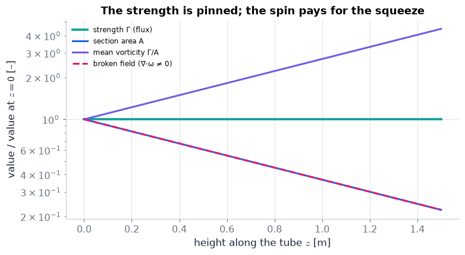

```python
zz = np.linspace(0.0, 1.5, 31)                                       # heights along the tube [m]
secs = [ch05.gaussian_tube_section(z) for z in zz]                   # R0 = a0 = 0.1 m, Γ = 1 m²/s, L = 1 m
flux = np.array([s["flux"] for s in secs])                           # tube strength [m²/s]
area = np.array([s["area"] for s in secs])                           # section area [m²]
wbar = np.array([s["mean_omega"] for s in secs])                     # mean vorticity [1/s]
broken = np.array([ch05.tube_flux_budget("broken", 0.0, z, 0.1).upper if z > 0 else flux[0] for z in zz])   # "flux" of the broken field
fig, ax = plt.subplots(figsize=(7, 3.8))                             # one panel
ax.semilogy(zz, flux/flux[0], color=COLORS["teal"], lw=2.5, label="strength Γ (flux)")                   # flat
ax.semilogy(zz, area/area[0], color=COLORS["blue"], lw=2, label="section area A")                        # falls as e^{−z/L}
ax.semilogy(zz, wbar/wbar[0], color=COLORS["accent"], lw=2, label="mean vorticity Γ/A")                   # rises as e^{z/L}
ax.semilogy(zz, broken/broken[0], color=COLORS["rose"], ls="--", lw=2, label="broken field (∇·ω ≠ 0)")   # falls: not a tube
ax.set_xlabel("height along the tube $z$ [m]"); ax.set_ylabel("value / value at $z=0$ [–]")               # axis labels with units
ax.set_title("The strength is pinned; the spin pays for the squeeze"); ax.legend(fontsize=8)
savefig(fig, "ch05", "tube_strength"); plt.show()                    # save the PNG to outputs/ch05, then draw
```

**What you see.** A flat teal line, a falling blue curve and a rising purple one that mirror each other; the dashed rose line falls like the area.

**How to read it.** Flux = area × mean vorticity stays constant along the tube, $-\Gamma_{\text{lower end}}+\Gamma_{\text{upper end}}=0$ (5.4); only a field that is not a curl lets the "strength" change along a tube.

**What would change if…** …L = 0.5 m (a faster narrowing): the area and mean-ω curves steepen twice as fast; the flux line does not move.

> 🔁 **Tools from earlier chapters used here** (see `knowledge/primers.md`)
- **show_viz and embedded explainers** — `show_viz("ch05", slug)` displays an interactive explainer in the output; on the web page it fills the window (Ch. 1 P18).

#### 🎮 Interactive: Can a vortex just stop in the middle of the water?

**Why interactive rather than a static figure:** a static figure shows one section; here you slide the section along a narrowing, twisting tube and watch the flux stay pinned while the area and the spin trade off — then break the field and watch Gauss' budget fail.

**What to try:**

- Drag the section from z = 0 to z = 1 m and watch the lid-flux bars: they stay equal while the mean ω grows by e ≈ 2.7.
- Switch to the twisted tube: the lines spiral, the wall bar stays at zero.
- Choose the broken field: the upper lid carries less than the lower — the badge says why this cannot be a vorticity field.
- Open the Derivation tab and step through D01 with the three coloured pieces (lower lid blue, wall grey, upper lid orange).

```python
show_viz("ch05", "vortex_tubes_cannot_end")   # full-width explainer; ⤢ Full screen for more room
```

🎮 Interactive 1/9 Can a vortex just stop in the middle of the water? Open alone ↗

[interactive chart not shown]

> ⚠️ **Common confusion:** "the side of the tube carries no flux because the vorticity is zero there." The vorticity on the wall can be large; it simply points *along* the wall ($\boldsymbol\omega\cdot\mathbf n=0$).

**What would change if…** …the fluid were viscous? Nothing in (5.4), $\int_V\nabla\cdot\boldsymbol\omega\,dV=\int_A\boldsymbol\omega\cdot\mathbf n\,dA=-\Gamma_{\text{lower end}}+\Gamma_{\text{upper end}}=0$ changes: it is geometry, true for every flow, because $\nabla\cdot(\nabla\times\mathbf u)=0$ always. Viscosity will change *which* lines form a tube as time goes on (C05) — but at every instant each tube has one strength.

> 🔁 **Recap — Solid-body rotation from uniform vorticity** (Ch. 3 §3.5). A uniform plane-normal vorticity ω makes the fluid turn rigidly: $u_\theta=\omega r/2$ *(Eq. 5.1)* — Ch. 3's $u_r=0,\ u_\theta=\omega_0r$ *(3.22)* with the rotation rate ω₀ = ω/2. ⚠️ Here ω is the vorticity: a tank turning at Ω_tank = 5 rad/s has ω = 10 s⁻¹. (Fig. 5.2 labels the tank's rotation "2ω" — with $u_\theta=\omega r/2$ the tank turns at ω/2.)

```python
print(ch05.solid_body_from_vorticity(0.1, 10.0))                    # (u_θ, ω_z) at r = 0.1 m for ω = 10 1/s: (0.5 m/s, 10 1/s)
print(vortices.solid_body_rotation(0.1, 5.0))                        # Ch. 3's function takes the turning rate 5 rad/s: 0.5 m/s
```

```
(0.5, 10.0)
0.5
```

> 🔁 **Recap — The ideal line vortex** (Ch. 3 §3.5). A perfect concentration of vorticity on the axis with circulation Γ gives $u_\theta=\Gamma/2\pi r$ *(Eq. 5.2)* — Ch. 3's $u_r=0,\ u_\theta=B/r$ *(3.25)* with Γ = 2πB; irrotational for r > 0, and $\oint\mathbf u\cdot d\mathbf x=\Gamma$ on every circle round the axis.

```python
print(ch05.line_vortex_gamma(0.1, 1.0))                              # (u_θ, ω_z) at r = 0.1 m for Γ = 1 m²/s: (1.5915 m/s, 0)
print([vortices.circulation_circle(lambda r: ch05.line_vortex_gamma(r, 1.0)[0], r) for r in (0.1, 1.0)])   # Γ on two circles: 1, 1
```

```
(1.5915494309189533, 0.0)
[0.9999999999999999, 1.0]
```

> 🔁 **Recap — Paddle wheels in the two vortices** (Ch. 3 §3.5). Both vortices are steady with circular streamlines, but only the first turns a paddle wheel; in the line vortex a small wheel travels round the axis without spinning. The Ch. 3 explainer `vortex_paddle_wheels` shows it (open it from the Ch. 3 page; it is not embedded again).

> 🔁 **Recap — No deformation, no viscous stress** (Ch. 4 §4.5–4.6). Solid-body rotation does not deform elements, $S_{ij}=0$, so the Newtonian stress $\tau_{ij}=-p\,\delta_{ij}+2\mu\big(S_{ij}-\tfrac13S_{mm}\delta_{ij}\big)+\mu_vS_{mm}\delta_{ij}$ *(4.37)* is pure pressure, $\tau_{ij}=-p\delta_{ij}$, and Cauchy's equation $\rho\frac{Du_j}{Dt}=\rho g_j+\frac{\partial\tau_{ij}}{\partial x_i}$ *(4.24)* reduces to Euler's $\rho\frac{D\mathbf u}{Dt}=-\nabla p+\rho\mathbf g$ *(4.41)*.

```python
G_sb = np.array([[0, -5.0, 0], [5.0, 0, 0], [0, 0, 0]])               # velocity gradient of a tank turning at 5 rad/s [1/s]
print(constitutive.newtonian_stress(G_sb, p=1.0e5, mu=1e-3))         # stress [Pa]: diag(−1e5, −1e5, −1e5), no shear — pure pressure
```

```
[[-100000.       0.       0.]
 [      0. -100000.       0.]
 [      0.       0. -100000.]]
```

> 🔁 **Recap — Hydrostatics** (Ch. 1 §1.7). With no vertical motion the vertical momentum balance is hydrostatic: $0=-\partial p/\partial z-\rho g$ *(Eq. 5.5b)* — Ch. 1's $dp/dz=-\rho g$ *(1.8)*.

> 🔁 **Recap — The Bernoulli function across streamlines** (Ch. 4 §4.9). $B=\tfrac12u^2+\int dp/\rho+gz$ (4.69) is constant along streamlines in steady inviscid barotropic flow, and constant everywhere only if the flow is also irrotational — $\tfrac12u_i^2+\int_{p_o}^{p}\frac{dp'}{\rho(p')}+gz=\text{const everywhere}$ *(4.72)*. Ch. 4's `which_bernoulli` explainer shows the four versions.

> 🔁 **Recap — The Rankine vortex** (Ch. 3 §3.5). Uniform vorticity inside r ≤ a, a line vortex outside: $u_\theta=\frac{\Gamma r}{2\pi\sigma^2}\ (r\le\sigma),\ \frac{\Gamma}{2\pi r}\ (r>\sigma)$ *(3.28)* with σ = a. A solid cylinder of radius a spinning at ω/2 in viscous fluid drives exactly the outer part, $u_\theta=\omega a^2/2r$, with Γ = πa²ω (Ch. 8 solves it).

```python
print(ch05.rotating_cylinder_flow(np.array([0.05, 0.1, 0.2]), 0.1, 10.0))   # (u_θ, ω_z) at r = 5, 10, 20 cm; a = 0.1 m, ω = 10 1/s
print(f"Γ = πa²ω = {np.pi*0.1**2*10.0:.4f} m²/s")                    # the cylinder's circulation
```

```
(array([0.25, 0.5 , 0.25]), array([10., 10.,  0.]))
Γ = πa²ω = 0.3142 m²/s
```

### 🧩 The bowl and the funnel: pressure in the two basic vortices `C02`

*The question:* Spin a bucket of water and its surface becomes a bowl; pull the plug of a bath and a narrow funnel appears. Why the different shapes — and which of the two vortices is the viscous one?

*In one line:* $p(r,z)-p_o=\tfrac18\rho\omega^2r^2-\rho gz$ *(5.6)* · $p(r,z)-p_\infty=-\frac{\rho\Gamma^2}{8\pi^2r^2}-\rho gz$ *(5.7)*

#### The problem in plain words

Every vortex in nature, from a stirred cup to a tornado to a hurricane's eye wall, keeps its fluid on curved paths, and something must push that fluid inward: pressure, lower at the centre. How much lower depends on how the speed varies with radius. The same two basic profiles, $u_\theta=\omega r/2$ (5.1) and $u_\theta=\Gamma/2\pi r$ (5.2), also settle a subtle question about viscosity: the vortex whose fluid does *not* rotate is the one with viscous stress.

#### The idea

```
every parcel on a circle needs an inward push  rho u^2/r  ->  pressure rises outward: dp/dr = rho u^2/r        (5.5a)
solid body  u = w r/2       : push grows with r          ->  p ~ r^2    -> a BOWL (paraboloid)     no viscous stress
line vortex u = Gamma/2pi r : push ~ 1/r^3 near the axis ->  p ~ -1/r^2 -> a deep FUNNEL          stress, zero net force
```

*The numbered equations in the sketch:* $-\rho u_\theta^2/r=-\partial p/\partial r$ *(5.5a)*

> 🔁 **Tools from earlier chapters used here** (see `knowledge/primers.md`) — needed in the derivation below
- **cylindrical and spherical unit vectors** — $\mathbf e_r,\ \mathbf e_\theta,\ \mathbf e_z$ point outward, round and up; they change direction from point to point (Ch. 3 P88).
- **derivative of a rotating unit vector ∂e_θ/∂θ = −e_r** — moving round a circle, $\mathbf e_\theta$ turns toward the axis: $\partial\mathbf e_\theta/\partial\theta=-\mathbf e_r$ (Ch. 4 P124).
- **sympy symbols, diff, simplify, Function** — `sp.symbols`, `sp.Function('f')(z)` (an unknown function), `sp.diff`, `sp.simplify` (Ch. 1 P40).

> 📎 **Primer — partial integration with an unknown function.** `P134` · When you integrate a partial derivative ∂p/∂r with respect to r, the "constant" of integration may depend on the other variable z, because ∂/∂r of any f(z) is zero. So ∂p/∂r = 2r gives p = r² + f(z), and a second equation (for ∂p/∂z) fixes f. Derivation D02 uses exactly this.

```python
r, z = sp.symbols('r z')                     # two variables
f = sp.Function('f')                         # an unknown function of z alone
p = sp.integrate(2*r, r) + f(z)              # ∂p/∂r = 2r integrated in r, plus the "constant" f(z)
print(p, sp.diff(p, r))                      # r**2 + f(z), 2*r: the f(z) is invisible to ∂/∂r
```

```
r**2 + f(z) 2*r
```

📝 **Note.** **Viscosity re-enters** `N04` — Viscosity diffuses vorticity and lets vortex lines *reconnect* — cut and rejoin — which an ideal fluid forbids (C05). The book only names reconnection; it returns with turbulence (Ch. 12). Here we look at the two basic vortices with viscosity switched on.

#### 🧮 Derivation — Pressure in a steadily rotating tank: Euler → (5.5a, b) → (5.6) `D02` (Eq. 5.6)

**What we want to show.** Find the pressure everywhere in a tank of water turning like a solid body, and from it the bowl shape of every surface of constant pressure — including the free surface.

**Assumptions.** Steady (step 3); axisymmetric, ∂/∂θ = 0 (step 3); gravity −g e_z with z up (step 6); ρ and g constant (steps 8–9).

**The plan.**

1. Show the stress is pure pressure, so Euler applies.
2. Compute the particle acceleration in polar coordinates.
3. Write the r- and z-components, (5.5a, b).
4. Integrate each and match them.

**Tools we use** (each explained before this point): Newtonian stress with S = 0 (R05) · derivative of a rotating unit vector ∂e_θ/∂θ = −e_r (ch03 P88, ch04 P124, reminders) · partial integration with an unknown function (primer in C02) · hydrostatics (R06).

**We start from**

$$ \mathbf u=u_\theta\mathbf e_\theta,\ u_\theta=\omega r/2\ \text{(5.1) and Cauchy's equation}\ \rho\frac{Du_j}{Dt}=\rho g_j+\frac{\partial\tau_{ij}}{\partial x_i}\ \text{(4.24)} $$

*In words:* the fluid turns rigidly; ω is the vorticity, so the tank turns at ω/2 (⚠️ Fig. 5.2's label "2ω" is a slip).

**Step 1 of 10 — Note there is no viscous stress.**

$$ S_{ij}=0\ \Rightarrow\ \tau_{ij}=-p\,\delta_{ij} $$

- *Why we can do this:* Rigid rotation does not deform elements (ch03), and the Newtonian law (4.37), $\tau_{ij}=-p\,\delta_{ij}+2\mu\big(S_{ij}-\tfrac13S_{mm}\delta_{ij}\big)+\mu_vS_{mm}\delta_{ij}$ makes the viscous stress proportional to S. So Cauchy (4.24), $\rho\frac{Du_j}{Dt}=\rho g_j+\frac{\partial\tau_{ij}}{\partial x_i}$ becomes Euler (4.41), $\rho\frac{D\mathbf u}{Dt}=-\nabla p+\rho\mathbf g$.
- *In words:* In a rigidly turning tank only pressure pushes on a parcel.

**Step 2 of 10 — Write Euler's equation for this flow.**

$$ \rho\frac{D\mathbf u}{Dt}=-\nabla p-\rho g\,\mathbf e_z $$

- *Why we can do this:* Euler (4.41), $\rho\frac{D\mathbf u}{Dt}=-\nabla p+\rho\mathbf g$ with g = −g e_z. We need Du/Dt in polar components to read off each balance.
- *In words:* Mass times acceleration equals the pressure push plus the weight.

**Step 3 of 10 — Keep only the turning of the velocity.**

$$ \frac{D\mathbf u}{Dt}=\frac{u_\theta}{r}\frac{\partial}{\partial\theta}\big(u_\theta\mathbf e_\theta\big) $$

- *Why we can do this:* The book skips this: steady (∂/∂t = 0) and u = u_θ e_θ, so (u·∇) = (u_θ/r)∂/∂θ. u_θ does not depend on θ, but the unit vector e_θ does.
- *In words:* A particle keeps its speed; only its direction changes.

**Step 4 of 10 — Differentiate the turning unit vector.**

$$ \frac{D\mathbf u}{Dt}=-\frac{u_\theta^2}{r}\,\mathbf e_r $$

- *Why we can do this:* ∂e_θ/∂θ = −e_r (the unit vector turns toward the axis; ch03 P88). This is the centripetal acceleration, pointing inward.
- *In words:* Going round a circle means accelerating toward its centre.

**Step 5 of 10 — Take the radial component.**

$$ -\rho u_\theta^2/r=-\partial p/\partial r $$

- *Why we can do this:* Dot step 2 with e_r using step 4. This is (5.5a), $-\rho u_\theta^2/r=-\partial p/\partial r$ — the line above: only a pressure rising outward can supply the inward acceleration.
- *In words:* Pressure must grow with radius to hold every parcel on its circle.

**Step 6 of 10 — Take the vertical and azimuthal components.**

$$ 0=-\partial p/\partial z-\rho g,\qquad \partial p/\partial\theta=0 $$

- *Why we can do this:* The acceleration has no z or θ part. The z-balance is (5.5b), $0=-\partial p/\partial z-\rho g$, plain hydrostatics (R06); the θ-balance says p is axisymmetric.
- *In words:* Vertically the water just holds up its own weight.

**Step 7 of 10 — Substitute the solid-body speed.**

$$ \frac{\partial p}{\partial r}=\frac{\rho\omega^2r}{4} $$

- *Why we can do this:* u_θ = ωr/2 (5.1), $u_\theta=\omega r/2$, so u_θ²/r = ω²r/4. Using ω as the rotation rate here would give ω²r, four times too big — the classic trap.
- *In words:* The outward pressure gradient grows linearly with radius.

**Step 8 of 10 — Integrate in r at fixed z.**

$$ p(r,z)=\frac{\rho\omega^2r^2}{8}+f(z) $$

- *Why we can do this:* Integrating a partial derivative leaves a "constant" that may depend on the variable held fixed (primer: partial integration). The book writes this line; it is the first of two.
- *In words:* The pressure is a bowl in r plus an unknown function of height.

**Step 9 of 10 — Fix f(z) with the vertical balance.**

$$ f'(z)=-\rho g\ \Rightarrow\ f(z)=p_o-\rho gz $$

- *Why we can do this:* Differentiate step 8 in z and compare with step 6: only f depends on z. p_o is the pressure at r = 0, z = 0.
- *In words:* The unknown function is ordinary hydrostatic pressure.

**Step 10 of 10 — Assemble and solve for an isobar.**

$$ p-p_o=\tfrac18\rho\omega^2r^2-\rho gz\ \Rightarrow\ z=\frac{\omega^2r^2}{8g}-\frac{p-p_o}{\rho g} $$

- *Why we can do this:* Put f into step 8: that is (5.6), $p(r,z)-p_o=\tfrac18\rho\omega^2r^2-\rho gz$. Holding p fixed and solving for z gives the height of an isobar.
- *In words:* Every surface of constant pressure — the free surface too — is a paraboloid.

**Result**

$$ p(r,z)-p_o=\tfrac18\rho\omega^2r^2-\rho gz\ \text{(5.6), isobars}\ z=\frac{\omega^2r^2}{8g}-\frac{p(r,z)-p_o}{\rho g} $$

*In words:* the pressure rises with radius just enough to turn every parcel, so constant-pressure surfaces are paraboloids.

**What it means.** The same inward pressure force turns every vortex — cyclostrophic balance in a tornado, the gradient wind of Ch. 13. Since u_θ²/2 = ω²r²/8, (5.6), $p(r,z)-p_o=\tfrac18\rho\omega^2r^2-\rho gz$ reads −½u_θ² + gz + p/ρ = const: the Bernoulli function B = ½u_θ² + gz + p/ρ grows outward (R07) — as it must in a rotational flow.

**Check it.** Units: ρω²r² is kg m⁻³ s⁻² m² = Pa ✓. ∂p/∂r = ρω²r/4 = ρu_θ²/r ✓ (5.5a), $-\rho u_\theta^2/r=-\partial p/\partial r$; ∂p/∂z = −ρg ✓ (5.5b), $0=-\partial p/\partial z-\rho g$. ω = 0 gives hydrostatics ✓. Numbers: tank at 5 rad/s (ω = 10 s⁻¹), R = 0.1 m: 12.7 mm rim–centre height ✓; volume conservation puts the vertex 6.37 mm below the rest level (the code cell after note N05 prints it).

> ⚠️ **Common confusion (traps in `D02`):** Using ω as the tank's rotation rate (Fig. 5.2's "2ω" invites it). Getting −u_θ²/r from ∂u_θ/∂θ (it is zero) instead of from the turning e_θ. Treating f as a constant.

📝 **Note.** **The radial balance** `N05` — D02's step 5 is (5.5a): pressure supplies the centripetal acceleration. At r = 0.1 m in a tank with ω = 10 s⁻¹ ($u_\theta$ = 0.5 m/s): ∂p/∂r = 1000 × 0.25/0.1 = 2500 Pa/m.

$$ -\rho u_\theta^2/r=-\partial p/\partial r \qquad \text{(5.5a)} $$

> 🔁 **Tools from earlier chapters used here** (see `knowledge/primers.md`)
- **scipy.optimize.brentq** — finds the root of a function between two points where it changes sign (Ch. 3 P108) — used for the dry radius of a fast-spun tank.

```python
print(ch05.solid_body_pressure_gradients(0.1, 0.0, 10.0))           # (∂p/∂r, ∂p/∂z) at r = 0.1 m, ω = 10 1/s: (2500, −9810) Pa/m
print(ch05.solid_body_pressure(0.1, 0.0, 10.0), ch05.isobar_height(0.1, 10.0, kind="solid"))   # p − p_o = 125 Pa; isobar through the origin 12.74 mm up
tank = ch05.rotating_tank_free_surface(0.1, 0.1, 5.0)                # tank radius 0.1 m, 0.1 m deep, spun at 5 rad/s
print({k: round(tank[k], 6) for k in ("z_vertex", "z_rim", "rim_rise", "centre_drop", "r_dry")}, tank["spills"])   # heights [m]
R, Z, w, rho, g = sp.symbols('r z omega rho g', positive=True)      # symbols for the sympy check
p = rho*w**2*R**2/8 - rho*g*Z                                        # (5.6) with p_o = 0
print(sp.simplify(sp.diff(p, R) - rho*(w*R/2)**2/R), sp.simplify(sp.diff(p, Z) + rho*g))   # both 0: (5.5a) and (5.5b) hold
```

```
(2500.0, -9810.0)
125.00000000000003 0.012742099898063203
{'z_vertex': 0.093629, 'z_rim': 0.106371, 'rim_rise': 0.006371, 'centre_drop': 0.006371, 'r_dry': 0.0} False
0 0
```

**What does the code above do?**

1. The two gradients of $-\rho u_\theta^2/r=-\partial p/\partial r$ (5.5a) and $0=-\partial p/\partial z-\rho g$ (5.5b).
2. The pressure of $p-p_o=\tfrac18\rho\omega^2r^2-\rho gz$ (5.6) at r = 0.1 m (125 Pa) and the height of the isobar through the origin there (12.742 mm = ω²R²/8g).
3. A real tank of radius 10 cm filled 10 cm deep, spun at 5 rad/s: the water keeps its volume, so the centre drops by exactly as much as the rim rises, 6.371 mm each (vertex at 0.093629 m, rim at 0.106371 m); nothing dries, nothing spills.
4. sympy confirms (5.6), $p(r,z)-p_o=\tfrac18\rho\omega^2r^2-\rho gz$ satisfies both (5.5a) and (5.5b).

> 🔁 **Tools from earlier chapters used here** (see `knowledge/primers.md`)
- **trapezoid rule and cumulative_trapezoid** — `scipy.integrate.cumulative_trapezoid(y, x, initial=0)` returns the running integral ∫y dx at every x (Ch. 1 P37).

**From scratch — add up $\rho u_\theta^2/r\,dr$ ourselves** and compare with the library's bowl and funnel:

```python
from scipy.integrate import cumulative_trapezoid                     # running trapezoid sum
r = np.linspace(0, 0.1, 2001)                                        # radii from the axis to 10 cm [m]
dpdr = 1000*(10*r/2)**2/np.where(r > 0, r, 1)                        # ρu_θ²/r for the tank, ω = 10 1/s [Pa/m] (0 on the axis)
p_num = cumulative_trapezoid(dpdr, r, initial=0.0)                   # p(r) − p(0) [Pa]
assert np.allclose(p_num, ch05.solid_body_pressure(r, 0.0, 10.0), atol=1e-6)   # = (5.6): the bowl
rr = np.linspace(1.0, 0.1, 40001)                                    # the funnel: from r = 1 m inward to 0.1 m [m]
dp = 1000*(1/(2*np.pi*rr))**2/rr                                     # ρu_θ²/r for Γ = 1 m²/s [Pa/m]
p_f = ch05.line_vortex_pressure(1.0, 0.0, 1.0) + cumulative_trapezoid(dp, rr, initial=0.0)   # integrate inward from p(1 m)
print(f"funnel at r = 0.1 m: ours {p_f[-1]:.3f} Pa, library {ch05.line_vortex_pressure(0.1, 0.0, 1.0):.3f} Pa")
assert np.allclose(p_f[-1], ch05.line_vortex_pressure(0.1, 0.0, 1.0), rtol=1e-6)   # = (5.7): the funnel
```

```
funnel at r = 0.1 m: ours -1266.515 Pa, library -1266.515 Pa
```

**Recap R07 used: B across streamlines.** With $\rho\omega^2r^2/8=\rho u_\theta^2/2$, (5.6), $p(r,z)-p_o=\tfrac18\rho\omega^2r^2-\rho gz$ reads $-\tfrac12u_\theta^2+gz+\frac{p(r,z)}{\rho}=\text{const}$ — so the Bernoulli function $B=u_\theta^2/2+gz+p/\rho$ **grows** outward, $B-B(0)=\omega^2r^2/4$, as it must in a rotational flow (4.71)–(4.72), $\tfrac12u_i^2+\int_{p_o}^{p}\frac{dp'}{\rho(p')}+gz=\text{const everywhere}$. For the line vortex B is the same everywhere (irrotational).

```python
print(ch05.bernoulli_across_vortex("solid", 0.1, param=10.0))        # B(0.1 m) − B(0) in the tank: ω²r²/4 = 0.25 m²/s²
print(ch05.bernoulli_across_vortex("line", 0.1, param=1.0, r_ref=1.0))   # line vortex: B(0.1 m) − B(1 m) = 0 (round-off)
```

```
0.25
6.643990912991171e-16
```

📝 **Note.** **The line vortex is sheared** `N06` — Its viscous stress is nonzero everywhere because elements deform (Ch. 3's picture of an element sheared as it goes round) — yet the net viscous force on every element is zero (the book leaves this to Exercise 5.4; D03 below does it three ways). ⚠️ σ here is the viscous stress, not Ch. 3's core radius.

$$ \sigma_{r\theta}=\mu\Big[\frac1r\frac{\partial u_r}{\partial\theta}+r\frac{\partial}{\partial r}\Big(\frac{u_\theta}{r}\Big)\Big]=-\frac{\mu\Gamma}{\pi r^2} $$

*Gloss — polar strain rate and polar stress divergence (used in D03):* in polar coordinates the shear strain rate is $S_{r\theta}=\tfrac12\big[\frac1r\frac{\partial u_r}{\partial\theta}+r\frac{\partial}{\partial r}(\frac{u_\theta}{r})\big]$ and, when only $\sigma_{r\theta}(r)$ is nonzero, the θ-force per unit volume is $\frac1{r^2}\frac{\partial}{\partial r}(r^2\sigma_{r\theta})$ (Appendix B; `ch05.polar_viscous_stress` derives the first with sympy through `core.curvilinear`).

*Gloss — the polar vector Laplacian (used in D03 step 8):* for a purely swirling flow $\mathbf u=u_\theta(r)\,\mathbf e_\theta$, $(\nabla^2\mathbf u)_\theta=u_\theta''+\frac{u_\theta'}{r}-\frac{u_\theta}{r^2}$. The first two terms are the Laplacian of the number $u_\theta(r)$; the extra $-u_\theta/r^2$ appears because the unit vector $\mathbf e_\theta$ itself turns from point to point (Ch. 4 P124). The cell checks it on the two basic vortices: both give zero.

```python
r_, G_, w_ = sp.symbols('r Gamma omega', positive=True)              # radius, circulation, vorticity
lap_theta = lambda ut: sp.simplify(sp.diff(ut, r_, 2) + sp.diff(ut, r_)/r_ - ut/r_**2)   # (∇²u)_θ for u = u_θ(r) e_θ
print(lap_theta(G_/(2*sp.pi*r_)), lap_theta(w_*r_/2))                # line vortex and solid body: 0 0 (no net viscous force)
```

```
0 0
```

#### 🧮 Derivation — The line vortex has viscous stress but no net viscous force `D03` (Eq. 5.7)

**What we want to show.** Compute the viscous stress in the irrotational vortex $u_\theta=\Gamma/2\pi r$ (5.2), $u_\theta=\frac{\Gamma}{2\pi r}$, show it is not zero, and show that the forces it puts on a fluid element nevertheless cancel — the book states it and leaves the force to an exercise; we do all of it, three ways.

**Assumptions.** Incompressible, constant μ (steps 4, 8, 9); r > 0 (all steps — the axis is singular).

**The plan.**

1. Evaluate the polar strain rate S_rθ.
2. Multiply by 2μ.
3. Take the divergence of the stress in polar coordinates.
4. Confirm with the Laplacian form and with −μ∇×ω.

**Tools we use** (each explained before this point): Polar strain rate and polar stress divergence (gloss, `core.curvilinear` sympy check) · viscous force $\mu\nabla^2\mathbf u=-\mu\nabla\times\boldsymbol\omega$ (4.40), $\mu\nabla^2\mathbf u=-\mu\nabla\times\boldsymbol\omega\ \ (\nabla\cdot\mathbf u=0)$ (Ch. 4 §4.6) · product rule (ch01 P38, reminder).

**We start from**

$$ \begin{array}{l}u_r=0,\ u_\theta=\Gamma/2\pi r\ \text{(5.2) and the incompressible Newtonian stress}\ \sigma_{ij}=2\mu S_{ij}\ \text{((4.59) with} \\ \text{∇·u = 0)}\end{array} $$

*In words:* particles move on circles slower farther out; viscous stress is twice μ times the strain rate.

**Step 1 of 9 — Write the polar shear strain rate.**

$$ S_{r\theta}=\tfrac12\Big[\frac1r\frac{\partial u_r}{\partial\theta}+r\frac{\partial}{\partial r}\Big(\frac{u_\theta}{r}\Big)\Big] $$

- *Why we can do this:* Appendix-B form of the strain rate in polar coordinates (gloss; sympy prints it). The r ∂(u_θ/r)/∂r part removes the rigid rotation u_θ ∝ r, which does not deform.
- *In words:* The shear rate measures how fast right angles at a point close up.

**Step 2 of 9 — Drop the radial-velocity term.**

$$ S_{r\theta}=\tfrac12\,r\frac{\partial}{\partial r}\Big(\frac{\Gamma}{2\pi r^2}\Big) $$

- *Why we can do this:* u_r = 0 everywhere, so its θ-derivative vanishes; u_θ/r = Γ/(2πr²).
- *In words:* Only the change of the angular speed with radius deforms elements.

**Step 3 of 9 — Differentiate in r.**

$$ S_{r\theta}=\tfrac12\,r\Big(-\frac{\Gamma}{\pi r^3}\Big)=-\frac{\Gamma}{2\pi r^2} $$

- *Why we can do this:* d(r⁻²)/dr = −2r⁻³. The angular speed falls outward, so neighbouring rings slide past each other.
- *In words:* Every element is being sheared, more strongly near the axis.

**Step 4 of 9 — Multiply by 2μ for the stress.**

$$ \sigma_{r\theta}=2\mu S_{r\theta}=-\frac{\mu\Gamma}{\pi r^2}\neq0 $$

- *Why we can do this:* Newtonian incompressible law σ = 2μS ((4.59), ∇·u = 0). This is the book's σ_rθ line.
- *In words:* The irrotational vortex is full of viscous stress.

**Step 5 of 9 — Check the normal stresses vanish.**

$$ S_{rr}=\frac{\partial u_r}{\partial r}=0,\quad S_{\theta\theta}=\frac1r\frac{\partial u_\theta}{\partial\theta}+\frac{u_r}{r}=0 $$

- *Why we can do this:* u_r = 0 and u_θ is independent of θ; so σ_rr = σ_θθ = 0 and only σ_rθ can produce a force.
- *In words:* There is no viscous push or pull, only viscous sliding.

**Step 6 of 9 — Write the net viscous force, θ-part.**

$$ f_\theta=\frac{1}{r^2}\frac{\partial}{\partial r}\big(r^2\sigma_{r\theta}\big) $$

- *Why we can do this:* Polar divergence of a stress with only σ_rθ(r) nonzero (gloss). The r² comes from the element's two curved faces having different areas and lever arms — dropping it is the classic error.
- *In words:* The force is how much the sliding stress on the outer face beats the inner one.

**Step 7 of 9 — Evaluate: the bracket is constant.**

$$ r^2\sigma_{r\theta}=-\frac{\mu\Gamma}{\pi}\ \Rightarrow\ f_\theta=0 $$

- *Why we can do this:* The r² cancels the 1/r² of step 4, so the derivative of a constant is zero; the radial part is zero because σ_rr = σ_θθ = 0.
- *In words:* The stresses on opposite faces of every element cancel exactly.

**Step 8 of 9 — Confirm with the Laplacian form.**

$$ \mu(\nabla^2\mathbf u)_\theta=\mu\Big(u_\theta''+\frac{u_\theta'}{r}-\frac{u_\theta}{r^2}\Big)=\frac{\mu\Gamma}{2\pi}\Big(\frac{2}{r^3}-\frac{1}{r^3}-\frac{1}{r^3}\Big)=0 $$

- *Why we can do this:* Incompressible, constant μ: the net viscous force is μ∇²u; its θ-component for u_θ(r) is Appendix B's vector Laplacian. The three terms cancel.
- *In words:* A second route, same zero.

**Step 9 of 9 — Confirm with the vorticity form.**

$$ \mu\nabla^2\mathbf u=-\mu\nabla\times\boldsymbol\omega=\mathbf 0\quad(\boldsymbol\omega=0,\ r>0) $$

- *Why we can do this:* (4.40), $\mu\nabla^2\mathbf u=-\mu\nabla\times\boldsymbol\omega\ \ (\nabla\cdot\mathbf u=0)$: with ∇·u = 0, μ∇²u = −μ∇×ω. The line vortex is irrotational off the axis, so the force vanishes without any computing.
- *In words:* No vorticity, no net viscous force.

**Result**

$$ \sigma_{r\theta}=-\mu\Gamma/\pi r^2\neq0\ \text{but}\ \mu\nabla^2\mathbf u=\mathbf 0\ \text{for r > 0} $$

*In words:* the irrotational vortex is sheared everywhere, yet no element feels a net viscous force; momentum obeys Euler again, so its pressure follows from the same radial balance, $p-p_\infty=-\rho\Gamma^2/8\pi^2r^2-\rho gz$ (5.7), $p(r,z)-p_\infty=-\frac{\rho\Gamma^2}{8\pi^2r^2}-\rho gz$.

**What it means.** **Irrotational means no net viscous force, not no viscous stress.** Viscosity still dissipates energy here (N08) — the torque applied at a rotating cylinder travels outward undiminished. It fails for compressible flow (an extra ∇(∇·u) force) and on the axis.

**Check it.** Units: μΓ/r² is Pa s · m²/s / m² = Pa ✓. Three routes agree (0, 0, 0) ✓. Contrast: the Gaussian vortex has ω ≠ 0 and a nonzero force μ∂ω_z/∂r (the code cell after note N07: `vortex_stress_force("gaussian", …)`) ✓. The torque 2πr²σ_rθ = −2μΓ is the same at every radius (the code cell after note N08) ✓.

> ⚠️ **Common confusion (traps in `D03`):** Dropping the r² in step 6. Confusing stress (per area, on one face) with force (per volume, the imbalance of faces). Calling σ here the Gaussian core radius of Ch. 3.

📝 **Note.** **The funnel** `N07` — The same moves as D02 with $u_\theta=\Gamma/2\pi r$ ($\int\rho\Gamma^2/(4\pi^2r^3)dr=-\rho\Gamma^2/(8\pi^2r^2)$, and $p\to p_\infty$ far away at z = 0) give (5.7). Isobars are $z=-\frac{\Gamma^2}{8\pi^2r^2g}-\frac{p-p_\infty}{\rho g}$, and $\tfrac12u_\theta^2+gz+p/\rho$ is the same everywhere (irrotational). ⚠️ The book calls them "hyperboloids of revolution of the second degree"; the formula says $(c-z)r^2=$ const, a cubic surface — read the shape from the formula. **Number:** Γ = 1 m²/s, water, r = 0.1 m → deficit 1266.5 Pa and the free surface 12.9 cm below its far level. The ideal funnel has no bottom; a real core (Rankine) gives it one: a tornado.

$$ p(r,z)-p_\infty=-\frac{\rho\Gamma^2}{8\pi^2r^2}-\rho gz \qquad \text{(5.7)} $$

```python
print(ch05.line_vortex_pressure(0.1, 0.0, 1.0), ch05.isobar_height(0.1, 1.0, kind="line"))   # (5.7) at r = 0.1 m [Pa]; surface depth [m]
print(ch05.line_vortex_viscous_stress(0.1, 1.0, 1e-3))              # σ_rθ = −μΓ/πr² at r = 0.1 m, water [Pa]
for kind, prm in [("solid", dict(omega=10.0)), ("line", dict(Gamma=1.0)), ("gaussian", dict(Gamma=1.0, sigma=0.05))]:
    f = ch05.vortex_stress_force(kind, 0.1, mu=1e-3, **prm)          # σ_rθ and the net viscous force three ways, at r = 0.1 m
    print(f"{kind:9s} σ_rθ {f['sigma_rtheta']:+.6f} Pa | force: divergence {f['force_divergence']:+.2e}, "
          f"Laplacian {f['force_laplacian']:+.2e}, −μ∇×ω {f['force_curl']:+.2e} N/m³")
print(ch05.rankine_pressure(np.array([0.0, 0.05, 0.1, 0.2]), 0.0, 1.0, 0.1))   # Rankine (a = 0.1 m): p − p_∞ at r = 0, 5, 10, 20 cm [Pa]
```

```
-1266.5147955292218 -0.12910446437606748
-0.03183098861837907
solid     σ_rθ +0.000000 Pa | force: divergence +0.00e+00, Laplacian +5.55e-10, −μ∇×ω +0.00e+00 N/m³
line      σ_rθ -0.031831 Pa | force: divergence +1.16e-08, Laplacian -4.38e-10, −μ∇×ω +0.00e+00 N/m³
gaussian  σ_rθ -0.008411 Pa | force: divergence -2.34e-01, Laplacian -2.34e-01, −μ∇×ω -2.34e-01 N/m³
[-2533.0296 -2216.4009 -1266.5148  -316.6287]
```

**What does the code above do?**

1. $p-p_\infty=-\frac{\rho\Gamma^2}{8\pi^2r^2}-\rho gz$ (5.7) at r = 0.1 m: −1266.515 Pa, and its free surface 0.129104 m below the far level.
2. The stress of note N06: −0.031831 Pa.
3. Note N09's table in numbers — the net viscous force three ways (D03's routes): the solid body has no stress and no force; the line vortex has stress −0.0318 Pa but a force of only ~10⁻⁸ N/m³ (stencil round-off; exactly 0 in the −μ∇×ω route); the Gaussian vortex (σ_c = 0.05 m) has both, the three routes agreeing at −0.2342 N/m³.
4. The Rankine composite: continuous pressure, twice as deep at the centre (−2533 Pa) as at the core edge (−1266.5 Pa).

> 🔁 **Tools from earlier chapters used here** (see `knowledge/primers.md`)
- **torque, moment arm and moment of inertia** — torque = force × lever arm; I = Σ m r² resists spinning (Ch. 4 P116).
- **power of a force** — power = force · velocity; for a torque, torque × angular speed (Ch. 4 P127).
- **scipy.integrate.quad and dblquad** — adaptive 1-D (and 2-D) quadrature to near machine precision (Ch. 3 P87).

📝 **Note.** **Torque to infinity** `N08` — Round a spinning cylinder of radius a, the viscous torque per unit length transmitted across every circle of radius r is the same (below). The power it carries, |T′| × (u_θ/r) = μΓ²/πr², falls outward; the difference between two radii is dissipated as heat: $\int_a^R2\pi r\,\rho\varepsilon\,dr=\frac{\mu\Gamma^2}{\pi}\big(\frac1{a^2}-\frac1{R^2}\big)$. As R → ∞ all the power the cylinder puts in is dissipated — and a container at any radius would feel the full torque. ⚠️ ε here is the dissipation rate $\varepsilon=2\nu\big(S_{ij}-\tfrac13S_{mm}\delta_{ij}\big)^2+\frac{\mu_v}{\rho}S_{mm}^2\ge0$ *(4.58)*, not the Levi-Civita symbol. **Number:** a = 0.1 m, R = 1 m, Γ = 1 m²/s, water: in 0.031831 W/m, out 0.000318 W/m, dissipated 0.031513 W/m.

$$ T'=2\pi r^2\sigma_{r\theta}=-2\mu\Gamma $$

```python
print([ch05.torque_per_length(r, 1.0, 1e-3) for r in (0.1, 1.0, 10.0)])   # torque per metre at three radii [N m/m]: −0.002 each
d = ch05.dissipation_outside_cylinder(0.1, 1.0, 1.0, 1e-3)           # a = 0.1 m, R = 1 m, Γ = 1 m²/s, water
print({k: f"{d[k]:.7f}" for k in ("power_in", "power_out", "dissipated")}, "W/m")   # the energy balance
print(f"in − out − dissipated = {d['power_in'] - d['power_out'] - d['dissipated']:.1e} W/m")   # closes to round-off
```

```
[-0.002, -0.002, -0.002]
```

```
{'power_in': '0.0318310', 'power_out': '0.0003183', 'dissipated': '0.0315127'} W/m
in − out − dissipated = -6.9e-18 W/m
```

📝 **Note.** **The principle** `N09` — Irrotationality does not mean *no viscous stress*; it means *no net viscous force*: for incompressible flow $\mu\nabla^2\mathbf u=-\mu\nabla\times\boldsymbol\omega\ \ (\nabla\cdot\mathbf u=0)$ *(4.40)* vanishes where ω = 0. Solid-body rotation is the only motion with no viscous stress at all.

| vortex | σ_rθ | net viscous force |
| --- | --- | --- |
| solid body | 0 | 0 |
| line vortex | −μΓ/πr² ≠ 0 | 0 |
| Gaussian (Lamb–Oseen) | ≠ 0 | ≠ 0 (it decays, Ch. 8) |

#### ✏️ Tiny example: a spinning bucket, a bathtub drain and a tornado

1. **Bucket**: radius 10 cm, spun at 5 rad/s, so ω = 10 s⁻¹ (⚠️ not 5). Rim–centre height of the free surface: $\omega^2R^2/8g=100\times0.01/(8\times9.81)=0.0127$ m = 12.7 mm. Volume is conserved, so the centre drops 6.4 mm and the rim rises 6.4 mm.
2. **Drain**: Γ = 1 m²/s (strong). At r = 10 cm: $u_\theta=\Gamma/2\pi r$ = 1.59 m/s; pressure deficit $\rho\Gamma^2/8\pi^2r^2=1000/(8\times9.87\times0.01)$ = 1266 Pa; the surface there lies 1266/(1000 × 9.81) = 0.129 m below the far level. At r = 5 cm the depth quadruples to 0.52 m — a funnel.
3. **Tornado** (air, ρ = 1.2 kg/m³, Γ = 10⁴ m²/s, core a = 50 m): peak wind Γ/2πa = 31.8 m/s, pressure deficit 608 Pa at the core edge and 1216 Pa at the centre (Rankine) — about 1 % of the atmospheric pressure.

```python
tor = ch05.vortex_pressure_scenario("rankine", 50.0, rho=1.2, Gamma=1e4, a=50.0)   # the tornado at its core edge, r = a = 50 m
print(f"u_max = {tor['u_theta']:.3f} m/s, p − p_∞ at the edge = {tor['p']:.2f} Pa")   # 31.831 m/s, −607.93 Pa
print(f"centre: {ch05.rankine_pressure(0.0, 0.0, 1e4, 50.0, rho=1.2):.2f} Pa")      # −1215.85 Pa: twice the edge deficit
print(tor["status"])                                                  # at r = a the stress jumps: an edge (line) force, no force per volume
print(f"edge line force {tor['edge_line_force']:.3e} N/m², force per volume {tor['net_viscous_force']}")   # NaN on purpose
```

```
u_max = 31.831 m/s, p − p_∞ at the edge = -607.93 Pa
centre: -1215.85 Pa
Rankine core edge: the vorticity jumps, σ_rθ jumps from 0 to −μΓ/πa² — a concentrated (line) viscous force on the edge, no finite value per volume
edge line force -1.273e-03 N/m², force per volume nan
```

**What does the code above do?**

`vortex_pressure_scenario` gathers the tornado's numbers at the core edge. At exactly r = a the Rankine vorticity jumps, so the viscous force is concentrated on the edge itself: the function reports that edge line force (the jump of σ_rθ, −μΓ/πa²) and returns NaN for a force per unit volume, which does not exist there.

> 🔁 **Tools from earlier chapters used here** (see `knowledge/primers.md`)
- **slider_figure** — `slider_figure(fn, name, values, …)` precomputes one set of curves per slider position, so the slider works on the web page (Ch. 1 P17).

```python
r = np.linspace(-0.15, 0.15, 301)                                    # radius across the tank (both sides of the axis) [m]
ra = np.where(np.abs(r) > 4e-3, np.abs(r), np.nan)                   # |r|, blank within 4 mm of the axis (the ideal funnel is infinite there)
g = 9.81                                                             # gravity [m/s²]
funnel = ch05.isobar_height(ra, 0.05, kind="line")                   # free surface of (5.7), Γ = 0.05 m²/s [m]
rank = ch05.rankine_pressure(np.abs(r), 0.0, 0.05, 0.01)/(1000*g)    # Rankine surface, core a = 1 cm: z = p(r, 0)/ρg [m]


def tank(Om):                                                        # Ω_tank [rad/s] → the curves at that rate
    w = 2*Om                                                         # vorticity ω = 2Ω_tank [1/s]
    surf = w**2*r**2/(8*g)                                           # free surface of (5.6), vertex at z = 0 [m]
    return {"free surface (5.6)": (r, surf),                         # the bowl
            "isobar p = 500 Pa (5.6)": (r, surf - 500/(1000*g)),      # constant-pressure surfaces lie under it, same shape
            "isobar p = 1000 Pa (5.6)": (r, surf - 1000/(1000*g)),
            "funnel (5.7), Γ = 0.05 m²/s": (r, funnel),              # fixed: the line vortex's funnel
            "Rankine surface, a = 1 cm": (r, rank)}                  # fixed: the funnel with a finite bottom


fig = slider_figure(tank, "Ω_tank", np.linspace(0, 10, 21 if not FAST else 11), unit="rad/s",       # precompute every slider position
                    xlabel="r [m]", ylabel="z [m]", title="A spinning bucket is a bowl; a drain is a funnel",  # axis labels with units
                    yrange=[-0.12, 0.06])
recolor(fig, {"free surface (5.6)": COLORS["teal"], "isobar p = 500 Pa (5.6)": COLORS["orange"],    # house colours by trace name
              "isobar p = 1000 Pa (5.6)": COLORS["orange"], "funnel (5.7), Γ = 0.05 m²/s": COLORS["rose"],
              "Rankine surface, a = 1 cm": COLORS["rose"]},
        dashes={"isobar p = 500 Pa (5.6)": "dash", "isobar p = 1000 Pa (5.6)": "dot", "Rankine surface, a = 1 cm": "dash"})  # dashed reference curves
fig.show()                                                                                          # draw it (works on the web page too)
```

[interactive chart not shown]

**What you see.** (Notes `N46`, `N47`: our Figs. 5.2–5.3 analogues.) The teal bowl (and the orange isobars under it) deepens as the slider moves; the rose funnel plunges near the axis, and the dashed Rankine curve gives it a rounded bottom.

**How to read it.** Both shapes come from $-\rho u_\theta^2/r=-\partial p/\partial r$ (5.5a): the bowl because $u_\theta$ grows with r, the funnel because it grows toward the axis. Isobars are parallel copies of the free surface in both.

**What would change if…** …the tank rate doubled: the bowl's depth quadruples (ω² in (5.6), $p(r,z)-p_o=\tfrac18\rho\omega^2r^2-\rho gz$); its shape stays a paraboloid.

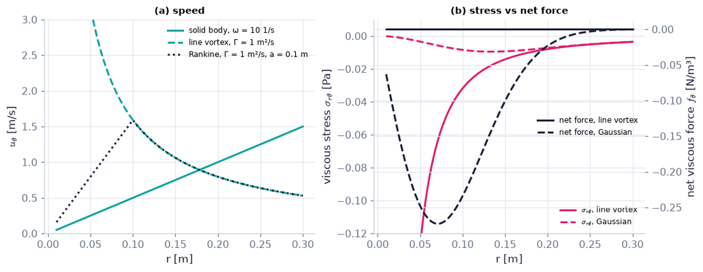

```python
r = np.linspace(0.01, 0.3, 120)                                      # radii [m]
fig, (a, b) = plt.subplots(1, 2, figsize=(10, 3.8))                  # speed profiles | stress and force
a.plot(r, ch05.solid_body_from_vorticity(r, 10.0)[0], color=COLORS["teal"], label="solid body, ω = 10 1/s")      # (5.1)
a.plot(r, ch05.line_vortex_gamma(r, 1.0)[0], color=COLORS["teal"], ls="--", label="line vortex, Γ = 1 m²/s")     # (5.2)
a.plot(r, vortices.rankine_vortex(r, 1.0, 0.1)[0], color=COLORS["ink"], ls=":", label="Rankine, Γ = 1 m²/s, a = 0.1 m")   # (3.28)
a.set_ylim(0, 3); a.set_xlabel("r [m]"); a.set_ylabel(r"$u_\theta$ [m/s]"); a.legend(fontsize=8); a.set_title("(a) speed", fontsize=10)
line = [ch05.vortex_stress_force("line", ri, mu=1e-3, Gamma=1.0) for ri in r]            # line vortex, water
gaus = [ch05.vortex_stress_force("gaussian", ri, mu=1e-3, Gamma=1.0, sigma=0.05) for ri in r]   # Gaussian, σ_c = 0.05 m
b.plot(r, [q["sigma_rtheta"] for q in line], color=COLORS["rose"], label=r"$\sigma_{r\theta}$, line vortex")        # stress [Pa]
b.plot(r, [q["sigma_rtheta"] for q in gaus], color=COLORS["rose"], ls="--", label=r"$\sigma_{r\theta}$, Gaussian")   # stress [Pa]
b.set_xlabel("r [m]"); b.set_ylabel(r"viscous stress $\sigma_{r\theta}$ [Pa]"); b.set_ylim(-0.12, 0.01)
b2 = b.twinx()                                                       # a second y-axis for the force per volume
b2.plot(r, [q["force_curl"] for q in line], color=COLORS["ink"], label="net force, line vortex")                     # zero
b2.plot(r, [q["force_curl"] for q in gaus], color=COLORS["ink"], ls="--", label="net force, Gaussian")              # nonzero
b2.set_ylabel(r"net viscous force $f_\theta$ [N/m³]")                # axis labels with units
b.legend(loc="lower right", fontsize=8); b2.legend(loc="center right", fontsize=8); b.set_title("(b) stress vs net force", fontsize=10)
savefig(fig, "ch05", "stress_vs_force"); plt.show()                  # save the PNG to outputs/ch05, then draw
```

**What you see.** Left: the solid body's speed grows linearly, the line vortex's falls as 1/r, the Rankine curve follows the first inside 0.1 m and the second outside. Right: the line vortex's stress (solid rose) is largest near the axis while its net force (solid black) is zero; the Gaussian (dashed) has both stress and force.

**How to read it.** Stress lives on one face of an element; force is the imbalance between faces. The line vortex is sheared everywhere but the faces balance; the Gaussian vortex has vorticity, so its faces do not balance and it decays.

**What would change if…** …μ doubled: every stress and force doubles; the zeros stay zeros.

#### 🎮 Interactive: Why is a spinning bucket a bowl and a drain a funnel?

**Why interactive rather than a static figure:** the bowl, the funnel, the Rankine tornado and the rotating cylinder share one radial balance; dragging the rotation, the circulation and the core size while a probe element shows its pressure, stress and net force makes "stress without force" something you watch rather than read.

**What to try:**

- Preset 'bucket 5 rad/s': read the rim–centre height, 12.7 mm, and the zero stress bar.
- Switch to the line vortex: the stress bar fills, the net-force bar stays at zero.
- Try 'tornado': the same formula in air, 608 Pa at the core edge.
- Open Derivation → D03 step 6 and watch the two faces of the probe element.

```python
show_viz("ch05", "vortex_pressure_funnel")   # full-width explainer; ⤢ Full screen for more room
```

🎮 Interactive 2/9 Why is a spinning bucket a bowl and a drain a funnel? Open alone ↗

[interactive chart not shown]

**What would change if…** …the fluid were spinning but the frame of reference turned with it? The water would be at rest in that frame, yet the free surface would still be a paraboloid: in the rotating frame there is no Coriolis force (nothing moves relative to the frame), and the centrifugal force folds into an effective gravity (Ch. 4 §4.7); the free surface is a surface of constant effective geopotential — the same reason the Earth's equator bulges. (Geostrophic balance, Ch. 13, is different: Coriolis against a pressure gradient, which needs motion relative to the frame.)

## 5.2 Kelvin's Circulation Theorem

**What is this section about?** Circulation round a loop that moves with the fluid is conserved — if the fluid is inviscid, barotropic, pushed only by conservative forces and watched from a non-rotating frame. The proof shows exactly which term wakes up when each hypothesis fails: those are the only ways vorticity can be created. The last of them, baroclinicity, has a simple mechanical picture: a torque.

> 🔁 **Recap — Barotropic fluid and the pressure function** (Ch. 4 §4.9). A fluid is barotropic when its density depends on pressure alone, ρ = ρ(p) (constant density, isothermal or isentropic gas). Then dp/ρ is the exact differential of the pressure function $\mathcal P(p)=\int_{p_o}^{p}dp'/\rho(p')$, as in $\frac1\rho\frac{\partial p}{\partial x_j}=\frac{\partial}{\partial x_j}\int_{p_o}^{p}\frac{dp'}{\rho(p')}$ *(4.67)* — just as $\mathbf g\cdot d\mathbf x=-d\Phi$ is exact for a conservative body force $\mathbf g=-\nabla\Phi$ *(4.18)*.

```python
print(bernoulli.pressure_function(2.0e5, 1.0e5, kind="isothermal", T=288.15))   # 𝒫 from 1 to 2 bar, isothermal air at 15 °C [J/kg]
print(287.058*288.15*np.log(2))                                       # the same by hand, R = 287.058 J/(kg K): R T ln(p/p_o) = 57 334 J/kg
```

```
57334.19689624893
57334.19770337048
```

> 🔁 **Tools from earlier chapters used here** (see `knowledge/primers.md`)
- **conservative body force and potential Φ (4.18)** — a force per unit mass that is the gradient of a potential, $\mathbf g=-\nabla\Phi$ (Φ = gz for gravity), does no net work round a closed loop (Ch. 4 P115).
- **rotating frame of reference** — a frame turning at Ω adds Coriolis and centrifugal forces to what an observer measures (Ch. 3 P103, Ch. 4 §4.7).

### 🧩 Kelvin's circulation theorem `C03`

*The question:* Put a ring of dye into water and let the flow stretch it seven times longer and wind it into a spiral. What has stayed exactly the same?

*In one line:* $\frac{D\Gamma}{Dt}=0$ *(5.8)*

#### The problem in plain words

Circulation measures the net swirl inside a loop. If we could prove it never changes for loops that move with the fluid, we would know that a fluid starting from rest (zero circulation everywhere) can never start swirling on its own — the basis of all "irrotational" flow in Ch. 6, of how wings get lift, and, on a rotating planet, of how cyclones spin up (C11). The proof also tells us precisely how swirl *can* be made.

#### The idea

```
Gamma(t) = loop integral of u.dx round a loop of dye    d/dt:  (acceleration along the loop) + (stretching of the loop)
                                                               = loop integral of forces.dx    = loop integral of d(u^2/2) = 0 always
forces: pressure  -grad(p)/rho  ->  -loop integral of dp/rho  = 0 if rho = rho(p)   (barotropic)
        gravity   -grad(Phi)    ->  -loop integral of dPhi    = 0 if Phi exists     (conservative)
        viscous                 ->   loop integral ...        = 0 if inviscid       (ideal fluid)
        Coriolis                ->   not 0 in a rotating frame                       (inertial frame needed)
```

> 🔁 **Tools from earlier chapters used here** (see `knowledge/primers.md`)
- **np.arctan2 and np.unwrap** — `np.arctan2(y, x)` is the polar angle of (x, y) in (−π, π]; `np.unwrap` removes its 2π jumps so the angle can be followed continuously (Ch. 2 P70).

> 📎 **Primer — closed-loop integral of an exact differential.** `P135` · If F is a single-valued function, going once round a closed loop brings F back to its starting value, so ∮dF = 0. It fails for a multi-valued "function" such as the polar angle θ, which grows by 2π on a loop round the origin. Kelvin's proof uses this twice: for ½u² and for the pressure function.

```python
s = np.linspace(0, 2*np.pi, 2001)                  # a loop: the unit circle, first point = last point
x, y = np.cos(s), np.sin(s)                        # its coordinates [m]
F = x**2*y + 3*x                                   # a single-valued F(x, y)
print(np.sum(np.diff(F)))                          # ∮dF = F(end) − F(start) = 0 (round-off)
theta = np.unwrap(np.arctan2(y, x))                # the polar angle, followed continuously
print(theta[-1] - theta[0])                        # 6.283185 = 2π: θ is not single-valued round the origin
```

```
0.0
6.283185307179586
```

> 📎 **Primer — periodic trapezoid rule on a closed loop.** `P136` · For a smooth closed loop parametrised by s ∈ [0, 1) with N equally spaced points, the plain average Σf(s_k)/N is extraordinarily accurate — the errors of the trapezoid rule cancel round a periodic curve (the error falls faster than any power of 1/N; for a trigonometric polynomial it is exact once N exceeds its highest frequency). We compute ∮u·dx this way, with dx/ds from an FFT derivative (numpy's `np.fft` splits the periodic coordinates into waves $e^{2\pi iks}$; differentiating a wave just multiplies it by 2πik — C07's primer says more).

```python
for N in (4, 8, 16):                                        # three loop resolutions
    s = np.arange(N)/N                                      # equally spaced tags, end point not repeated
    x, y = np.cos(2*np.pi*s), np.sin(2*np.pi*s)              # the unit circle [m]
    dxds, dyds = -2*np.pi*y, 2*np.pi*x                        # the tangent dx/ds [m]
    u, v = -y**3, x                                          # a velocity field [m/s]; Stokes gives ∮u·dx = ∫(1 + 3y²)dA = 7π/4
    print(N, np.mean(u*dxds + v*dyds) - 7*np.pi/4)           # error: 0.785 at N = 4 (aliasing), round-off from N = 8
```

```
4 0.7853981633974483
8 8.881784197001252e-16
16 0.0
```

> 🔁 **Tools from earlier chapters used here** (see `knowledge/primers.md`)
- **solve_ivp options (rtol, t_eval, DOP853)** — `solve_ivp(f, (t0, t1), y0, t_eval=…, rtol=…, method="DOP853")` integrates dy/dt = f(t, y) with an adaptive high-order method (Ch. 3 P94).

> 📎 **Primer — advecting many points in one solve_ivp call.** `P137` · To move a whole loop of N particles we give `solve_ivp` one long state vector (all x's, then all y's) and a right-hand side that reshapes it to (2, N), evaluates the velocity at every point at once (vectorised) and flattens it back. One adaptive integrator then moves the whole loop consistently.

```python
from scipy.integrate import solve_ivp                                # the adaptive ODE solver
X0 = np.array([[1.0, 0.0, -1.0], [0.0, 1.0, 0.0]])                   # three particles, shape (2, 3) [m]
rhs = lambda t, y: np.array([-y.reshape(2, -1)[1], y.reshape(2, -1)[0]]).ravel()   # solid body u = (−y, x), flattened [m/s]
sol = solve_ivp(rhs, (0, np.pi/2), X0.ravel(), rtol=1e-10)           # a quarter turn (1 rad/s for π/2 s)
print(sol.y[:, -1].reshape(2, -1).round(6))                          # each point turned by 90°: [[0, −1, 0], [1, 0, −1]]
```

```
[[-0. -1.  0.]
 [ 1. -0. -1.]]
```

*Gloss — material label.* Tag each particle of the loop once with a number s ∈ [0, 1); the tags travel with the particles, so the loop is always "the particles with tags 0…1" — fixed limits, even though the loop moves (Ch. 3 P89).

> 🔁 **Tools from earlier chapters used here** (see `knowledge/primers.md`) — needed in the derivation below
- **functions of time with parameters** — a quantity like X(s, t) is a function of time for each fixed tag s (Ch. 3 P89).
- **differentiation under the integral sign** — $\frac{d}{dt}\int_a^bF\,ds=\int_a^b\frac{\partial F}{\partial t}ds$ when the limits a, b are fixed (Ch. 3 P109).
- **material line element D(δx)/Dt = δu** — a short line of particles stretches and turns at the velocity difference across it (Ch. 3 P99).
- **multivariable first-order Taylor expansion** — $\mathbf u(\mathbf x+d\mathbf x)\approx\mathbf u(\mathbf x)+(d\mathbf x\cdot\nabla)\mathbf u$ for a short step (Ch. 3 P98).
- **chain rule for the kinetic energy u·du = d(½u²)** — $u_i\,du_i=d(\tfrac12u_iu_i)$ (Ch. 4 P128).

#### 🧮 Derivation — The rate of change of the circulation of a material loop: (5.9) `D04` (Eq. 5.9)

**What we want to show.** Differentiate the circulation of a loop that moves with the fluid, and show that its stretching and turning contribute nothing — only the acceleration of the fluid along the loop counts.

**Assumptions.** C is material (step 1); u smooth and single-valued (steps 3, 8).

**The plan.**

1. Label the loop's particles so the integral has fixed limits.
2. Differentiate under the integral with the product rule.
3. Show the change of a loop element is the velocity difference du.
4. Show ∮u·du vanishes.

**Tools we use** (each explained before this point): Material label (gloss) and functions with parameters (ch03 P89) · differentiation under the integral sign (ch03 P109, reminder) · material line element D(δx)/Dt = δu (ch03 P99) · closed-loop integral of an exact differential (primer in C03).

**We start from**

$$ \Gamma(t)=\oint_{C(t)}u_i\,dx_i\ \text{(3.18) with C(t) a material loop} $$

*In words:* add up the velocity along a loop of dye that is carried by the flow.

**Step 1 of 8 — Label the loop by fixed particle tags.**

$$ \mathbf x=\mathbf X(s,t),\quad 0\le s<1,\quad \mathbf X(0,t)=\mathbf X(1,t) $$

- *Why we can do this:* The book skips this: each particle keeps its tag s while it moves, so the loop's parameter range [0, 1) never changes even though the loop does (material label gloss).
- *In words:* Number the dye particles once; the numbers travel with them.

**Step 2 of 8 — Write Γ with fixed limits.**

$$ \Gamma(t)=\int_0^1u_i\big(\mathbf X(s,t),t\big)\,\frac{\partial X_i}{\partial s}\,ds $$

- *Why we can do this:* Along the loop dx_i = (∂X_i/∂s)ds (chain rule on a parametrised curve, ch03 P92). Now the limits no longer depend on t.
- *In words:* The circulation is an ordinary integral over the particle tags.

**Step 3 of 8 — Differentiate under the integral sign.**

$$ \frac{d\Gamma}{dt}=\int_0^1\Big[\frac{Du_i}{Dt}\frac{\partial X_i}{\partial s}+u_i\frac{\partial}{\partial t}\Big(\frac{\partial X_i}{\partial s}\Big)\Big]ds $$

- *Why we can do this:* Fixed limits allow d/dt inside (P109); product rule on the integrand. At fixed s the time derivative of u(X(s, t), t) follows one particle, so it is Du_i/Dt (3.5), $\frac{DF}{Dt}=\frac{\partial F}{\partial t}+\mathbf u\cdot\nabla F$.
- *In words:* Γ changes because the fluid accelerates and because the loop's elements change.

**Step 4 of 8 — Return to loop notation.**

$$ \frac{D\Gamma}{Dt}=\oint_C\frac{Du_i}{Dt}dx_i+\oint_Cu_i\frac{D}{Dt}(dx_i) $$

- *Why we can do this:* (∂X_i/∂s)ds = dx_i, and ∂/∂t at fixed tag is D/Dt of the element. This is (5.9), $\frac{D\Gamma}{Dt}=\oint_C\frac{Du_i}{Dt}dx_i+\oint_Cu_i\frac{D}{Dt}(dx_i)$ — the line above.
- *In words:* Acceleration term plus element-change term.

**Step 5 of 8 — Follow both ends of one element.**

$$ \mathbf u+d\mathbf u=\frac{D}{Dt}(\mathbf x+d\mathbf x)=\frac{D\mathbf x}{Dt}+\frac{D}{Dt}(d\mathbf x) $$

- *Why we can do this:* The points x and x + dx are both particles (Fig. 5.4), so each moves at the local velocity: u at x, u + du at x + dx (first-order Taylor, ch03 P98).
- *In words:* The element's tail and head each ride with the flow.

**Step 6 of 8 — Subtract the tail's velocity.**

$$ \frac{D}{Dt}(dx_i)=du_i $$

- *Why we can do this:* Dx/Dt = u, so the remainder is du: a material element grows at the velocity difference across it (ch03 P99).
- *In words:* An element stretches and turns at the rate its two ends move apart.

**Step 7 of 8 — Rewrite the second integral.**

$$ \oint_Cu_i\frac{D}{Dt}(dx_i)=\oint_Cu_i\,du_i=\oint_Cd\big(\tfrac12u_iu_i\big) $$

- *Why we can do this:* u_i du_i = d(½u_iu_i) (chain rule for the kinetic energy, ch04 P128). We want an exact differential.
- *In words:* The element-change term is the change of ½u² round the loop.

**Step 8 of 8 — Close the loop: exact differential vanishes.**

$$ \frac{D\Gamma}{Dt}=\oint_C\frac{Du_i}{Dt}dx_i $$

- *Why we can do this:* ½u² is single-valued, so going once round the loop brings it back to its start: ∮d(½u²) = 0 (primer).
- *In words:* However the loop is stretched or tangled, only the fluid's acceleration along it can change Γ.

**Result**

$$ \begin{array}{l}\frac{D\Gamma}{Dt}=\oint_C\frac{Du_i}{Dt}dx_i\ \text{, from (5.9)}\ \frac{D\Gamma}{Dt}=\oint_C\frac{Du_i}{Dt}dx_i+\oint_Cu_i\frac{D}{Dt}(dx_i)\ \text{with the second term} \\ \text{zero}\end{array} $$

*In words:* a loop's circulation changes only if the fluid on it is accelerated along it.

**What it means.** Circulation is a property the fluid carries, not the loop's shape: stretching a loop seven-fold changes nothing by itself. Everything that follows (Kelvin, Helmholtz, Bjerknes) is about the acceleration term.

**Check it.** Units: m²/s² ✓. Numerically (the code cell after the tiny example of this block: `kelvin_rate_terms` on the cellular flow): contour term ≈ −3e-14, acceleration term ≈ 4e-13, and dΓ/dt from central differences of Γ(t) is ≈ 0 as well ✓. A fixed (non-material) loop fails the argument — step 1 needs the particles.

> ⚠️ **Common confusion (traps in `D04`):** Moving d/dt inside a loop integral whose limits move (only fixed tags allow it). Using a multi-valued function (the polar angle θ round the origin) in step 8 — ∮dθ = 2π.

📝 **Note.** **Two causes of change** `N10` — D04's step 4 is (5.9): the fluid accelerating along the loop, and the loop's elements changing.

$$ \frac{D\Gamma}{Dt}=\oint_C\frac{Du_i}{Dt}dx_i+\oint_Cu_i\frac{D}{Dt}(dx_i) \qquad \text{(5.9)} $$

📝 **Note.** **The element's rate is the velocity difference** `N11` — (Fig. 5.4): $\mathbf u+d\mathbf u=\frac{D}{Dt}(\mathbf x+d\mathbf x)$, so $D(d\mathbf x)/Dt=d\mathbf u$, and the second integral of (5.9), $\frac{D\Gamma}{Dt}=\oint_C\frac{Du_i}{Dt}dx_i+\oint_Cu_i\frac{D}{Dt}(dx_i)$ is $\oint_Cu_i\,du_i=\oint_Cd(\tfrac12u_i^2)=0$.

$$ \frac{D}{Dt}(d\mathbf x)=d\mathbf u $$

> 🔁 **Tools from earlier chapters used here** (see `knowledge/primers.md`) — needed in the derivation below
- **multivariable chain rule along a path** — the change of p along a small step is $dp=\nabla p\cdot d\mathbf x$ (Ch. 3 P91).

#### 🧮 Derivation — Momentum in (5.9): (5.10) → (5.11) → Kelvin's theorem (5.8), and the three sources of vorticity `D05` (Eq. 5.11)

**What we want to show.** Put the momentum equation into $\frac{D\Gamma}{Dt}=\oint_C\frac{Du_i}{Dt}dx_i$ and find exactly which forces can change a material loop's circulation — then list the hypotheses under which none can.

**Assumptions.** Inertial frame (step 1); conservative body force (step 5); barotropic (step 6); inviscid (step 8).

**The plan.**

1. Replace Du/Dt by the forces per unit mass.
2. Turn the pressure and body-force terms into loop integrals of differentials.
3. Show they vanish for barotropic, conservative flow.
4. Read off what is left.

**Tools we use** (each explained before this point): Cauchy's equation with τ = −pδ + σ (Ch. 4 §4.4–4.5) · conservative force and potential g = −∇Φ (4.18), $\mathbf g=-\nabla\Phi$ (ch04 P115, reminder) · barotropic pressure function (R09, (4.67)) · closed-loop integral of an exact differential (primer in C03) · Stokes' theorem (2.34), $\int_A(\nabla\times\mathbf u)\cdot\mathbf n\,dA=\oint_C\mathbf u\cdot d\mathbf x$ (Ch. 2 §2.13).

**We start from**

$$ \frac{D\Gamma}{Dt}=\oint_C\frac{Du_i}{Dt}dx_i\ \text{(D04)} $$

*In words:* only the acceleration along the loop matters.

**Step 1 of 9 — Substitute the momentum equation.**

$$ \frac{Du_i}{Dt}=-\frac1\rho\frac{\partial p}{\partial x_i}+g_i+\frac1\rho\frac{\partial\sigma_{ij}}{\partial x_j} $$

- *Why we can do this:* Cauchy (4.24), $\rho\frac{Du_j}{Dt}=\rho g_j+\frac{\partial\tau_{ij}}{\partial x_i}$ with the stress split τ = −pδ + σ (4.59), $\sigma_{ij}=\mu\Big(\frac{\partial u_i}{\partial x_j}+\frac{\partial u_j}{\partial x_i}\Big)+\big(\mu_v-\tfrac23\mu\big)\frac{\partial u_m}{\partial x_m}\delta_{ij}$, divided by ρ, in an inertial frame. The book differentiates σ on its second index; harmless because σ is symmetric.
- *In words:* Acceleration = pressure push + body force + viscous force, each per kilogram.

**Step 2 of 9 — Split into three loop integrals.**

$$ \oint_C\frac{Du_i}{Dt}dx_i=\oint_C\Big(-\frac1\rho\frac{\partial p}{\partial x_i}+g_i+\frac1\rho\frac{\partial\sigma_{ij}}{\partial x_j}\Big)dx_i $$

- *Why we can do this:* Linearity of the integral. We examine each force separately.
- *In words:* Three forces, three contributions.

**Step 3 of 9 — Write the pressure term as a differential.**

$$ \frac{\partial p}{\partial x_i}dx_i=dp\ \Rightarrow\ -\oint_C\frac1\rho\,dp $$

- *Why we can do this:* The change of p along a small step dx is ∇p·dx (chain rule along a path, ch03 P91).
- *In words:* Along the loop, pressure changes by dp per step.

**Step 4 of 9 — Write gravity through its potential.**

$$ g_i\,dx_i=-\frac{\partial\Phi}{\partial x_i}dx_i=-d\Phi $$

- *Why we can do this:* g = −∇Φ (4.18), $\mathbf g=-\nabla\Phi$ for a conservative body force (Φ = gz). With steps 1–3 this is (5.10): $\oint_C\frac{Du_i}{Dt}dx_i=-\oint_C\frac1\rho dp-\oint_Cd\Phi+\oint_C\big(\frac1\rho\frac{\partial\sigma_{ij}}{\partial x_j}\big)dx_i$.
- *In words:* Gravity's work along a step is the drop in potential.

**Step 5 of 9 — Close the loop on the body force.**

$$ \oint_Cd\Phi=0 $$

- *Why we can do this:* Φ is single-valued, so an exact differential integrates to zero round a closed loop (primer). A non-conservative force (Coriolis) has no such Φ.
- *In words:* Gravity does no net work round a loop.

**Step 6 of 9 — Close the loop on the pressure term.**

$$ \rho=\rho(p)\ \Rightarrow\ \frac{dp}{\rho}=d\mathcal P\ \Rightarrow\ \oint_C\frac{dp}{\rho}=0 $$

- *Why we can do this:* Barotropic: the pressure function 𝒫(p) = ∫dp/ρ(p) (4.67), $\frac1\rho\frac{\partial p}{\partial x_j}=\frac{\partial}{\partial x_j}\int_{p_o}^{p}\frac{dp'}{\rho(p')}$ makes dp/ρ exact. The book's reason, "ρ and p are single valued", is not enough: in a baroclinic field both are single-valued and ∮dp/ρ ≠ 0.
- *In words:* Only if density is tied to pressure does pressure do no net work.

**Step 7 of 9 — Keep what survives.**

$$ \frac{D\Gamma}{Dt}=\oint_C\Big(\frac1\rho\frac{\partial\sigma_{ij}}{\partial x_j}\Big)dx_i $$

- *Why we can do this:* Steps 5–6 removed two of the three integrals of (5.10), $\oint_C\frac{Du_i}{Dt}dx_i=-\oint_C\frac1\rho dp-\oint_Cd\Phi+\oint_C\Big(\frac1\rho\frac{\partial\sigma_{ij}}{\partial x_j}\Big)dx_i$. This is (5.11), $\frac{D\Gamma}{Dt}=\oint_C\Big(\frac1\rho\frac{\partial\sigma_{ij}}{\partial x_j}\Big)dx_i$ — the line above.
- *In words:* Only the net viscous force along the loop is left.

**Step 8 of 9 — Let the fluid be inviscid.**

$$ \frac{D\Gamma}{Dt}=0 $$

- *Why we can do this:* σ = 0 when μ = μ_v = 0 — or when the net viscous force vanishes all along C. This is Kelvin's theorem (5.8), $\frac{D\Gamma}{Dt}=0$.
- *In words:* In an ideal, barotropic fluid with conservative forces, a material loop keeps its circulation.

**Step 9 of 9 — Read off every way to break it.**

$$ \frac{D\Gamma}{Dt}\neq0\ \Leftarrow\ \oint\mathbf g\cdot d\mathbf x\ne0,\ \oint\frac{dp}{\rho}\ne0,\ \oint\frac{1}{\rho}\frac{\partial\sigma_{ij}}{\partial x_j}dx_i\ne0 $$

- *Why we can do this:* Undo one assumption at a time: non-conservative forces (Coriolis in a rotating frame), baroclinicity (by Stokes (2.34), $\int_A(\nabla\times\mathbf u)\cdot\mathbf n\,dA=\oint_C\mathbf u\cdot d\mathbf x$, −∮dp/ρ = −∮(∇p/ρ)·dx = ∫(∇ρ×∇p/ρ²)·n dA, because the curl of −∇p/ρ is ∇ρ×∇p/ρ² by the quotient rule ∇(1/ρ) = −∇ρ/ρ² — written out in C09, §5.6; the code cell after note N14 checks it), net viscous force. "C in irrotational fluid" kills the last only if incompressible, constant μ.
- *In words:* Three sources of vorticity, one per broken hypothesis.

**Result**

$$ \begin{array}{l}\text{(5.10)}\ \oint_C\frac{Du_i}{Dt}dx_i=-\oint_C\frac1\rho dp-\oint_Cd\Phi+\oint_C\big(\frac1\rho\frac{\partial\sigma_{ij}}{\partial x_j}\big)dx_i\ \text{→ (5.11)} \\ \frac{D\Gamma}{Dt}=\oint_C\big(\frac1\rho\frac{\partial\sigma_{ij}}{\partial x_j}\big)dx_i\ \text{→ (5.8)}\ D\Gamma/Dt=0\end{array} $$

*In words:* in an inviscid, barotropic fluid with conservative body forces, seen from an inertial frame, circulation round a material loop is conserved.

**What it means.** Circulation — hence vorticity (Stokes) — can be made or destroyed only by viscosity, baroclinicity or non-conservative forces; flow that starts irrotational in an ideal fluid stays irrotational (Ch. 6). The rotating frame adds the Coriolis term, which C11 turns into (5.33), $\frac{D\Gamma_a}{Dt}=0,\ \Gamma_a\equiv\int_A(\boldsymbol\omega+2\boldsymbol\Omega)\cdot\mathbf n\,dA=\Gamma+2\int_A\boldsymbol\Omega\cdot\mathbf n\,dA$.

**Check it.** Units: every term m²/s² ✓. Lamb–Oseen (the code cell after the tiny example of this block; Γ₀ = 0.01 m²/s, ν = 1e-6 m²/s, r = 5 mm, t = 10 s): the (5.11), $\frac{D\Gamma}{Dt}=\oint_C\Big(\frac1\rho\frac{\partial\sigma_{ij}}{\partial x_j}\Big)dx_i$ integral equals ∂Γ/∂t = −3.345e-4 m²/s² ✓. Baroclinic lock-exchange field (the code cell after note N14): −∮dp/ρ round the 0.2 m square equals ∫(∇ρ×∇p/ρ²)·n dA over it to the digits printed there ✓.

> ⚠️ **Common confusion (traps in `D05`):** Accepting "single-valued" as the reason in step 6. Forgetting that C must be material. Thinking the viscous term vanishes whenever the fluid near C is irrotational (compressible flow keeps a ∇(∇·u) force).

📝 **Note.** **The forces round the loop** `N12` — D05's step 4 is (5.10):

$$ \oint_C\frac{Du_i}{Dt}dx_i=-\oint_C\frac1\rho dp-\oint_Cd\Phi+\oint_C\Big(\frac1\rho\frac{\partial\sigma_{ij}}{\partial x_j}\Big)dx_i \qquad \text{(5.10)} $$

📝 **Note.** **What survives** `N13` — is (5.11): Kelvin holds if the fluid is inviscid or the net viscous force vanishes along C. **Number**, the Lamb–Oseen vortex (Γ₀ = 0.01 m²/s, ν = 10⁻⁶ m²/s) on the circle r = 5 mm at t = 10 s: $\Gamma=\Gamma_0(1-e^{-r^2/4\nu t})$ = 0.00465 m²/s and falling at 3.35×10⁻⁴ m²/s² — exactly the (5.11) integral. ⚠️ The book adds "this occurs when C lies entirely in irrotational fluid" — true for incompressible, constant-μ flow, where the viscous force is $\mu\nabla^2\mathbf u=-\mu\nabla\times\boldsymbol\omega$ (4.40); a compressible flow keeps a $\nabla(\nabla\cdot\mathbf u)$ force.

$$ \frac{D\Gamma}{Dt}=\oint_C\Big(\frac1\rho\frac{\partial\sigma_{ij}}{\partial x_j}\Big)dx_i \qquad \text{(5.11)} $$

#### ✏️ Tiny example: circulation that survives a stretching — and one that leaks away

1. **Cellular flow** $\psi=\sin x\sin y$ ($u=\sin x\cos y$, $v=-\cos x\sin y$, in m and m/s): a steady inviscid flow whose vorticity $\omega=2\sin x\sin y$ is constant on streamlines. A circle of radius 0.5 m round (π/2, 0.9 m) has $\Gamma(0)=\iint2\sin x\sin y\,dA$ = 1.155 m²/s. Kelvin predicts Γ(t) = 1.155 m²/s forever.
2. **Lamb–Oseen** (viscous): the circle r = 5 mm with Γ₀ = 0.01 m²/s, ν = 10⁻⁶ m²/s at t = 10 s: $r^2/4\nu t=25\times10^{-6}/(4\times10^{-5})$ = 0.625; Γ = 0.01(1 − e^{−0.625}) = 0.01 × 0.4647 = 0.00465 m²/s; at t = 20 s: $r^2/4\nu t$ = 0.3125, Γ = 0.00268 m²/s — the vorticity diffuses out through the loop.

```python
sc = ch05.kelvin_scenario("cellular")                                # the cellular flow and its initial circle (2048 labelled points)
t = np.linspace(0, sc["t_end"], 7)                                   # 0 … 37.7 s: six turnover times
G = ch05.material_circulation(sc["u"], sc["pts0"], t)                # Γ(t) of the material loop (one solve_ivp call) [m²/s]
L = [ch05.loop_length(Pk) for Pk in ch05.material_loop(sc["u"], sc["pts0"], t)]   # the loop's length at those times [m]
print("Γ(t) =", [f"{g:.6f}" for g in G], " spread", f"{np.ptp(G):.1e} m²/s")   # 1.155130 every time
print("length(t) =", np.round(L, 3))                                 # 3.142 m → 21.0 m: stretched ×6.7
print(ch05.kelvin_rate_terms(sc["u"], sc["pts0"], 0.0))              # the two terms of (5.9) and their sum [m²/s²]
Gc = ch05.material_circulation(sc["u"], sc["pts0"], [0.0, 0.01, 0.02])   # Γ at three close times
print(f"dΓ/dt by central difference: {(Gc[2] - Gc[0])/0.02:.1e} m²/s²")    # ≈ 0, the same as the acceleration term
print(ch05.lamb_oseen_circulation(0.005, 10.0, 0.01, 1e-6))          # Lamb–Oseen (Γ(r, t), ∂Γ/∂t) at r = 5 mm, t = 10 s
print(ch05.lamb_oseen_viscous_loop_integral(0.005, 10.0, 0.01, 1e-6))   # the (5.11) loop integral of the viscous force [m²/s²]
print(ch05.kelvin_scenario_circulation("rotating", 5.0))              # a loop in a rotating frame: Γ has grown to 1.99 m²/s (C11)
```

```
Γ(t) = ['1.155130', '1.155130', '1.155130', '1.155130', '1.155130', '1.155130', '1.155130']  spread 3.0e-13 m²/s
length(t) = [ 3.142  4.652  7.536 10.921 14.222 17.469 20.997]
KelvinRate(acceleration=4.119898866505878e-13, contour=-2.6173507805538065e-14, total=3.858163788450497e-13)
dΓ/dt by central difference: 0.0e+00 m²/s²
(0.004647385714810099, -0.0003345383928243689)
-0.00033453832096407476
1.9858653037988714
```

**What does the code above do?**

1. The scenario's velocity and its initial loop (2048 labelled points).
2. The loop advected by `solve_ivp` in one call (primer P137) and its circulation by the periodic trapezoid rule (P136): Γ = 1.155130 m²/s at every time (spread 3×10⁻¹³) while the length grows from 3.142 m to 20.997 m (×6.7).
3. The two terms of (5.9), $\frac{D\Gamma}{Dt}=\oint_C\frac{Du_i}{Dt}dx_i+\oint_Cu_i\frac{D}{Dt}(dx_i)$: the acceleration term ≈ 4×10⁻¹³ and the contour term ≈ −3×10⁻¹⁴ m²/s² — and dΓ/dt from central differences of Γ(t) is ≈ 0 as well.
4. Lamb–Oseen: Γ = 0.004647 m²/s falling at −3.34538×10⁻⁴ m²/s², and the viscous loop integral of (5.11), $\frac{D\Gamma}{Dt}=\oint_C\Big(\frac1\rho\frac{\partial\sigma_{ij}}{\partial x_j}\Big)dx_i$ is the same number.
5. In a rotating frame the relative circulation grows (to 1.99 m²/s after 5 s here) — C11 explains why.

> 🔁 **Tools from earlier chapters used here** (see `knowledge/primers.md`)
- **RK4 by hand** — four velocity evaluations per step combined with weights 1, 2, 2, 1 — fourth-order accurate (Ch. 3 P95).

**From scratch — our own particles and our own loop sum:** RK4 by hand on the labelled points, then the periodic trapezoid rule with an FFT tangent.

```python
u = sc["u"]                                                          # the cellular flow u(x, t) [m/s]
P = sc["pts0"][:, ::(1 if not FAST else 2)].copy()                   # the labelled loop points (every 2nd with FAST) [m]
dt = 0.01                                                            # RK4 step [s]
for k in range(600):                                                 # 600 steps → t = 6 s
    k1 = u(P, 0); k2 = u(P + 0.5*dt*k1, 0); k3 = u(P + 0.5*dt*k2, 0); k4 = u(P + dt*k3, 0)   # the four RK4 slopes (steady flow)
    P = P + dt/6*(k1 + 2*k2 + 2*k3 + k4)                             # advance every point together
N = P.shape[1]                                                       # number of points
kw = np.fft.fftfreq(N, 1.0/N)                                        # integer wavenumbers of the periodic tag s ∈ [0, 1)
dPds = np.real(np.fft.ifft(2j*np.pi*kw*np.fft.fft(P, axis=1), axis=1))   # dx/ds by FFT (each wave × 2πik)
Gamma = np.mean(np.sum(u(P, 0)*dPds, axis=0))                        # ∮u·dx = mean of u·dx/ds over the tags [m²/s]
print(f"ours {Gamma:.10f}, library {ch05.material_circulation(sc['u'], sc['pts0'], [0, 6.0])[-1]:.10f} m²/s")
assert np.allclose(Gamma, ch05.material_circulation(sc["u"], sc["pts0"], [0, 6.0])[-1], rtol=1e-7)   # same numbers
assert abs(Gamma - 1.155130) < 1e-6                                  # and the circulation did not move
```

```
ours 1.1551296522, library 1.1551296522 m²/s
```

> 🔁 **Tools from earlier chapters used here** (see `knowledge/primers.md`)
- **animate and show_animation** — `animate(update, frames, fig)` builds a movie from an update function; `show_animation` plays it (Ch. 1 P16).

**The loop and its circulation in motion (Fig. 5.4 analogue, note `N48`).** Left: the cellular flow (grey shading = its stream function, whose level curves are the streamlines) and the material loop (teal), with one element dx (black arrow) and the velocities u (teal) and u + du (orange) at its ends. Right: Γ(t)/Γ(0) of this loop (teal) and of the viscous Lamb–Oseen circle of the tiny example (rose).

```python
nf = 30 if not FAST else 16                                          # number of frames
tf = np.linspace(0, sc["t_end"], nf)                                 # frame times 0 … 37.7 s
Ploop = ch05.material_loop(sc["u"], sc["pts0"], tf)                  # the loop at every frame, shape (nf, 2, 2048) [m]
Gf = np.array([ch05.loop_circulation(sc["u"], Pk) for Pk in Ploop])  # its circulation [m²/s]
GLO = ch05.lamb_oseen_circulation(0.005, tf + 10.0, 0.01, 1e-6)[0]   # Lamb–Oseen circle r = 5 mm, vortex 10 s old at t = 0
xg = np.linspace(0, np.pi, 120)                                      # grid for the streamlines [m]
XG, YG = np.meshgrid(xg, xg)                                         # (x, y) grid
with plt.rc_context(ANIM_RC):                                         # light settings for fast frames
    fig, (a, b) = plt.subplots(1, 2, figsize=(9.5, 4.0), dpi=80, gridspec_kw=dict(width_ratios=[1.1, 1]))
fig.subplots_adjust(left=0.07, right=0.98, bottom=0.13, top=0.9, wspace=0.25)   # fixed margins (no layout engine)
a.imshow(np.sin(XG)*np.sin(YG), origin="lower", extent=(0, np.pi, 0, np.pi), cmap="Greys", alpha=0.35)   # grey shading = ψ = sin x sin y: streamlines are its level curves
(loopline,) = a.plot([], [], color=COLORS["teal"], lw=1.4)           # the material loop
q = a.quiver([0, 0, 0], [0, 0, 0], [0, 0, 0], [0, 0, 0], color=[COLORS["ink"], COLORS["teal"], COLORS["orange"]],
             angles="xy", scale_units="xy", scale=1, width=0.006)    # dx, u, u + du arrows
a.set_xlim(0, np.pi); a.set_ylim(0, np.pi); a.set_aspect("equal"); a.set_xlabel("x [m]"); a.set_ylabel("y [m]")
b.plot(tf, GLO/GLO[0], color=COLORS["rose"], lw=2, label="Lamb–Oseen circle (viscous)")        # the viscous leak
b.axhline(1.0, color=COLORS["muted"], ls="--", lw=1, label="Γ(0)")    # ghost of the start value
(gline,) = b.plot([], [], color=COLORS["teal"], lw=2.5, label="cellular loop (inviscid)")      # Kelvin
b.set_xlim(0, tf[-1]); b.set_ylim(0, 1.15); b.set_xlabel("t [s]"); b.set_ylabel("Γ(t)/Γ(0) [–]"); b.legend(fontsize=8, loc="lower left")
txt = a.set_title("")                                                # running readout
k0, k1 = 0, 40                                                       # the element's two particles (tags 0 and 40/2048)


def update(i):                                                       # draw frame i
    Pk = Ploop[i]                                                    # loop points at this time
    loopline.set_data(np.r_[Pk[0], Pk[0, :1]], np.r_[Pk[1], Pk[1, :1]])   # close the loop for drawing
    x0, x1 = Pk[:, k0], Pk[:, k1]                                    # the element's tail and head
    u0, u1 = sc["u"](x0, 0.0), sc["u"](x1, 0.0)                      # velocities there [m/s]
    q.set_offsets(np.array([x0, x0, x1]))                            # arrow tails
    q.set_UVC([x1[0] - x0[0], 0.3*u0[0], 0.3*u1[0]], [x1[1] - x0[1], 0.3*u0[1], 0.3*u1[1]])   # dx, u, u + du (scaled)
    gline.set_data(tf[:i + 1], Gf[:i + 1]/Gf[0])                     # Γ(t)/Γ(0) so far
    txt.set_text(f"t = {tf[i]:.1f} s, loop length {ch05.loop_length(Pk):.1f} m, Γ = {Gf[i]:.6f} m²/s")
    return loopline, q, gline


with plt.rc_context(ANIM_RC):                                         # render the frames with the light settings
    show_animation(animate(update, frames=nf, fig=fig, interval=150), player="video")   # smooth movie
```

[video not shown]

**What you see.** The loop winds into a long thin spiral round the centre of the cell; its teal curve on the right does not move off 1, while the rose curve of the viscous vortex falls to about a quarter.

**How to read it.** However long the loop gets, the acceleration along it integrates to zero (D05): Kelvin's $D\Gamma/Dt=0$ (5.8). The rose curve is the viscous leak of (5.11), $\frac{D\Gamma}{Dt}=\oint_C\Big(\frac1\rho\frac{\partial\sigma_{ij}}{\partial x_j}\Big)dx_i$.

**What would change if…** …ν switched on in the cellular flow: the teal curve would fall as $e^{-2\nu t}$, whatever the loop's shape — for this flow $\nabla^2\mathbf u=-2\mathbf u$, so the viscous term of (5.11) is $\nu\oint\nabla^2\mathbf u\cdot d\mathbf x=-2\nu\Gamma$. The cell below checks it with two loops of different shape.

**Checking the what-if.** With viscosity, $\mathbf u=e^{-2\nu t}(\sin x\cos y,\ -\cos x\sin y)$ is an exact Navier–Stokes solution (the Taylor–Green vortex, the viscous version of our cellular flow: $\nabla^2\mathbf u=-2\mathbf u$ and the pressure balances the rest). For any material loop, (5.11), $\frac{D\Gamma}{Dt}=\oint_C\Big(\frac1\rho\frac{\partial\sigma_{ij}}{\partial x_j}\Big)dx_i$ then gives $D\Gamma/Dt=\nu\oint\nabla^2\mathbf u\cdot d\mathbf x=-2\nu\Gamma$, so $\Gamma(t)=\Gamma(0)e^{-2\nu t}$ — the same decay for a circle and for a square.

```python
nu_c = 0.01                                                          # a large viscosity so the decay shows in 37.7 s [m²/s]
u_v = lambda x, t: np.exp(-2*nu_c*t)*ch05.cellular_flow(x)           # the decaying cellular (Taylor–Green) flow [m/s]
tv = np.array([0.0, 10.0, 20.0, sc["t_end"]])                        # four times [s]
loops = {"circle": sc["pts0"], "square": ch05.square_loop_points((np.pi/2, 0.9), 0.8, n=1024)}   # two loop shapes (2, N) [m]
for name, P0 in loops.items():
    Gv = ch05.material_circulation(u_v, P0, tv)                      # Γ(t) of the material loop [m²/s]
    print(f"{name:6s} Γ(t)/Γ(0) = {np.round(Gv/Gv[0], 6)}   e^(−2νt) = {np.round(np.exp(-2*nu_c*tv), 6)}")
```

```
circle Γ(t)/Γ(0) = [1.     0.8187 0.6703 0.4705]   e^(−2νt) = [1.     0.8187 0.6703 0.4705]
square Γ(t)/Γ(0) = [1.     0.8187 0.6703 0.4705]   e^(−2νt) = [1.     0.8187 0.6703 0.4705]
```

**What does the code above do?**

Both loops — a circle and a square, advected by the decaying flow — lose circulation at exactly the rate $e^{-2\nu t}$ (0.8187, 0.6703, 0.4705 at 10, 20 and 37.7 s for ν = 0.01 m²/s): the viscous leak of (5.11), $\frac{D\Gamma}{Dt}=\oint_C\Big(\frac1\rho\frac{\partial\sigma_{ij}}{\partial x_j}\Big)dx_i$ depends on the flow, not on the loop's shape.

📝 **Note.** **Three ways to make or destroy vorticity** `N14` — one per broken hypothesis.

| source | term of (5.10), $\oint_C\frac{Du_i}{Dt}dx_i=-\oint_C\frac1\rho dp-\oint_Cd\Phi+\oint_C\Big(\frac1\rho\frac{\partial\sigma_{ij}}{\partial x_j}\Big)dx_i$ | example | number |
| --- | --- | --- | --- |
| non-conservative body force | $\oint\mathbf g\cdot d\mathbf x\ne0$ (Coriolis) | a drain vortex in a tank on the rotating Earth | the rotating scenario gains 1.99 m²/s in 5 s |
| non-barotropic (baroclinic) | $-\oint dp/\rho\ne0$ | lock exchange (C04), sea breeze | the lock-exchange square: 0.0467 m²/s² (cell below) |
| net viscous force | $\oint(1/\rho)\partial\sigma_{ij}/\partial x_j\,dx_i\ne0$ | boundary layers at walls (Ch. 9) | −3.35×10⁻⁴ m²/s² (Lamb–Oseen) |

The baroclinic number is checked two ways below: the loop integral $-\oint dp/\rho$ round a 0.2 m square straddling the lock-exchange interface at the first instant, and — by Stokes — the area integral of the baroclinic source $\frac1{\rho^2}\nabla\rho\times\nabla p$ over the square.

*Gloss — Gauss–Legendre nodes (used in the next cell).* `itg.gauss_legendre_nodes(lo, hi, n)` returns n points and n weights on [lo, hi] chosen so that Σ wᵢ f(xᵢ) is exact for every polynomial f of degree up to 2n − 1; for an area we take all pairs of nodes and multiply their weights. Primer P143 in C07 shows it with a 4-node demo.

```python
bsc = ch05.kelvin_scenario("baroclinic")                             # fluid at rest in the lock-exchange field, square loop 0.2 m
rate = ch05.kelvin_scenario_rate("baroclinic")                       # the terms of (5.9)/(5.10) at t = 0 [m²/s²]
print({k: round(v, 10) for k, v in rate.items()})                    # only "pressure" (= −∮dp/ρ) is nonzero
lx = ch05.lock_exchange_fields(1000.0, 1025.0, 0.1)                  # the same density and hydrostatic pressure as functions
(x0, y0), (x1, y1) = bsc["pts0"].min(axis=1), bsc["pts0"].max(axis=1)   # the square's corners [m]
xs, wx = itg.gauss_legendre_nodes(x0, x1, 40); ys, wy = itg.gauss_legendre_nodes(y0, y1, 40)   # 40 × 40 Gauss nodes
XS, YS = np.meshgrid(xs, ys, indexing="ij")                          # all nodes
gr, gp, rr = lx["grad_rho"](XS, YS), lx["grad_p"](XS, YS), lx["rho"](XS, YS)   # ∇ρ, ∇p, ρ at the nodes
source = (gr[0]*gp[1] - gr[1]*gp[0])/rr**2                           # (∇ρ × ∇p)_z/ρ² [1/s²]
print(f"loop: {rate['pressure']:.12f}   area (Stokes): {np.sum(source*wx[:, None]*wy[None, :]):.12f} m²/s²")
```

```
{'acceleration': 0.0467083967, 'contour': 0.0, 'pressure': 0.0467083967, 'body': 0.0, 'viscous': 0.0, 'coriolis': 0.0, 'total': 0.0467083967}
loop: 0.046708396673   area (Stokes): 0.046708396673 m²/s²
```

**What does the code above do?**

Only the pressure term survives at the first instant (the fluid is at rest: no viscous force, gravity is conservative, the frame is inertial): $-\oint dp/\rho$ = 0.046708 m²/s², and the area integral of the baroclinic source over the square gives the same number to 12 digits — the baroclinic term of (5.10), $\oint_C\frac{Du_i}{Dt}dx_i=-\oint_C\frac1\rho dp-\oint_Cd\Phi+\oint_C\Big(\frac1\rho\frac{\partial\sigma_{ij}}{\partial x_j}\Big)dx_i$ is exactly the flux of $\frac1{\rho^2}\nabla\rho\times\nabla p$.

📝 **Note.** **Four restrictions** `N16` — keep irrotational flow irrotational: no net viscous force along C (boundary layers diffuse vorticity in), conservative body forces (they act through the centre of mass), a barotropic fluid (else baroclinic: temperature, salinity, composition), an inertial frame (§4.7's extra terms). The decision table below tries all 16 combinations.

```python
import itertools                                                     # itertools.product lists every True/False combination
for combo in itertools.product([True, False], repeat=4):             # (inviscid, barotropic, conservative, inertial)
    r = ch05.kelvin_hypotheses(*combo)                               # which term of (5.10) survives
    print(combo, "Kelvin holds" if r["holds"] else "Kelvin fails:", r["surviving_terms"])
```

```
(True, True, True, True) Kelvin holds []
(True, True, True, False) Kelvin fails: ['coriolis']
(True, True, False, True) Kelvin fails: ['body']
(True, True, False, False) Kelvin fails: ['body', 'coriolis']
(True, False, True, True) Kelvin fails: ['baroclinic']
(True, False, True, False) Kelvin fails: ['baroclinic', 'coriolis']
(True, False, False, True) Kelvin fails: ['baroclinic', 'body']
(True, False, False, False) Kelvin fails: ['baroclinic', 'body', 'coriolis']
(False, True, True, True) Kelvin fails: ['viscous']
(False, True, True, False) Kelvin fails: ['viscous', 'coriolis']
(False, True, False, True) Kelvin fails: ['viscous', 'body']
(False, True, False, False) Kelvin fails: ['viscous', 'body', 'coriolis']
(False, False, True, True) Kelvin fails: ['viscous', 'baroclinic']
(False, False, True, False) Kelvin fails: ['viscous', 'baroclinic', 'coriolis']
(False, False, False, True) Kelvin fails: ['viscous', 'baroclinic', 'body']
(False, False, False, False) Kelvin fails: ['viscous', 'baroclinic', 'body', 'coriolis']
```

**What does the code above do?**

Only (True, True, True, True) keeps Kelvin's theorem; each False adds exactly its own term ("viscous", "baroclinic", "body", "coriolis") — the three sources of vorticity plus the frame.

> ⚠️ **Common confusion:** "circulation is conserved round any loop." Only round a **material** loop. A loop fixed in space in the same inviscid flow sees Γ change as different fluid (with different vorticity) passes through it — the explainer's "fixed loop" mode shows it.

#### 🎮 Interactive: Stretch and tangle a loop of dye — what stays the same?

**Why interactive rather than a static figure:** Kelvin's theorem is about time: watching the loop tangle while Γ(t) stays flat, then breaking one hypothesis at a time and seeing which term of (5.10), $\oint_C\frac{Du_i}{Dt}dx_i=-\oint_C\frac1\rho dp-\oint_Cd\Phi+\oint_C\Big(\frac1\rho\frac{\partial\sigma_{ij}}{\partial x_j}\Big)dx_i$ wakes up, teaches both the theorem and its limits.

Its Helmholtz mode shows C05 (next section).

**What to try:**

- Press ▶ on the cellular flow: the loop grows ×6.7, Γ stays at 1.155 m²/s.
- Switch to 'fixed loop': Γ now changes — the loop is not material.
- Choose the baroclinic flow: the orange ∮dp/ρ curve lifts off zero.
- Try the rotating frame: Γ grows while Γ_a stays at π — a preview of C11.

```python
show_viz("ch05", "kelvin_material_loop")   # full-width explainer; ⤢ Full screen for more room
```

🎮 Interactive 3/9 Stretch and tangle a loop of dye: what stays the same? Open alone ↗

[interactive chart not shown]

**What would change if…** …the fluid were stratified (density depending on temperature as well as pressure)? Then $\oint dp/\rho$ need not vanish: where surfaces of constant density cross surfaces of constant pressure, circulation — and vorticity — is born. C04 shows the torque that does it.

### 🧩 Baroclinic torque: crossed isobars and isopycnals spin fluid up `C04`

*The question:* On a sunny afternoon the land warms, the sea stays cool, and a sea breeze starts to blow. Why does a density difference *sideways* make air turn over, while a density difference up–down leaves it at rest?

*In one line:* $-\varepsilon_{nqi}\Big(\frac1\rho p_{,i}\Big)_{,q}=\frac1{\rho^2}[\nabla\rho\times\nabla p]_n$ *(5.28)*

#### The problem in plain words

Warm and cold air side by side, fresh river water meeting salty sea water, a front between two air masses: in each, density changes horizontally while gravity pulls vertically. Kelvin's theorem says the barotropic hypothesis is broken there, so circulation must change. But *why*, mechanically? A small blob of fluid gives the answer: pressure pushes through its middle, its weight hangs off-centre, and it is spun.

#### The idea

```
barotropic element                    baroclinic element
isobars parallel to isopycnals        isobars cross isopycnals
pressure force through centre O       pressure force through centre O   (a circle: every push points at O)
centre of mass G on the force line    G shifted toward the heavy side, off the force line
no lever arm -> no torque             lever arm O-G -> torque ~ grad(rho) x grad(p)  ->  spin-up = grad(rho) x grad(p) / rho^2   (5.28)
```

*The numbered equations in the sketch:* $-\varepsilon_{nqi}\Big(\frac1\rho p_{,i}\Big)_{,q}=\frac1{\rho^2}[\nabla\rho\times\nabla p]_n$ *(5.28)*

*Glosses used below.* **Centre of mass** of a body with varying density: $\mathbf x_G=\int\rho\mathbf x\,dA/\int\rho\,dA$ — pulled toward the heavy side. **Moment of inertia of a disc** about its centre, $I=\tfrac12MR^2$ (Ch. 4 P116 gave the cube's). **Smoothed step**: $\rho(x)=\bar\rho-(\Delta\rho/2)\tanh(2x/\delta)$ goes from $\bar\rho+\Delta\rho/2$ to $\bar\rho-\Delta\rho/2$ across a layer of width ≈ δ, with slope −Δρ/δ at its centre (`np.tanh`). **Over a disc,** $\int x_ix_j\,dA=(\pi R^4/4)\delta_{ij}$. **Moving the reference point of a torque** (used in D06 step 6): the moment of a force F about a point G equals its moment about O plus $(\mathbf r_O-\mathbf r_G)\times\mathbf F$ — the lever arm changes by the vector from G to O.

> 🔁 **Tools from earlier chapters used here** (see `knowledge/primers.md`) — needed in the derivation below
- **net force from pressure and the gradient theorem** — the pressure force on a body is $-\oint p\,\mathbf n\,ds=-\int\nabla p\,dA$ (Ch. 1 P28).

#### 🧮 Derivation — The pressure torque on a small element is the baroclinic vorticity source `D06` (Eq. 5.28)

**What we want to show.** Explain Fig. 5.6 with numbers: compute the torque that pressure exerts about the centre of mass of a small fluid disc when isobars and isopycnals cross, and show the resulting spin-up rate is exactly $\frac1{\rho^2}\nabla\rho\times\nabla p$ — the baroclinic term the book derives later as (5.28), $-\varepsilon_{nqi}\Big(\frac1\rho p_{,i}\Big)_{,q}=\frac1{\rho^2}[\nabla\rho\times\nabla p]_n$. The book never writes this out.

**Assumptions.** Small disc, linear fields (steps 2, 5); gravity acts through the centre of mass (step 6); ρ₀ ≫ R|∇ρ| (step 8).

**The plan.**

1. Find the pressure force and the point it acts through.
2. Find the centre of mass.
3. Take the torque about the centre of mass.
4. Divide by the moment of inertia and double.

**Tools we use** (each explained before this point): Net force from pressure (ch01 P28, reminder) · torque, moment arm and moment of inertia (ch04 P116, reminder) · centre of mass of a non-uniform body and I = ½MR² for a disc (gloss) · vorticity = twice the spin (ch03, R01) · ∫x_ix_j dA = (πR⁴/4)δ_ij over a disc (gloss).

**We start from**

$$ \begin{array}{l}\text{A disc of radius R about the origin (unit depth), with}\ \rho=\rho_0+\mathbf x\cdot\nabla\rho\ \text{and} \\ p=p_0+\mathbf x\cdot\nabla p\ \text{(∇ρ, ∇p constant across the small disc)}\end{array} $$

*In words:* over a small enough element both fields are linear.

**Step 1 of 10 — Add the pressure pushes round the rim.**

$$ \mathbf F=-\oint p\,\mathbf n\,ds $$

- *Why we can do this:* Pressure pushes along the inward normal on every piece of the rim (P28).
- *In words:* The net pressure force is the sum of all the inward arrows of Fig. 5.6.

**Step 2 of 10 — Use the gradient theorem.**

$$ \mathbf F=-\int\nabla p\,dA=-\pi R^2\,\nabla p $$

- *Why we can do this:* ∮p n ds = ∫∇p dA (Gauss for a scalar, ch02); ∇p is constant.
- *In words:* The force points down the pressure gradient.

**Step 3 of 10 — Find where the force acts.**

$$ \mathbf M_O=\oint\mathbf x\times(-p\,\mathbf n)\,ds=\mathbf 0\quad(\mathbf x=R\,\mathbf n) $$

- *Why we can do this:* On a circle every rim point's position is parallel to its normal, so each push has zero moment about the centre O.
- *In words:* The pressure force passes straight through the disc's geometric centre.

**Step 4 of 10 — Compute the disc's mass.**

$$ M=\int\rho\,dA=\rho_0\pi R^2 $$

- *Why we can do this:* The linear part x·∇ρ is odd across the centre, so it integrates to zero.
- *In words:* The heavy side's extra mass is the light side's deficit.

**Step 5 of 10 — Locate the centre of mass.**

$$ \mathbf x_G=\frac1M\int(\mathbf x\cdot\nabla\rho)\,\mathbf x\,dA=\frac{R^2}{4\rho_0}\nabla\rho $$

- *Why we can do this:* Centre of mass definition (gloss); ∫x_ix_j dA = (πR⁴/4)δ_ij over a disc.
- *In words:* The centre of mass sits a little toward the heavy side.

**Step 6 of 10 — Move the torque to the centre of mass.**

$$ \mathbf M_G=\mathbf M_O+(\mathbf 0-\mathbf x_G)\times\mathbf F=-\mathbf x_G\times\mathbf F $$

- *Why we can do this:* Changing the reference point adds (r_O − r_G) × F (the moment-transfer rule glossed before this derivation). Gravity acts at G, so it adds no torque about G.
- *In words:* A force through O pulls with a lever arm about G.

**Step 7 of 10 — Substitute force and offset.**

$$ \mathbf M_G=\frac{\pi R^4}{4\rho_0}\,\nabla\rho\times\nabla p $$

- *Why we can do this:* −(R²∇ρ/4ρ₀) × (−πR²∇p); the two minus signs cancel. The torque is zero when ∇ρ ∥ ∇p (barotropic).
- *In words:* Crossed isolines give a torque; parallel ones give none.

**Step 8 of 10 — Compute the moment of inertia.**

$$ I_G\simeq\int\rho\,\lvert\mathbf x\rvert^2dA=\frac{\rho_0\pi R^4}{2} $$

- *Why we can do this:* Disc I = ½MR² (gloss); the density tilt and the offset of G change it only by a fraction |∇ρ|²R²/8ρ₀² (exact form in the code).
- *In words:* The disc's resistance to spinning, as if uniform.

**Step 9 of 10 — Divide torque by moment of inertia.**

$$ \dot\Omega_{el}=\frac{M_G}{I_G}=\frac{\nabla\rho\times\nabla p}{2\rho_0^2} $$

- *Why we can do this:* Newton's law for rotation: angular acceleration = torque / moment of inertia (P116). The R⁴ cancels — the result does not depend on the element's size.
- *In words:* The element's spin rate grows at a size-independent rate.

**Step 10 of 10 — Double spin to get vorticity.**

$$ \frac{D\boldsymbol\omega}{Dt}=2\dot\Omega_{el}=\frac1{\rho^2}\nabla\rho\times\nabla p $$

- *Why we can do this:* Vorticity is twice the angular velocity of an element (R01). This is the baroclinic term of (5.28)/(5.30), $\frac{D\boldsymbol\omega}{Dt}=(\boldsymbol\omega+2\boldsymbol\Omega)\cdot\nabla\mathbf u+\frac1{\rho^2}\nabla\rho\times\nabla p+\nu\nabla^2\boldsymbol\omega$.
- *In words:* Crossed pressure and density surfaces spin fluid up at ∇ρ × ∇p/ρ².

**Result**

$$ \frac{D\boldsymbol\omega}{Dt}\Big\rvert_{\text{pressure torque}}=\frac1{\rho^2}\nabla\rho\times\nabla p $$

*In words:* when surfaces of equal density cross surfaces of equal pressure, pressure pushes through the geometric centre while weight hangs off it, and the element spins up.

**What it means.** The mechanism of sea breezes, fronts, the lock exchange and every baroclinic instability (Ch. 13): horizontal density contrasts under vertical gravity always cross the isobars.

**Check it.** Units: (kg m⁻⁴)(Pa m⁻¹)/(kg m⁻³)² = s⁻² ✓. ∇ρ ∥ ∇p gives zero ✓. Numbers: R = 1 cm, ∇ρ = 10 kg/m⁴ along x, ∇p = −9810 Pa/m along y: −0.0981 s⁻² both routes; the numeric disc (4000 rim points, 400 × 800 area cells; the from-scratch cell of this block) agrees to the eight digits printed there and the error of the torque route falls as R² (the code cell after the tiny example) ✓.

> ⚠️ **Common confusion (traps in `D06`):** Taking torques about O, where the pressure torque is zero, instead of about G. Forgetting the factor 2 between spin and vorticity. Writing ∇p × ∇ρ (the opposite sign).

#### ✏️ Tiny example: a 1 cm blob in water with a sideways density gradient

Disc radius R = 1 cm; ρ₀ = 1000 kg/m³ increasing to the right at 10 kg/m⁴ (∇ρ = (10, 0) kg/m⁴); hydrostatic ∇p = (0, −ρ₀g) = (0, −9810) Pa/m.

1. Centre-of-mass offset: $R^2\lvert\nabla\rho\rvert/4\rho_0=10^{-4}\times10/4000$ = 2.5×10⁻⁷ m to the right.
2. Pressure force: $\pi R^2\lvert\nabla p\rvert=3.1416\times10^{-4}\times9810$ = 3.08 N/m upward, through the centre.
3. Torque about G: 2.5×10⁻⁷ × 3.08 = 7.70×10⁻⁷ N m/m, clockwise (the upward push acts left of G).
4. $I_G=\rho_0\pi R^4/2$ = 1.571×10⁻⁵ kg m.
5. Spin-up: 2 × 7.70×10⁻⁷/1.571×10⁻⁵ = 0.0981 s⁻², clockwise — the heavy right side sinks.
6. Formula: $(\nabla\rho\times\nabla p)_z/\rho_0^2=10\times(-9810)/10^6$ = −0.0981 s⁻² ✓ (negative = clockwise).

> 🔁 **Tools from earlier chapters used here** (see `knowledge/primers.md`)
- **observed order of convergence (log–log slope)** — if an error falls like hᵖ, the slope of log(error) against log(h) is p (Ch. 1 P13).

```python
r = ch05.pressure_torque_on_element()                               # the example's disc: R = 1 cm, ∇ρ = (10, 0), ∇p = (0, −9810)
print(f"x_G = ({r['x_G'][0]:.4e}, {r['x_G'][1]:.1e}) m, torque {r['torque']:.4e} N m/m, I_G {r['I_G']:.5e} kg m")
print(f"spin-up by the torque {r['spin_up']:.10f}, formula {r['baroclinic']:.10f} 1/s², ratio {r['ratio']:.10f}")   # both routes: −0.0981
print(ch05.pressure_torque_on_element(grad_rho=(0.0, -10.0))["spin_up"])   # density increasing downward: ∇ρ ∥ ∇p → 0
R = np.array([0.1, 0.03, 0.01])                                      # three disc radii [m]
err = [abs(ch05.pressure_torque_on_element(radius=Ri, grad_rho=(100.0, 0.0))["ratio"] - 1) for Ri in R]   # torque route vs formula
print("|ratio − 1| =", [f"{e:.3e}" for e in err], f" observed order {observed_order(R, err):.2f}")  # the difference falls as R²
```

```
x_G = (2.5000e-07, 2.6e-20) m, torque -7.7048e-07 N m/m, I_G 1.57080e-05 kg m
spin-up by the torque -0.0981000001, formula -0.0981000000 1/s², ratio 1.0000000012
```

```
6.011491767478591e-14
```

```
|ratio − 1| = ['1.250e-05', '1.125e-06', '1.250e-07']  observed order 2.00
```

**What does the code above do?**

1. The disc of the example: the torque route (pressure force about the centre of mass, divided by $I_G$, doubled) and the formula $(\nabla\rho\times\nabla p)_z/\rho^2$ both give −0.0981 s⁻² (ratio 1 + 1.2×10⁻⁹).
2. Density increasing downward (stable stratification, ∇ρ ∥ ∇p): no torque at all (≈ 6×10⁻¹⁴, round-off).
3. With a larger density gradient the two routes differ by (1.25×10⁻⁵, 1.1×10⁻⁶, 1.25×10⁻⁷) for R = 10, 3, 1 cm — the difference falls as R² (observed order 2.00): in the limit of a point element they are the same thing.

**From scratch — sum the pushes ourselves:** 4000 rim points for the pressure force and its torque, polar cells for the mass, the centre of mass and the moment of inertia.

```python
Rd, n = 0.01, 4000                                                   # disc radius [m], rim points
th = (np.arange(n) + 0.5)/n*2*np.pi                                  # rim angles [rad]
ds = 2*np.pi*Rd/n                                                    # rim element length [m]
xb, yb = Rd*np.cos(th), Rd*np.sin(th)                                # rim points [m]
p = 1e5 + 0*xb - 9810*yb                                             # linear hydrostatic pressure on the rim [Pa]
Fx, Fy = np.sum(-p*np.cos(th))*ds, np.sum(-p*np.sin(th))*ds           # net pressure force −∮p n ds [N/m]
nr, nt = (400, 800) if not FAST else (200, 400)                      # polar cells for the area integrals
rc = (np.arange(nr) + 0.5)/nr*Rd; tc = (np.arange(nt) + 0.5)/nt*2*np.pi   # cell centres
RC, TC = np.meshgrid(rc, tc, indexing="ij")                          # all cells
XC, YC = RC*np.cos(TC), RC*np.sin(TC)                                # their positions [m]
dA = RC*(Rd/nr)*(2*np.pi/nt)                                         # their areas [m²]
rho = 1000.0 + 10.0*XC                                               # ρ = ρ0 + ∇ρ·x [kg/m³]
M = np.sum(rho*dA)                                                   # mass per unit depth [kg/m]
xG, yG = np.sum(rho*XC*dA)/M, np.sum(rho*YC*dA)/M                    # centre of mass [m]
IG = np.sum(rho*((XC - xG)**2 + (YC - yG)**2)*dA)                    # moment of inertia about G [kg m]
tau = np.sum(((xb - xG)*(-p*np.sin(th)) - (yb - yG)*(-p*np.cos(th)))*ds)   # z-torque of the pushes about G [N m/m]
print(f"force ({Fx:.2e}, {Fy:.4f}) N/m, x_G = {xG:.3e} m, spin-up ours {2*tau/IG:.8f}, library {r['spin_up']:.8f} 1/s²")
assert np.allclose(2*tau/IG, r["spin_up"], rtol=1e-5)                 # same spin-up (midpoint cells: ~1e-6 relative)
```

```
force (4.68e-13, 3.0819) N/m, x_G = 2.500e-07 m, spin-up ours -0.09810000, library -0.09810000 1/s²
```

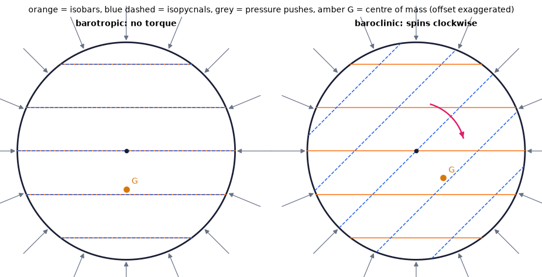

```python
fig, (a, b) = plt.subplots(1, 2, figsize=(9, 4.2))                   # barotropic | baroclinic
sa = disc_element(a, (0, 0), 1.0, isobars=0.0, isopycnals=0.0)       # isobars and isopycnals both horizontal
sb = disc_element(b, (0, 0), 1.0, isobars=0.0, isopycnals=np.pi/4)   # isopycnals tilted 45° to the isobars
a.set_title(sa["status"], fontsize=9)                                # the scenario's verdict: no torque
b.set_title(f"baroclinic: spins {sb['sense']}", fontsize=9)          # the sense of the torque
fig.suptitle("orange = isobars, blue dashed = isopycnals, grey = pressure pushes, amber G = centre of mass (offset exaggerated)", fontsize=9)
savefig(fig, "ch05", "baroclinic_discs"); plt.show()                 # save the PNG to outputs/ch05, then draw
```

**What you see.** (Note `N50`, Fig. 5.6 analogue.) On the left, isobars and isopycnals are parallel and G sits on the vertical force line through the centre; on the right, the isopycnals are tilted 45°, G sits off the force line, and a rose arrow shows the element turning.

**How to read it.** The pressure pushes (grey) all point at the geometric centre, so their sum passes through it; only a density gradient across the isobars moves G off that line — that lever arm is the torque. (G's true offset is R²∇ρ/4ρ₀, about 10⁻⁵ of R; it is drawn at 0.35R so you can see it.)

**What would change if…** …the isopycnals turned to vertical (90° to the isobars): the offset across the force line, the lever arm and the torque are largest (sin 90° = 1).

> 🔁 **Tools from earlier chapters used here** (see `knowledge/primers.md`)
- **np.deg2rad** — converts degrees to radians, which numpy's trigonometric functions expect (Ch. 2 P66).

```python
ang = np.linspace(0, 180, 181)                                       # angle between isopycnals and isobars [deg]
rates = np.array([ch05.baroclinic_element_scenario(np.deg2rad(a_), 10.0, 0.01)["spin_up"] for a_ in ang])   # spin-up [1/s²]


def tilt(a_deg):                                                     # slider value → curves
    rnow = ch05.baroclinic_element_scenario(np.deg2rad(a_deg), 10.0, 0.01)["spin_up"]   # the rate at this angle
    return {"spin-up rate": (ang, rates), "this angle": ([a_deg], [rnow]),                          # the curves for this slider value
            "formula |∇ρ||∇p| sin θ/ρ²": (ang, -10*9810*np.sin(np.deg2rad(ang))/1000.0**2)}         # the formula of (5.28) as a dashed ghost


fig = slider_figure(tilt, "tilt", np.linspace(0, 180, 19 if not FAST else 10), unit="°",            # precompute every slider position
                    xlabel="angle between isopycnals and isobars [deg]", ylabel="spin-up rate Dω/Dt [1/s²]",  # axis labels with units
                    title="The torque switches on as the isolines cross", modes={"this angle": "markers"})  # the message of the figure
recolor(fig, {"spin-up rate": COLORS["orange"], "this angle": COLORS["ink"], "formula |∇ρ||∇p| sin θ/ρ²": COLORS["muted"]},  # house colours by trace name
        dashes={"formula |∇ρ||∇p| sin θ/ρ²": "dash"})                                               # dashed reference curves
for tr in fig.data:                                                  # bigger marker for the current angle
    if tr.name == "this angle":                                                                     # the current-angle marker
        tr.marker.size = 12                                                                         # made larger
fig.show()                                                                                          # draw it (works on the web page too)
```

[interactive chart not shown]

**What you see.** An orange curve on the grey dashed formula: zero at 0° and 180° (parallel isolines), largest in size at 90°; the black dot follows the slider.

**How to read it.** The spin-up is $\frac1{\rho^2}\lvert\nabla\rho\rvert\lvert\nabla p\rvert\sin\theta$: the cross product of (5.28), $-\varepsilon_{nqi}\Big(\frac1\rho p_{,i}\Big)_{,q}=\frac1{\rho^2}[\nabla\rho\times\nabla p]_n$. Its sign here is negative (clockwise) because density increases to the right of the upward pressure force.

**What would change if…** …∇ρ doubled: the whole curve doubles; the zeros at 0° and 180° stay — no density contrast, however large, spins fluid whose isopycnals are parallel to its isobars.

> 🔁 **Tools from earlier chapters used here** (see `knowledge/primers.md`)
- **reduced gravity** — $g'=g\,\Delta\rho/\bar\rho$ is the gravity felt by one fluid floating in another (Ch. 4 P131).

📝 **Note.** **Lock exchange** `N15` — (Fig. 5.5): fresh water (ρ₁) and salt water (ρ₂) side by side, a gate pulled out: the heavy fluid slumps under, the light rides over, the interface tilts — vorticity has been made. Its first-instant rate (derived below; the book leaves it to Exercise 5.5) is the formula underneath. **Number:** ρ₁ = 1000, ρ₂ = 1025 kg/m³, interface 10 cm thick: 2.42 s⁻². Sea breezes, gravity currents and oceanic fronts start the same way (Ch. 13).

$$ \frac{D\omega_z}{Dt}=\frac{2(\rho_2-\rho_1)g}{(\rho_2+\rho_1)\delta} $$

#### 🧮 Derivation — The initial spin-up rate of a lock exchange `D07` (Eq. 5.28)

**What we want to show.** Two fluids side by side, heavy ρ₂ on the left and light ρ₁ on the right, separated by an interface of thickness δ; the gate is pulled at t = 0. Find how fast vorticity appears at the interface at the first instant — the book leaves this to an exercise.

**Assumptions.** Fluid at rest at t = 0⁺ (step 1); thin interface δ ≪ depth (step 2); pressure still hydrostatic with the mean density (step 3); ρ₂ − ρ₁ ≪ ρ̄ (step 5).

**The plan.**

1. Argue every other term is zero at t = 0⁺.
2. Estimate ∇ρ across the interface and ∇p from hydrostatics.
3. Cross them.
4. Divide by ρ².

**Tools we use** (each explained before this point): D06's result · hydrostatics (R06) · e_x × e_y = e_z (ch02 P74, reminder) · smoothed step with `np.tanh` (gloss).

**We start from**

$$ \frac{D\boldsymbol\omega}{Dt}=\frac{1}{\rho^2}\nabla\rho\times\nabla p\ \text{(D06, the baroclinic part of (5.30))} $$

*In words:* crossed density and pressure gradients spin the fluid.

**Step 1 of 7 — Note the fluid is still at rest.**

$$ \mathbf u=\mathbf 0,\ \boldsymbol\omega=\mathbf 0\ \Rightarrow\ \frac{D\boldsymbol\omega}{Dt}=\frac{1}{\rho^2}\nabla\rho\times\nabla p $$

- *Why we can do this:* With u = ω = 0 the stretching, tilting, planetary and diffusion terms of (5.30), $\frac{D\boldsymbol\omega}{Dt}=(\boldsymbol\omega+2\boldsymbol\Omega)\cdot\nabla\mathbf u+\frac1{\rho^2}\nabla\rho\times\nabla p+\nu\nabla^2\boldsymbol\omega$ all vanish; only the baroclinic source can act.
- *In words:* At the first instant only the torque of D06 works.

**Step 2 of 7 — Estimate the density gradient.**

$$ \nabla\rho\approx\frac{\rho_1-\rho_2}{\delta}\,\mathbf e_x $$

- *Why we can do this:* Density drops from ρ₂ to ρ₁ across a layer of width δ going in +x (x to the right, y up). A tanh profile has exactly this slope at its centre (gloss).
- *In words:* Density falls steeply from left to right.

**Step 3 of 7 — Use hydrostatic pressure with the mean density.**

$$ \nabla p\approx-\bar\rho\,g\,\mathbf e_y,\qquad\bar\rho=\tfrac12(\rho_1+\rho_2) $$

- *Why we can do this:* Before anything moves, pressure is hydrostatic (R06); at the interface the weight above is on average ρ̄.
- *In words:* Pressure increases downward.

**Step 4 of 7 — Take the cross product.**

$$ \nabla\rho\times\nabla p=\frac{(\rho_2-\rho_1)\bar\rho g}{\delta}\,\mathbf e_z $$

- *Why we can do this:* e_x × e_y = e_z (right-hand rule); the two minus signs (ρ₁ − ρ₂ < 0 and −ρ̄g) cancel.
- *In words:* The source points out of the page: counterclockwise.

**Step 5 of 7 — Divide by the density squared.**

$$ \frac{D\omega_z}{Dt}=\frac{(\rho_2-\rho_1)g}{\bar\rho\,\delta} $$

- *Why we can do this:* at the interface centre ρ = ρ̄ exactly, so ρ² = ρ̄² there (off the centre the small contrast, 2.5 % here, keeps ρ² ≈ ρ̄²); one ρ̄ cancels.
- *In words:* Rate = reduced gravity divided by the interface thickness.

**Step 6 of 7 — Substitute the mean density.**

$$ \frac{D\omega_z}{Dt}=\frac{2(\rho_2-\rho_1)g}{(\rho_2+\rho_1)\delta} $$

- *Why we can do this:* ρ̄ = (ρ₁ + ρ₂)/2. This is the form the exercise asks for.
- *In words:* The heavier the contrast and the sharper the interface, the faster the spin-up.

**Step 7 of 7 — Read the sense of rotation.**

$$ \frac{D\omega_z}{Dt}>0\ \Rightarrow\ \text{counterclockwise} $$

- *Why we can do this:* Positive ω_z is counterclockwise (our convention, set in the notation cell: ω_z > 0 means counterclockwise): the heavy left fluid slides right along the bottom, the light fluid left along the top — the tumbling of Fig. 5.5.
- *In words:* The interface tips over, heavy under light.

**Result**

$$ \frac{D\omega_z}{Dt}\Big\rvert_{t=0^+}=\frac{2(\rho_2-\rho_1)g}{(\rho_2+\rho_1)\delta} $$

*In words:* the interface starts to tumble at the reduced gravity divided by its thickness.

**What it means.** Density currents, sea breezes and oceanic fronts begin exactly like this (Ch. 13); the reduced gravity g′ of Ch. 4 reappears.

**Check it.** Units: (m/s²)/m = s⁻² ✓. ρ₂ = ρ₁ gives 0 ✓. δ → 0 gives an infinite rate at a vortex sheet (C14) — the circulation per unit height, rate × δ = 2(ρ₂−ρ₁)g/(ρ₂+ρ₁), stays finite ✓. Field route (`baroclinic_term` on the tanh step with hydrostatic p, the code cell right after this derivation) = 2.4222 s⁻² at x = 0 ✓.

> ⚠️ **Common confusion (traps in `D07`):** Using ρ₂ − ρ₁ with the heavy fluid on the right (the sign flips). Letting the pressure gradient have a horizontal part at t = 0 (it appears only once the fluid moves).

```python
print(ch05.lock_exchange_initial_vorticity_rate(1000.0, 1025.0, 0.1))   # the closed form of D07 [1/s²]: 2.422222
F = ch05.lock_exchange_fields(1000.0, 1025.0, 0.1)                   # tanh-step density and hydrostatic pressure (fluid at rest)
print([f"{v:.6f}" for v in ch05.baroclinic_term(F["rho_fn"], F["p_fn"], np.array([0.0, 0.5]))])   # the field route at the interface, mid-depth [1/s²]
print([round(ch05.lock_exchange_initial_vorticity_rate(1000.0, 1025.0, d), 4) for d in (0.2, 0.05, 0.01)])   # thinner → faster
```

```
2.422222222222222
['0.000000', '0.000000', '2.422219']
[1.2111, 4.8444, 24.2222]
```

**What does the code above do?**

1. The closed form $2(\rho_2-\rho_1)g/((\rho_2+\rho_1)\delta)$ = 2.422222 s⁻².
2. The field route: `baroclinic_term` differentiates the tanh-step density and the hydrostatic pressure by central differences at the interface and returns $(0,0,(\nabla\rho\times\nabla p)_z/\rho^2)$ = (0, 0, 2.422219) — the same number (the 3×10⁻⁶ gap is ρ² at the interface centre versus ρ̄², D07 step 5).
3. A thinner interface spins faster: 1.2111, 4.8444, 24.2222 s⁻² for δ = 20, 5, 1 cm — in the limit it is a vortex sheet (C14).

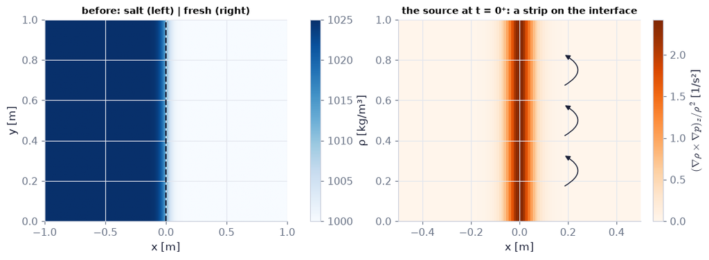

```python
F = ch05.lock_exchange_fields(1000.0, 1025.0, 0.1, nx=201 if not FAST else 101, ny=101 if not FAST else 51)   # fields on a grid
ext = (F["x"][0], F["x"][-1], F["y"][0], F["y"][-1])                 # plot extent [m]
fig, (a, b) = plt.subplots(1, 2, figsize=(10, 3.6))                  # before | baroclinic source
im = a.imshow(F["rho_grid"], origin="lower", extent=ext, cmap="Blues", aspect="auto")   # density: salt (dark) left, fresh right
a.axvline(0.0, color=COLORS["ink"], ls="--", lw=1.5)                 # the gate
a.set_title("before: salt (left) | fresh (right)", fontsize=10); a.set_xlabel("x [m]"); a.set_ylabel("y [m]")
fig.colorbar(im, ax=a, label="ρ [kg/m³]")                            # density scale
im2 = b.imshow(F["baroclinic_z"], origin="lower", extent=ext, cmap="Oranges", aspect="auto")   # (∇ρ × ∇p)_z/ρ² [1/s²]
fig.colorbar(im2, ax=b, label=r"$(\nabla\rho\times\nabla p)_z/\rho^2$ [1/s²]")   # colour scale with units
for yc in (0.25, 0.5, 0.75):                                         # counterclockwise tumbling arrows along the interface
    b.annotate("", (0.18, yc + 0.08), (0.18, yc - 0.08), arrowprops=dict(arrowstyle="-|>", color=COLORS["ink"],
               connectionstyle="arc3,rad=0.9"))                       # a curved arrow: counterclockwise
b.set_xlim(-0.5, 0.5); b.set_title("the source at t = 0⁺: a strip on the interface", fontsize=10); b.set_xlabel("x [m]")
savefig(fig, "ch05", "lock_exchange"); plt.show()                    # save the PNG to outputs/ch05, then draw
```

**What you see.** (Note `N49`, Fig. 5.5 analogue.) Left, dense salt water (dark) beside fresh water with the gate dashed; right, a bright orange vertical strip on the interface and curved arrows turning counterclockwise.

**How to read it.** Vorticity is created only where density changes sideways — at the interface — in the counterclockwise sense: heavy fluid slides under to the right along the bottom, light fluid over to the left along the top.

**What would change if…** …the gate between two fluids of equal density: the strip vanishes; nothing happens.

#### 🎮 Interactive: How can density make fluid spin?

**Why interactive rather than a static figure:** turning the isopycnals against the isobars and watching the force line leave the centre of mass, the torque grow as the sine of the angle and two independent routes agree, makes (5.28), $-\varepsilon_{nqi}\Big(\frac1\rho p_{,i}\Big)_{,q}=\frac1{\rho^2}[\nabla\rho\times\nabla p]_n$ a mechanism instead of a formula.

The lock-exchange mode shows the same torque on a whole interface.

**What to try:**

- Set the tilt to 0°: no torque however large ∇ρ.
- Drag the tilt to 90°: the badge reads the spin-up and its sense.
- Shrink the disc: the two routes converge (the ratio → 1).
- Lock exchange: thin the interface and watch the rate grow as 1/δ.

```python
show_viz("ch05", "baroclinic_torque")   # full-width explainer; ⤢ Full screen for more room
```

🎮 Interactive 4/9 How can density make fluid spin? Open alone ↗

[interactive chart not shown]

**What would change if…** …the fluid were also rotating, like the atmosphere? The baroclinic torque would still act, but the new spin would be turned and stretched by the planet's own vorticity — both appear together in the rotating-frame vorticity equation (C09).

## 5.3 Helmholtz's Vortex Theorems

**What is this section about?** Under Kelvin's four restrictions, vorticity is glued to the fluid: vortex lines move with it, and a tube keeps its strength along its length and in time. Two of the four theorems are (5.4), $\int_V\nabla\cdot\boldsymbol\omega\,dV=\int_A\boldsymbol\omega\cdot\mathbf n\,dA=-\Gamma_{\text{lower end}}+\Gamma_{\text{upper end}}=0$ again; the other two follow from Kelvin in a few lines.

### 🧩 Helmholtz's theorems: vortex lines move with the fluid `C05`

*The question:* A smoke ring drifts across a room. Is the ring of spin always made of the same smoke — or does the swirl slide through the air?

*In one line:* vortex lines are material lines when Kelvin's four restrictions hold — and a tube's strength is the same along it, $-\Gamma_{\text{lower end}}+\Gamma_{\text{upper end}}=0$ *(5.4)*, and constant in time, $D\Gamma/Dt=0$ *(5.8)*.

#### The problem in plain words

If vorticity stays attached to the same fluid, we can follow a vortex simply by following its fluid: the whole of §5.7 (point vortices, rings) and the potential-vorticity thinking of Ch. 13 rest on it. Helmholtz found four rules; we prove the one that needs work.

#### The idea

```
(1) vortex lines move with the fluid       <- Kelvin on patches of a tube wall (D08)
(2) a tube has one strength along it       <- (5.4), geometry (D01)
(3) a tube cannot end in the fluid         <- (5.4)
(4) a tube keeps its strength in time      <- Kelvin on a loop round the tube (5.8)
(1), (4) need Kelvin's four restrictions; (2), (3) hold always
```

*The numbered equations in the sketch:* $\int_V\nabla\cdot\boldsymbol\omega\,dV=\int_A\boldsymbol\omega\cdot\mathbf n\,dA=-\Gamma_{\text{lower end}}+\Gamma_{\text{upper end}}=0$ *(5.4)* · $\frac{D\Gamma}{Dt}=0$ *(5.8)*

📝 **Note.** **Fig. 5.7** `N51` — Our 3-D picture further down shows a patch S on the wall of a tube and its material image S′ some time later; we make no separate computation of it.

> 🔁 **Tools from earlier chapters used here** (see `knowledge/primers.md`) — needed in the derivation below
- **small-patch localisation ("for every S")** — if an integral of a continuous function vanishes over every small patch, the function itself vanishes everywhere (Ch. 4 P112).

#### 🧮 Derivation — Helmholtz's vortex theorems from Kelvin's theorem and (5.4) `D08` (Eq. 5.8)

**What we want to show.** Prove that vortex lines move with the fluid (Helmholtz 1) using only Kelvin's theorem and Stokes' theorem, and see that the other three theorems are (5.4), $\int_V\nabla\cdot\boldsymbol\omega\,dV=\int_A\boldsymbol\omega\cdot\mathbf n\,dA=-\Gamma_{\text{lower end}}+\Gamma_{\text{upper end}}=0$ and (5.8), $\frac{D\Gamma}{Dt}=0$ restated.

**Assumptions.** Kelvin's four restrictions — inviscid, barotropic, conservative body forces, inertial frame (step 4); smooth ω (step 6).

**The plan.**

1. Put a small patch on a tube's wall.
2. Its edge has zero circulation.
3. Carry the patch with the flow; Kelvin keeps the zero.
4. Conclude the carried patch still lies on a tube wall, for every patch.

**Tools we use** (each explained before this point): Kelvin's theorem (C03) · tube wall has ω·n = 0 (C01) · Stokes' theorem (2.34), $\int_A(\nabla\times\mathbf u)\cdot\mathbf n\,dA=\oint_C\mathbf u\cdot d\mathbf x$ (Ch. 2 §2.13) · the small-ball (small-patch) argument (ch04 P112, reminder).

**We start from**

$$ D\Gamma/Dt=0\ \text{(5.8) for every material loop, and}\ -\Gamma_{\text{lower end}}+\Gamma_{\text{upper end}}=0\ \text{(5.4)} $$

*In words:* circulation is carried by the fluid; tube strength is the same along a tube.

**Step 1 of 9 — Draw a patch on the tube wall.**

$$ S\subset\text{tube wall},\quad \partial S=\text{its edge} $$

- *Why we can do this:* Fig. 5.7: a small surface lying in the wall that does not wrap round the tube. We will follow it in time.
- *In words:* Paint a small patch on the side of the tube.

**Step 2 of 9 — Note vorticity lies along the patch.**

$$ \boldsymbol\omega\cdot\mathbf n=0\ \text{on}\ S $$

- *Why we can do this:* The wall is made of vortex lines (C01), so ω is tangent to it everywhere.
- *In words:* No vorticity pierces the patch.

**Step 3 of 9 — Apply Stokes to the patch's edge.**

$$ \Gamma_{\partial S}=\int_S\boldsymbol\omega\cdot\mathbf n\,dA=0 $$

- *Why we can do this:* Stokes' theorem (2.34), $\int_A(\nabla\times\mathbf u)\cdot\mathbf n\,dA=\oint_C\mathbf u\cdot d\mathbf x$: circulation round an edge = vorticity flux through the surface it bounds.
- *In words:* A loop drawn round the patch has zero circulation.

**Step 4 of 9 — Carry the edge with the fluid.**

$$ \Gamma_{\partial S'}(t)=\Gamma_{\partial S}(0)=0 $$

- *Why we can do this:* The edge is a material loop, so Kelvin's theorem (5.8), $\frac{D\Gamma}{Dt}=0$ keeps its circulation; its particles now bound a new surface S′.
- *In words:* The carried loop still has zero circulation.

**Step 5 of 9 — Apply Stokes to the carried patch.**

$$ \int_{S'}\boldsymbol\omega\cdot\mathbf n\,dA=0 $$

- *Why we can do this:* Stokes' theorem (2.34), $\int_A(\nabla\times\mathbf u)\cdot\mathbf n\,dA=\oint_C\mathbf u\cdot d\mathbf x$ again, now applied to the carried patch S′, whose edge is the carried loop of step 4: its zero circulation becomes zero flux.
- *In words:* No net vorticity pierces the carried patch.

**Step 6 of 9 — Use "for every patch" to localise.**

$$ \boldsymbol\omega\cdot\mathbf n=0\ \text{at every point of the carried wall} $$

- *Why we can do this:* The book skips this: steps 1–5 hold for every patch; if ω·n ≠ 0 somewhere, a tiny patch there would have nonzero flux (continuity, P112) — contradiction.
- *In words:* Not just on average: nowhere does vorticity pierce the carried wall.

**Step 7 of 9 — Conclude tube walls and lines are material.**

$$ \text{carried tube wall}=\text{tube wall}\ \Rightarrow\ \text{vortex lines move with the fluid} $$

- *Why we can do this:* A surface everywhere tangent to ω is a tube wall. Shrinking the tube to zero section turns the statement about walls into one about lines.
- *In words:* Helmholtz 1: particles on a vortex line stay on a vortex line.

**Step 8 of 9 — Recognise theorems 2 and 3.**

$$ \Gamma_{\text{lower end}}=\Gamma_{\text{upper end}} $$

- *Why we can do this:* That is (5.4), $\int_V\nabla\cdot\boldsymbol\omega\,dV=\int_A\boldsymbol\omega\cdot\mathbf n\,dA=-\Gamma_{\text{lower end}}+\Gamma_{\text{upper end}}=0$ (D01): kinematic, true even with viscosity. It forbids tubes ending in the fluid.
- *In words:* Helmholtz 2 and 3: one strength per tube, no loose ends.

**Step 9 of 9 — Recognise theorem 4.**

$$ \frac{D}{Dt}\oint_{C_{\text{tube}}}\mathbf u\cdot d\mathbf x=0 $$

- *Why we can do this:* A loop round the tube on its wall is material and stays on the wall (step 7), so by Kelvin its circulation — the tube strength — is constant in time.
- *In words:* Helmholtz 4: a tube's strength never changes.

**Result**

$$ \begin{array}{l}\text{Helmholtz's theorems — (1) vortex lines move with the fluid; (2) a tube's} \\ \text{strength is the same along it; (3) tubes cannot end in the fluid; (4) a tube's} \\ \text{strength is constant in time — under Kelvin's four restrictions (1, 4) or} \\ \text{always (2, 3).}\end{array} $$

**What it means.** Vortices are carried by the flow — the rule behind point vortices, rings and sheets (C12–C14) and behind "frozen-in" potential vorticity (Ch. 13). Viscosity (reconnection) or baroclinicity breaks theorems 1 and 4.

**Check it.** Numerically (the frozen-in cell at the end of C06, §5.4): a material element δx started along ω in the ABC flow (steady, inviscid, ω = u) stays parallel to ω (angle < 1e-8) and |ω|/|δx| stays 1 to 1e-8; the viscous Burgers vortex drifts ✓. The small ABC loop on a tube wall (the code cell after the tiny example below) keeps Γ = 8.0×10⁻¹⁰ m²/s (vs |ω|A = 5.4×10⁻⁴) and its normal at 90° to ω ✓.

> ⚠️ **Common confusion (traps in `D08`):** Proving it for one patch only (step 6 needs every patch). Believing theorem 3 needs an ideal fluid.

📝 **Note.** **Why "for every patch" matters** `N17` — One patch with zero circulation proves only that the total flux through it vanishes; because *every* patch on the wall keeps zero circulation, the flux vanishes locally (D08 step 6) — the carried wall is again a tube wall. A second proof (the field-equation route: ω and a material element obey the same equation when ν = 0) needs the vorticity equation and is checked at the end of C06.

> 🔁 **Tools from earlier chapters used here** (see `knowledge/primers.md`)
- **np.cross, np.linalg.norm and @** — `np.cross(a, b)` is the cross product (row by row for arrays of vectors), `np.linalg.norm(v)` a vector's length, and `A @ b` a matrix–vector (or dot) product (Ch. 2 P67, Ch. 4).

> 📎 **Primer — loop vector area ½∮x × dx.** `P138` · For a closed loop, $\mathbf A_{vec}=\tfrac12\oint\mathbf x\times d\mathbf x$ is a vector whose length is the area enclosed (for a flat loop) and whose direction is the loop's normal by the right-hand rule; for a curved loop it is ∫n dA over any surface spanning it. The 2-D version is the surveyor's shoelace formula. We use it to ask whether a small loop still lies on a tube wall (its normal ⟂ ω) and, in C11, for the planetary circulation.

```python
s = 2*np.pi*np.arange(400)/400                                  # tags round a loop [rad]
P = np.array([2*np.cos(s), np.sin(s), 0*s])                     # an ellipse in the (x, y) plane, semi-axes 2 and 1 [m]
dP = np.roll(P, -1, axis=1) - P                                 # the chord to the next point (np.roll shifts the columns by one)
print(0.5*np.sum(np.cross(P.T, dP.T), axis=0), 2*np.pi)         # ≈ (0, 0, 6.28293) vs πab = 6.28319 m²: chords cut the corners
print(ch05.loop_vector_area(P))                                 # the library's spectral version: (0, 0, 6.283185)
```

```
[0.     0.     6.2829] 6.283185307179586
[0.     0.     6.2832]
```

#### ✏️ Tiny example: a small loop painted on a tube wall

The **ABC flow** $\mathbf u=(\sin z+\cos y,\ \sin x+\cos z,\ \sin y+\cos x)$ (in m and m/s) is a steady solution of Euler's equation whose vorticity equals its velocity, ω = u — Kelvin holds exactly.

1. At the origin ω = (1, 1, 1) s⁻¹, |ω| = 1.732 s⁻¹.
2. Paint a circle of radius 1 cm there in the plane spanned by ω and (1, −1, 0)/√2: its normal (1, 1, −2)/√6 is perpendicular to ω, so the patch lies on the local tube wall.
3. Its flux ω·n A is zero to first order; the curvature of the field leaves Γ ≈ 8×10⁻¹⁰ m²/s, against |ω|A = 5.4×10⁻⁴ m²/s for a patch facing ω.
4. Let the flow carry it for 2 s: Kelvin keeps Γ at 8×10⁻¹⁰ m²/s, so the carried patch still faces across ω — it is still on a tube wall.

```python
hsc = ch05.kelvin_scenario("helmholtz_abc")                          # the ABC flow and the painted loop (256 points, r = 1 cm)
t = np.linspace(0, 2.0, 5)                                           # 0, 0.5, …, 2 s
Pl = ch05.material_loop(hsc["u"], hsc["pts0"], t)                    # the loop carried by the flow, shape (5, 3, 256) [m]
Gh = ch05.material_circulation(hsc["u"], hsc["pts0"], t)             # its circulation [m²/s]
cosang = []                                                          # cos of the angle between the loop's normal and ω
for Pk in Pl:                                                        # at each time
    A = ch05.loop_vector_area(Pk)                                    # vector area of the carried loop [m²]
    w = hsc["u"](Pk.mean(axis=1), 0.0)                               # ω = u of the ABC flow at the loop's centre [1/s]
    cosang.append(A @ w/(np.linalg.norm(A)*np.linalg.norm(w)))       # 0 when the loop lies on a tube wall
print("Γ(t) =", [f"{g:.4e}" for g in Gh], "m²/s")                   # 8.0159e-10 m²/s every time
print(f"max |cos(normal, ω)| = {np.max(np.abs(cosang)):.1e}")        # stays ≈ 0: the normal stays at 90° to ω
print("length(t) =", np.round([ch05.loop_length(Pk) for Pk in Pl], 4), "m")   # the loop is really deformed
```

```
Γ(t) = ['8.0159e-10', '8.0159e-10', '8.0159e-10', '8.0159e-10', '8.0159e-10'] m²/s
max |cos(normal, ω)| = 1.3e-05
length(t) = [0.0628 0.0714 0.0675 0.0605 0.0682] m
```

**What does the code above do?**

1. An inviscid steady flow and a small loop lying on a tube wall.
2. The loop advected (one `solve_ivp` call for all 256 points).
3. Its circulation stays at its tiny starting value 8.0159×10⁻¹⁰ m²/s (Kelvin, $D\Gamma/Dt=0$ (5.8)).
4. The angle between the loop's vector area and ω stays 90° (|cos| ≤ 1.3×10⁻⁵) while the loop's length changes by about 14 %: the carried patch is still on a tube wall — Helmholtz 1 seen in numbers.

**From scratch — the vector area by the shoelace chords of the primer**, for the last carried loop:

```python
Pk = Pl[-1]                                                          # the loop at t = 2 s, shape (3, 256) [m]
A_hand = 0.5*np.sum(np.cross(Pk.T, (np.roll(Pk, -1, axis=1) - Pk).T), axis=0)   # ½ Σ x × (chord to the next point) [m²]
A_lib = ch05.loop_vector_area(Pk)                                    # the library's spectral version [m²]
print("chords:", [f"{a:+.5e}" for a in A_hand], " library:", [f"{a:+.5e}" for a in A_lib])   # the same vector to ~1e-4 relative
flux = A_hand @ hsc["u"](Pk.mean(axis=1), 0.0)                       # vorticity flux through the carried patch [m²/s]
print(f"flux through the carried patch {flux:.1e} m²/s vs |ω||A| = {np.linalg.norm(A_hand)*np.sqrt(3):.1e} m²/s")
assert np.allclose(A_hand, A_lib, rtol=1e-3)                         # chords vs spectral: same area vector
assert abs(flux) < 1e-8                                              # no vorticity pierces the carried patch
```

```
chords: ['-1.54137e-04', '+1.18269e-04', '+3.58673e-05']  library: ['-1.54153e-04', '+1.18281e-04', '+3.58709e-05']
flux through the carried patch 1.7e-09 m²/s vs |ω||A| = 3.4e-04 m²/s
```

Our own chord sum says the same: no vorticity pierces the carried patch (10⁻⁹ against 3×10⁻⁴ m²/s for a patch facing ω).

```python
zs = np.linspace(0, 1.5, 40 if not FAST else 24)                      # heights along the narrowing tube [m]
ph = np.linspace(0, 2*np.pi, 60 if not FAST else 36)                  # angles round it [rad]
ZZ, PH = np.meshgrid(zs, ph)                                          # surface grid
RT = 0.1*np.exp(-ZZ/2)                                                # tube wall radius R_t(z) = R0 e^{−z/2L} [m]
fig = go.Figure(go.Surface(x=RT*np.cos(PH), y=RT*np.sin(PH), z=ZZ, opacity=0.35, showscale=False,   # the translucent tube wall
                           colorscale=[[0, COLORS["teal"]], [1, COLORS["teal"]]], name="tube wall"))  # one flat teal colour
for p0 in np.linspace(0, 2*np.pi, 12, endpoint=False):               # vortex lines on the wall (untwisted tube: φ = const)
    fig.add_trace(go.Scatter3d(x=0.1*np.exp(-zs/2)*np.cos(p0), y=0.1*np.exp(-zs/2)*np.sin(p0), z=zs, mode="lines",  # a vortex line on the wall
                               line=dict(color=COLORS["teal"], width=3), showlegend=False))         # thin teal line


def patch(z0, z1, p0, p1, col, name):                                # a patch of the wall between two heights and angles
    zp, pp = np.meshgrid(np.linspace(z0, z1, 12), np.linspace(p0, p1, 12))                          # the patch's (z, φ) grid
    rp = 0.1*np.exp(-zp/2)*1.002                                      # just outside the wall so it shows
    return go.Surface(x=rp*np.cos(pp), y=rp*np.sin(pp), z=zp, showscale=False, opacity=0.95,        # the patch as a small surface
                      colorscale=[[0, col], [1, col]], name=name)                                   # one flat colour


fig.add_trace(patch(0.10, 0.30, 0.0, 0.6, COLORS["orange"], "S (t = 0)"))              # the painted patch
fig.add_trace(patch(0.60, 1.20, 0.0, 0.6, COLORS["amber"], "S′ (later, schematic)"))  # the same particles, stretched along the tube
fig.update_layout(height=480, margin=dict(l=0, r=0, t=40, b=0), title="Schematic: a patch on a tube wall stays on the wall",  # size, margins, title
                  scene=dict(aspectmode="data", xaxis_title="x [m]", yaxis_title="y [m]", zaxis_title="z [m]"))  # equal axes, labels with units
fig.show()                                                                                          # draw it (works on the web page too)
```

[interactive chart not shown]

**What you see.** A translucent teal tube narrowing upward with its vortex lines drawn on the wall; an orange patch low down and an amber patch higher up, longer along the tube and narrower round it.

**How to read it.** Helmholtz 1: the patch's edge has zero circulation for ever, so it never tilts off the wall — the particles of S become S′, still lying on the wall between the same vortex lines. (A schematic: S′ is drawn, not computed; the ABC cell above is the computation.)

**What would change if…** …viscosity: the patch's circulation would leak and the lines could reconnect — the patch would drift off the wall on the diffusion time scale.

🎮 Open **Stretch and tangle a loop of dye — what stays the same?** (embedded in C03 above) and switch on its *Helmholtz* mode: a small loop on a tube wall keeps zero flux while it is carried.

**What would change if…** …the vortex were a straight line vortex in a flow that carries it along? Then Helmholtz 1 says the vortex goes wherever the local flow (made by everything else) takes it — the rule of §5.7.

## 5.4 Vorticity Equation in a Nonrotating Frame

**What is this section about?** Taking the curl of Navier–Stokes removes pressure and gravity and leaves an equation for the vorticity alone: vorticity is carried by the flow, stretched and tilted by velocity gradients along it, and diffused by viscosity. This section derives it for a fluid of constant density in an inertial frame; §5.6 adds rotation and density variations.

> 🔁 **Recap — Vorticity has no divergence** (Ch. 2 §2.13). $\nabla\cdot\boldsymbol\omega=\nabla\cdot(\nabla\times\mathbf u)=0$ for every smooth flow — the divergence of a curl vanishes (Ch. 2). §5.6 proves it again in index form as $\omega_{i,i}=\varepsilon_{inq}u_{q,ni}=0$ *(5.18)*.

> 🔁 **Recap — The Lamb identity** (Ch. 4 §4.9). $(\mathbf u\cdot\nabla)\mathbf u=\nabla(\tfrac12\mathbf u\cdot\mathbf u)+\boldsymbol\omega\times\mathbf u$, the vector form of $u_i\frac{\partial u_j}{\partial x_i}=-(\mathbf u\times\boldsymbol\omega)_j+\frac{\partial}{\partial x_j}\big(\tfrac12u_i^2\big)$ *(4.68)*: the advective acceleration is the gradient of the kinetic energy plus the Lamb vector ω × u. ⚠️ The book's §5.4 line writes $\nabla(\mathbf u\cdot\mathbf u)$ without the ½ — harmless there, because the next move takes a curl, which kills any gradient.

```python
lt = ns.lamb_identity_terms(vortices.vortex_velocity_field("gaussian", Gamma=1.0, sigma=0.1), np.array([0.07, 0.02]))   # Gaussian vortex, one point
print("advective (u·∇)u:", lt["advective"], " residual:", [f"{v:.1e}" for v in lt["residual"]])   # residual ~1e-6 against terms of ~16 m/s²: stencil error
```

```
advective (u·∇)u: [-10.6833  -3.0524]  residual: ['6.3e-06', '3.4e-06']
```

> 🔁 **Tools from earlier chapters used here** (see `knowledge/primers.md`)
- **Schwarz's theorem** — mixed partial derivatives of a smooth function commute: $\partial^2f/\partial x\partial y=\partial^2f/\partial y\partial x$ (Ch. 4 P121).
- **directional derivative (ω·∇)** — $(\boldsymbol\omega\cdot\nabla)\mathbf u$ is |ω| times the rate of change of u along ω's direction (Ch. 2 P75).

### 🧩 The vorticity equation `C06`

*The question:* Stir a cup of tea and the swirl slowly spreads and fades; a tornado tightens as its column is stretched. What can change a fluid particle's vorticity — and why can pressure never do it?

*In one line:* $\frac{D\boldsymbol\omega}{Dt}=(\boldsymbol\omega\cdot\nabla)\mathbf u+\nu\nabla^2\boldsymbol\omega$ *(5.13)*

#### The problem in plain words

Navier–Stokes tells how a particle's velocity changes. For swirl, we want the rule for its vorticity. Pressure is usually the hardest unknown in a flow; an equation without it is a gift — the basis of vorticity-based computer models (Ch. 10), of vortex decay (Ch. 8), of the turbulence cascade (Ch. 12) and of the quasi-geostrophic equations of Ch. 13.

#### The idea

```
momentum:   Du/Dt = -grad(p)/rho + g + nu lap(u)      take the curl  ---->   vorticity:  Dw/Dt = (w.grad)u + nu lap(w)   (5.13)
                    ^^^^^^^^^^^^   ^                                                  carried    stretched/tilted   diffused
            gradients: their curl is 0 (pressure and gravity push through the centre of mass: no twist)
```

*The numbered equations in the sketch:* $\frac{D\boldsymbol\omega}{Dt}=(\boldsymbol\omega\cdot\nabla)\mathbf u+\nu\nabla^2\boldsymbol\omega$ *(5.13)*

📝 **Note.** **§5.4's hypotheses** `N18` — constant density (so the fluid is barotropic), constant viscosity, conservative body force, inertial frame. §5.6 (C09) relaxes the first and the last.

📝 **Note.** **The first move** `N19` — of the derivation is (5.12), the curl of incompressible Navier–Stokes $\rho\frac{D\mathbf u}{Dt}=-\nabla p+\rho\mathbf g+\mu\nabla^2\mathbf u$ *(4.39b)*. The curls of −∇p/ρ and of g = −∇Φ vanish because both are gradients.

$$ \nabla\times\Big\{\frac{D\mathbf u}{Dt}=-\frac1\rho\nabla p+\mathbf g+\nu\nabla^2\mathbf u\Big\} \qquad \text{(5.12)} $$

📝 **Note.** **A vector identity we need** `N20` — (the book's (B.3.10)), in its general form (below). It follows from the ε–δ identity $\varepsilon_{ijk}\varepsilon_{klm}=\delta_{il}\delta_{jm}-\delta_{im}\delta_{jl}$ *(2.19)* and the product rule (Ch. 2 D09's moves); the sympy cell of D09 checks it for arbitrary fields. For incompressible flow the last two terms drop.

$$ \nabla\times(\boldsymbol\omega\times\mathbf u)=(\mathbf u\cdot\nabla)\boldsymbol\omega-(\boldsymbol\omega\cdot\nabla)\mathbf u+\boldsymbol\omega(\nabla\cdot\mathbf u)-\mathbf u(\nabla\cdot\boldsymbol\omega) $$

#### 🧮 Derivation — The vorticity equation by the vector route: (5.12) → (5.13) `D09` (Eq. 5.13)

**What we want to show.** Turn the momentum equation into an equation for the vorticity alone, to see what can change a particle's vorticity — and why pressure and gravity cannot.

**Assumptions.** ρ constant (step 2); g conservative (step 3); ν constant (step 7); ∇·u = 0 (step 10); smooth fields (steps 4, 7).

**The plan.**

1. Take the curl of every term, (5.12), $\nabla\times\Big\{\frac{D\mathbf u}{Dt}=-\frac1\rho\nabla p+\mathbf g+\nu\nabla^2\mathbf u\Big\}$.
2. Kill the gradient terms.
3. Rewrite the advective term with the Lamb identity.
4. Expand ∇×(ω×u) with (B.3.10) and drop what continuity and ∇·ω = 0 remove.
5. Regroup into D/Dt.

**Tools we use** (each explained before this point): curl of a gradient = 0 (Ch. 2 §2.13) · Schwarz's theorem (ch04 P121, reminder) · Lamb identity $(\mathbf u\cdot\nabla)\mathbf u=\nabla(\tfrac12\mathbf u\cdot\mathbf u)+\boldsymbol\omega\times\mathbf u$ (4.68), $u_i\frac{\partial u_j}{\partial x_i}=-(\mathbf u\times\boldsymbol\omega)_j+\frac{\partial}{\partial x_j}\big(\tfrac12u_i^2\big)$ (R11) · identity (B.3.10) (N20; ε–δ (2.19), $\varepsilon_{ijk}\varepsilon_{klm}=\delta_{il}\delta_{jm}-\delta_{im}\delta_{jl}$, Ch. 2 §2.7) · ∇·ω = 0 (R10) · material derivative (3.5), $\frac{DF}{Dt}=\frac{\partial F}{\partial t}+\mathbf u\cdot\nabla F$ (Ch. 3 §3.2).

**We start from**

$$ \frac{\partial\mathbf u}{\partial t}+(\mathbf u\cdot\nabla)\mathbf u=-\frac1\rho\nabla p+\mathbf g+\nu\nabla^2\mathbf u\ \text{(4.39b), ∇·u = 0} $$

*In words:* incompressible Navier–Stokes; §5.4 takes ρ and ν constant, g = −∇Φ, an inertial frame (N18).

**Step 1 of 12 — Take the curl of every term.**

$$ \nabla\times\Big\{\frac{D\mathbf u}{Dt}=-\frac1\rho\nabla p+\mathbf g+\nu\nabla^2\mathbf u\Big\} $$

- *Why we can do this:* ω = ∇×u, so the curl of the momentum equation is where an equation for ω must come from. This is (5.12), $\nabla\times\Big\{\frac{D\mathbf u}{Dt}=-\frac1\rho\nabla p+\mathbf g+\nu\nabla^2\mathbf u\Big\}$ — the line above.
- *In words:* Ask how each force twists the fluid rather than pushes it.

**Step 2 of 12 — Kill the pressure term.**

$$ \nabla\times\Big(-\frac1\rho\nabla p\Big)=-\nabla\times\nabla\Big(\frac p\rho\Big)=\mathbf 0 $$

- *Why we can do this:* With ρ constant, (1/ρ)∇p = ∇(p/ρ), a gradient, and the curl of a gradient is zero (Ch. 2). If ρ varied this would be the baroclinic term (5.28), $-\varepsilon_{nqi}\Big(\frac1\rho p_{,i}\Big)_{,q}=\frac1{\rho^2}[\nabla\rho\times\nabla p]_n$.
- *In words:* Pressure pushes through the centre of mass: no twist.

**Step 3 of 12 — Kill the gravity term.**

$$ \nabla\times\mathbf g=-\nabla\times\nabla\Phi=\mathbf 0 $$

- *Why we can do this:* Conservative body force g = −∇Φ (4.18), $\mathbf g=-\nabla\Phi$; again the curl of a gradient.
- *In words:* Gravity cannot spin fluid of uniform density.

**Step 4 of 12 — Swap curl and time derivative.**

$$ \nabla\times\frac{\partial\mathbf u}{\partial t}=\frac{\partial}{\partial t}(\nabla\times\mathbf u)=\frac{\partial\boldsymbol\omega}{\partial t} $$

- *Why we can do this:* Mixed partial derivatives commute for smooth fields (Schwarz, P121).
- *In words:* The curl of the velocity's rate is the vorticity's rate.

**Step 5 of 12 — Rewrite advection with the Lamb identity.**

$$ (\mathbf u\cdot\nabla)\mathbf u=\nabla\big(\tfrac12\mathbf u\cdot\mathbf u\big)+\boldsymbol\omega\times\mathbf u $$

- *Why we can do this:* (4.68), $u_i\frac{\partial u_j}{\partial x_i}=-(\mathbf u\times\boldsymbol\omega)_j+\frac{\partial}{\partial x_j}\big(\tfrac12u_i^2\big)$ (R11). The book prints ∇(u·u); the correct factor is ½ — harmless, because the next step's curl kills the gradient anyway.
- *In words:* Advection = gradient of kinetic energy + the Lamb vector.

**Step 6 of 12 — Take its curl.**

$$ \nabla\times[(\mathbf u\cdot\nabla)\mathbf u]=\nabla\times(\boldsymbol\omega\times\mathbf u) $$

- *Why we can do this:* The curl of the gradient ∇(½u²) is zero (Ch. 2).
- *In words:* Only the Lamb vector can twist.

**Step 7 of 12 — Move the curl through the Laplacian.**

$$ \nabla\times(\nu\nabla^2\mathbf u)=\nu\nabla^2(\nabla\times\mathbf u)=\nu\nabla^2\boldsymbol\omega $$

- *Why we can do this:* ν constant and derivatives commute (Cartesian components, Schwarz).
- *In words:* Viscosity diffuses vorticity as it diffuses momentum.

**Step 8 of 12 — Collect the surviving terms.**

$$ \frac{\partial\boldsymbol\omega}{\partial t}+\nabla\times(\boldsymbol\omega\times\mathbf u)=\nu\nabla^2\boldsymbol\omega $$

- *Why we can do this:* Steps 2–7 in (5.12), $\nabla\times\Big\{\frac{D\mathbf u}{Dt}=-\frac1\rho\nabla p+\mathbf g+\nu\nabla^2\mathbf u\Big\}$. This is the book's intermediate line.
- *In words:* A first vorticity equation, still with a tangled middle term.

**Step 9 of 12 — Expand the double cross product.**

$$ \nabla\times(\boldsymbol\omega\times\mathbf u)=(\mathbf u\cdot\nabla)\boldsymbol\omega-(\boldsymbol\omega\cdot\nabla)\mathbf u+\boldsymbol\omega(\nabla\cdot\mathbf u)-\mathbf u(\nabla\cdot\boldsymbol\omega) $$

- *Why we can do this:* Identity (B.3.10) in its general form (N20), proved with the ε–δ identity (2.19), $\varepsilon_{ijk}\varepsilon_{klm}=\delta_{il}\delta_{jm}-\delta_{im}\delta_{jl}$ and the product rule; the sympy cell checks it for arbitrary fields.
- *In words:* The twist splits into carrying, stretching and two divergence terms.

**Step 10 of 12 — Drop the two divergence terms.**

$$ \nabla\times(\boldsymbol\omega\times\mathbf u)=(\mathbf u\cdot\nabla)\boldsymbol\omega-(\boldsymbol\omega\cdot\nabla)\mathbf u $$

- *Why we can do this:* Incompressible: ∇·u = 0; and ∇·ω = ∇·(∇×u) = 0 for any flow (R10). The book uses both silently.
- *In words:* Carrying minus stretching.

**Step 11 of 12 — Substitute back.**

$$ \frac{\partial\boldsymbol\omega}{\partial t}+(\mathbf u\cdot\nabla)\boldsymbol\omega-(\boldsymbol\omega\cdot\nabla)\mathbf u=\nu\nabla^2\boldsymbol\omega $$

- *Why we can do this:* Replace the middle term of step 8 by step 10.
- *In words:* Nearly there: the first two terms belong together.

**Step 12 of 12 — Recognise D/Dt and rearrange.**

$$ \frac{D\boldsymbol\omega}{Dt}=(\boldsymbol\omega\cdot\nabla)\mathbf u+\nu\nabla^2\boldsymbol\omega $$

- *Why we can do this:* ∂ω/∂t + (u·∇)ω = Dω/Dt (3.5), $\frac{DF}{Dt}=\frac{\partial F}{\partial t}+\mathbf u\cdot\nabla F$; move the stretching term to the right. This is (5.13), $\frac{D\boldsymbol\omega}{Dt}=(\boldsymbol\omega\cdot\nabla)\mathbf u+\nu\nabla^2\boldsymbol\omega$ — the line above.
- *In words:* Following a particle, vorticity changes only by stretching/tilting and by diffusion.

**Result**

$$ \frac{D\boldsymbol\omega}{Dt}=(\boldsymbol\omega\cdot\nabla)\mathbf u+\nu\nabla^2\boldsymbol\omega $$

*In words:* a particle's vorticity is changed only by the stretching and tilting of vortex lines and by viscous diffusion; pressure and gravity never appear.

**What it means.** Vorticity is carried by the flow, amplified or turned by velocity gradients along it, and smoothed by viscosity — never created by pressure in a uniform-density fluid. The equation looks linear in ω, but u is determined by ω (C07), so both the advective and the stretching terms are nonlinear.

**Check it.** Units: s⁻² for every term ✓. 2-D (ω ⟂ plane): (ω·∇)u = 0, so Dω/Dt = ν∇²ω ✓. Lamb–Oseen: stretching 0, local = diffusion ✓. Burgers (steady): advective = stretching + diffusion, residual ≈ 1e-6 of the largest term (the code cell after the tiny example below) ✓. **sympy check (the cell right after this derivation, every line commented):** for a generic smooth field u = (P, Q, R) of (x, y, z, t) and symbols ν, ρ, re-run the construction: take the curl of each term of (4.39b), $\rho\frac{D\mathbf u}{Dt}=-\nabla p+\rho\mathbf g+\mu\nabla^2\mathbf u$ separately (step 1; `vorticity_equation_sym` returns each curl), show the pressure and gravity curls simplify to 0 (steps 2–3), verify (B.3.10) component by component for generic ω and u (step 9), then substitute a divergence-free polynomial field (u = (y z² + sin x cos y, x z − cos x sin y, −x y): a polynomial plus the Taylor–Green (cellular) pattern — the identity checked here holds for any divergence-free field, so no time factor is needed) and show curl(NS residual) − [(5.13), $\frac{D\boldsymbol\omega}{Dt}=(\boldsymbol\omega\cdot\nabla)\mathbf u+\nu\nabla^2\boldsymbol\omega$ residual] ≡ 0.

```python
x, y, z, t, nu = sp.symbols('x y z t nu')                            # coordinates [m], time [s], kinematic viscosity [m²/s]
P, Q, R = [sp.Function(n)(x, y, z, t) for n in 'PQR']                # a generic velocity u = (P, Q, R): any smooth field
p = sp.Function('p')(x, y, z, t)                                     # a generic pressure
Phi = sp.Function('Phi')(x, y, z)                                    # a generic body-force potential, g = −∇Φ
terms = ch05.vorticity_equation_sym([P, Q, R], (x, y, z), t, nu, p_expr=p, Phi_expr=Phi)   # step 1: the curl of every term of (4.39b)
print("steps 2–3, curl of the pressure term:", [sp.simplify(c) for c in terms['curl_pressure']])   # [0, 0, 0]: a gradient
print("steps 2–3, curl of the gravity term: ", [sp.simplify(c) for c in terms['curl_gravity']])    # [0, 0, 0]: a gradient
print("step 9, identity (B.3.10), generic u:", [sp.simplify(c) for c in terms['identity_B310']])   # [0, 0, 0] for ANY fields
u0 = [y*z**2 + sp.sin(x)*sp.cos(y), x*z - sp.cos(x)*sp.sin(y), -x*y]   # divergence-free: a polynomial plus the Taylor–Green (cellular) pattern
print("its divergence:", sp.simplify(sum(sp.diff(ui, xi) for ui, xi in zip(u0, (x, y, z)))))      # 0
r513 = ch05.vorticity_equation_sym(u0, (x, y, z), t, nu)['residual_513']   # curl of the NS residual minus the (5.13) residual
print("curl(Navier–Stokes) − (5.13):", [sp.simplify(c) for c in r513])     # [0, 0, 0]: (5.13) is the curl of NS
```

```
steps 2–3, curl of the pressure term: [0, 0, 0]
steps 2–3, curl of the gravity term:  [0, 0, 0]
step 9, identity (B.3.10), generic u: [0, 0, 0]
its divergence: 0
```

```
curl(Navier–Stokes) − (5.13): [0, 0, 0]
```

> ⚠️ **Common confusion (traps in `D09`):** Dropping ∇·u and ∇·ω without saying why (step 10). A sign slip in ∇×(ω×u) = −∇×(u×ω). Forgetting that step 2 needs constant ρ — without it the baroclinic term survives (C09).

#### ✏️ Tiny example: the three terms at one point of Burgers' vortex

Burgers' vortex (derived in C10): $u_R=-\alpha R/2$, $u_z=\alpha z$, $\omega_z=(\alpha\Gamma/4\pi\nu)e^{-\alpha R^2/4\nu}$ with α = 1 s⁻¹, Γ = 10⁻³ m²/s, ν = 10⁻⁶ m²/s. At R = 1 mm:

1. $\omega_z=79.58\,e^{-0.25}$ = 61.97 s⁻¹.
2. Its radial slope: $\omega_z'=-(\alpha R/2\nu)\omega_z$ = −500 × 61.97 = −3.10×10⁴ s⁻¹/m.
3. Advection: $u_R\omega_z'$ = (−0.5×10⁻³)(−3.10×10⁴) = +15.49 s⁻².
4. Stretching: $\omega_z\,\partial u_z/\partial z$ = 61.97 × 1 = +61.97 s⁻².
5. Steady, so (5.13), $\frac{D\boldsymbol\omega}{Dt}=(\boldsymbol\omega\cdot\nabla)\mathbf u+\nu\nabla^2\boldsymbol\omega$ says diffusion = advection − stretching = 15.49 − 61.97 = −46.48 s⁻²: viscosity carries vorticity outward, stretching makes more, the inflow brings it back.

*Gloss — the Taylor–Green vortex.* The **Taylor–Green vortex** is the viscous version of C03's cellular flow: $\mathbf u=U_0(\sin x\cos y,\ -\cos x\sin y)\,e^{-2\nu t}$ (the preset uses the same flow shifted, $(\cos x\sin y,\ -\sin x\cos y)$), an exact 2-D Navier–Stokes solution in which $\nabla^2\mathbf u=-2\mathbf u$: its vorticity is only diffused, never stretched, and every part of it decays at the same rate. The **Lamb–Oseen** vortex is the spreading Gaussian vortex $u_\theta=\frac{\Gamma}{2\pi r}\big(1-e^{-r^2/\sigma^2}\big)$ *(3.29)* with $\sigma^2=4\nu(t+t_0)$.

```python
for name in ("burgers", "lamb_oseen", "taylor_green"):               # three classic flows, each at its preset probe point
    b = ch05.vorticity_budget_preset(name, component=2)              # every term of (5.13) (z-component) [1/s²]
    print(f"{name:13s}" + "  ".join(f"{k} {v:+.4f}" for k, v in b.items() if k not in ("planetary", "baroclinic")))
u_b = vortices.burgers_vortex_field(1e-3, 1.0, 1e-6)                 # Burgers' vortex as a velocity function (C10)
T = ch05.vorticity_terms(u_b, np.array([1e-3, 0.0, 0.0]), nu=1e-6, h=1e-5)   # the general call at R = 1 mm, stencil h = 10 μm
print({k: round(float(getattr(T, k)[2]), 4) for k in T._fields})     # z-components: advective 15.49, stretching 61.97, diffusion −46.48
```

```
burgers      local +0.0000  advective +15.4937  stretching_tilting +61.9750  diffusion -46.4813  residual +0.0000
lamb_oseen   local -1.5973  advective +0.0000  stretching_tilting +0.0000  diffusion -1.5973  residual +0.0000
taylor_green local +0.0375  advective +0.0000  stretching_tilting +0.0000  diffusion +0.0375  residual +0.0000
{'local': 0.0, 'advective': 15.4931, 'stretching_tilting': 61.9744, 'diffusion': -46.48, 'residual': -0.0013}
```

**What does the code above do?**

1. `vorticity_budget_preset` (one component at the preset's probe point) for three classic flows: Burgers at R = 1 mm — advective +15.4937, stretching +61.9750, diffusion −46.4813, residual 3×10⁻⁵ (printed as +0.0000); Lamb–Oseen at r = 5 mm (t₀ = 10 s) — no stretching, local = diffusion = −1.5973; Taylor–Green (2-D) — no stretching, local = diffusion.
2. The general call: vorticity by stencils of u, then each term of (5.13), $\frac{D\boldsymbol\omega}{Dt}=(\boldsymbol\omega\cdot\nabla)\mathbf u+\nu\nabla^2\boldsymbol\omega$ by stencils of ω (h = 10⁻⁵ m, about R/100).
3. The residual (local + advective − stretching − diffusion) is the check that (5.13) holds: ~10⁻³ here against terms of ~60 s⁻² (nested stencils).

**From scratch — $(\boldsymbol\omega\cdot\nabla)\mathbf u$ is just G times ω, and $\nabla^2\boldsymbol\omega$ is three second differences:**

```python
x0, h = np.array([1e-3, 0.0, 0.0]), 1e-5                             # the probe point (R = 1 mm) and the stencil step [m]
w = lambda x: kinematics.vorticity(u_b, x, h=h)                      # ω(x) by central differences of u [1/s]
G = kinematics.velocity_gradient_at(u_b, x0, h=h)                    # velocity gradient tensor G_ij = ∂u_i/∂x_j [1/s]
stretch = G @ w(x0)                                                  # (ω·∇)u = G ω [1/s²]
lap = sum((w(x0 + h*e) - 2*w(x0) + w(x0 - h*e))/h**2 for e in np.eye(3))   # ∇²ω: second differences along x, y, z
print(f"stretching {stretch[2]:.4f}, diffusion ν∇²ω {1e-6*lap[2]:.4f} 1/s²")
assert np.allclose(stretch[2], 61.97, rtol=1e-3)                     # the tiny example's number
assert np.allclose(1e-6*lap[2], -46.48, rtol=1e-3)                   # the tiny example's number
assert np.allclose([stretch[2], 1e-6*lap[2]], [T.stretching_tilting[2], T.diffusion[2]], rtol=1e-6)   # = the library
```

```
stretching 61.9744, diffusion ν∇²ω -46.4800 1/s²
```

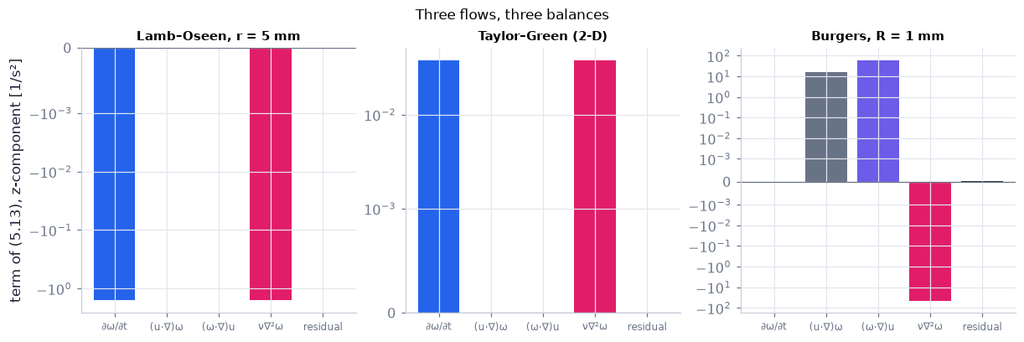

```python
names = ["lamb_oseen", "taylor_green", "burgers"]                     # three flows, three balances
labels = ["Lamb–Oseen, r = 5 mm", "Taylor–Green (2-D)", "Burgers, R = 1 mm"]
keys = ["local", "advective", "stretching_tilting", "diffusion", "residual"]   # the bars of (5.13)
cols = [COLORS["blue"], COLORS["muted"], COLORS["accent"], COLORS["rose"], COLORS["ink"]]   # house colours
fig, axs = plt.subplots(1, 3, figsize=(11, 3.6))                     # one panel per flow
for a, nm, lab in zip(axs, names, labels):
    b = ch05.vorticity_budget_preset(nm, component=2)                 # the terms at the preset probe [1/s²]
    a.bar(range(5), [b[k] for k in keys], color=cols)                # one bar per term
    a.set_yscale("symlog", linthresh=1e-3)                           # symmetric log: signs kept, sizes compressed
    a.axhline(0, color=COLORS["muted"], lw=0.8); a.set_xticks(range(5))
    a.set_xticklabels(["∂ω/∂t", "(u·∇)ω", "(ω·∇)u", "ν∇²ω", "residual"], fontsize=8)
    a.set_title(lab, fontsize=10)
axs[0].set_ylabel("term of (5.13), z-component [1/s²]")              # axis label with units
fig.suptitle("Three flows, three balances", fontsize=11)
savefig(fig, "ch05", "vorticity_terms"); plt.show()                  # save the PNG to outputs/ch05, then draw
```

**What you see.** Lamb–Oseen: only a local bar (blue) and an equal diffusion bar (rose); Taylor–Green: the same pair, no stretching bar; Burgers: no local bar — the grey advective bar (+15) equals the purple stretching bar (+62) plus the negative rose diffusion bar (−46).

**How to read it.** The y-axis is symmetric-log (a symlog axis: linear near zero, logarithmic beyond ±10⁻³), so bars of very different sizes and both signs fit. In 2-D flows vorticity is only carried and diffused; stretching needs a velocity gradient along ω (C10). The residual bars sit at the stencil-error floor (2.6×10⁻⁵ s⁻² for Burgers): $\frac{D\boldsymbol\omega}{Dt}=(\boldsymbol\omega\cdot\nabla)\mathbf u+\nu\nabla^2\boldsymbol\omega$ holds.

**What would change if…** …ν halved in Burgers: the core narrows by √2 and every bar at a fixed R changes, but advection still equals stretching plus diffusion.

> 🔁 **Tools from earlier chapters used here** (see `knowledge/primers.md`)
- **complementary error function erfc** — $\mathrm{erfc}(\eta)=\frac2{\sqrt\pi}\int_\eta^\infty e^{-s^2}ds$ (Ch. 4 P123); here we use $\mathrm{erf}=1-\mathrm{erfc}$, which runs from −1 to 1.
- **finite differences and FTCS** — replace derivatives by differences on a grid and step forward in time (forward-time, centred-space) (Ch. 1 P21).

📝 **Note.** **A sheet of vorticity diffusing** `N22` — Start with all the vorticity on a plane, $\boldsymbol\omega=\gamma\delta(y)\mathbf e_z$ (a velocity jump of γ, C14). (5.13), $\frac{D\boldsymbol\omega}{Dt}=(\boldsymbol\omega\cdot\nabla)\mathbf u+\nu\nabla^2\boldsymbol\omega$ reduces to 1-D diffusion, $\partial\omega_z/\partial t=\nu\partial^2\omega_z/\partial y^2$ (the heat equation of Ch. 1 §1.5), whose solution (the book leaves it to Exercise 5.6) is below, with velocity $u=-\frac\gamma2\,\mathrm{erf}\big(\frac{y}{2\sqrt{\nu t}}\big)$ (gloss: erf η = 1 − erfc η). The total ∫ω dy = γ never changes; the width $2\sqrt{\nu t}$ grows. **Number:** γ = 1 m/s in water, after 1 s the layer is 2 mm thick and the peak vorticity 282 s⁻¹. → Stokes' first problem (Ch. 8) is half of this; shear layers (Ch. 11).

$$ \omega_z(y,t)=\frac{\gamma}{2\sqrt{\pi\nu t}}\exp\Big\{-\frac{y^2}{4\nu t}\Big\} $$

```python
y = np.linspace(-0.05, 0.05, 4001)                                   # across the layer, ±5 cm [m]
for t in (0.1, 1.0, 10.0):                                           # three times [s]
    u, w = ch05.diffusing_vortex_sheet(y, t, 1.0, 1e-6)              # u(y, t) [m/s], ω_z(y, t) [1/s]; γ = 1 m/s, water
    print(f"t = {t:4.1f} s: ∫ω dy = {np.trapezoid(w, y):.6f} m/s, peak ω {w.max():7.1f} 1/s, u(−5 cm) = {u[0]:+.4f}, u(+5 cm) = {u[-1]:+.4f} m/s")
yf = np.linspace(-0.01, 0.01, 2001 if not FAST else 1001); dy = yf[1] - yf[0]   # the FTCS grid, ±1 cm [m]
w0 = ch05.diffusing_vortex_sheet(yf, 0.1, 1.0, 1e-6)[1]              # start from the exact profile at t = 0.1 s
dt = 0.4*dy**2/1e-6; nsteps = int(round(0.9/dt)); dt = 0.9/nsteps    # a stable time step (ν dt/dy² = 0.4), 0.9 s of diffusion
w_num = diffusion.ftcs_diffusion_1d(w0, 1e-6, dy, dt, nsteps, bc=("dirichlet", "dirichlet"), values=(0.0, 0.0), save_every=nsteps)[-1]
w_ex = ch05.diffusing_vortex_sheet(yf, 1.0, 1.0, 1e-6)[1]            # the exact profile at t = 1 s
print(f"FTCS vs exact at t = 1 s: max relative difference {np.max(np.abs(w_num - w_ex))/w_ex.max():.1e}")
```

```
t =  0.1 s: ∫ω dy = 1.000000 m/s, peak ω   892.1 1/s, u(−5 cm) = +0.5000, u(+5 cm) = -0.5000 m/s
t =  1.0 s: ∫ω dy = 1.000000 m/s, peak ω   282.1 1/s, u(−5 cm) = +0.5000, u(+5 cm) = -0.5000 m/s
t = 10.0 s: ∫ω dy = 1.000000 m/s, peak ω    89.2 1/s, u(−5 cm) = +0.5000, u(+5 cm) = -0.5000 m/s
```

```
FTCS vs exact at t = 1 s: max relative difference 7.9e-06
```

**What does the code above do?**

1. The closed form for three times: the total ∫ω dy = 1.000000 m/s = γ every time; the peak falls as $1/\sqrt t$ — 892.1, 282.1 and 89.2 s⁻¹; far away the velocity is ∓γ/2 = ∓0.5 m/s.
2. An independent finite-difference (FTCS) solution of the same diffusion equation, started from the exact profile at 0.1 s, agrees with the exact profile at 1 s to about 10⁻⁵ of the peak (8×10⁻⁶ on the full grid; 3×10⁻⁵ on the coarser grid of a FAST run).

```python
ys = np.linspace(-0.02, 0.02, 401)                                   # ±2 cm [m]


def sheet(t):                                                        # time [s] → the two profiles
    u, w = ch05.diffusing_vortex_sheet(ys, t, 1.0, 1e-6)             # γ = 1 m/s, ν = 1e-6 m²/s
    return {"ω_z [10³ 1/s]": (ys*100, w/1e3), "u [m/s]": (ys*100, u)}   # y in cm on the x-axis


fig = slider_figure(sheet, "t", np.geomspace(0.05, 10, 20 if not FAST else 10), unit="s", xlabel="y [cm]",  # precompute every slider position
                    ylabel="ω_z [10³ 1/s] (teal) · u [m/s] (orange)",
                    title="A vortex sheet diffusing: ∫ω dy = γ = 1 m/s at every t (printed above)")  # the message of the figure
recolor(fig, {"ω_z [10³ 1/s]": COLORS["teal"], "u [m/s]": COLORS["orange"]})                        # house colours by trace name
fig.show()                                                                                          # draw it (works on the web page too)
```

[interactive chart not shown]

**What you see.** A sharp teal spike that widens and sinks as t grows; an orange velocity step from +0.5 to −0.5 m/s that softens.

**How to read it.** Vorticity spreads like heat; its total — the velocity jump, γ — is conserved (the area under the teal curve does not change). The orange curve's slope at y = 0 is −ω_z there.

**What would change if…** …ν fifteen times larger (air, 1.5×10⁻⁵ m²/s, instead of water): the same shapes at one fifteenth of the time.

📝 **Note.** **Hill's spherical vortex** `N23` — is a second exact solution of (5.13), $\frac{D\boldsymbol\omega}{Dt}=(\boldsymbol\omega\cdot\nabla)\mathbf u+\nu\nabla^2\boldsymbol\omega$, steady and inviscid (the book leaves it to Exercise 5.11): inside a sphere of radius a, $\psi=\frac{Aa^4}{10}\frac{R^2}{a^2}\Big(1-\frac{R^2}{a^2}-\frac{z^2}{a^2}\Big)$ (an axisymmetric Stokes stream function, Ch. 4 §4.3) and $\boldsymbol\omega=AR\,\mathbf e_\varphi$ — ring-shaped vortex lines stretched just enough to keep ω/R constant on each streamline. The flow outside the sphere is Ch. 6's.

```python
print(ch05.vorticity_budget_preset("hill", x=0.3, z=0.2, component=1))   # ω_φ-component at (0.3, 0, 0.2): advective = stretching, residual ≈ 1e-13
```

```
{'local': 0.0, 'advective': 0.012000000000105593, 'stretching_tilting': 0.012000000000000134, 'planetary': 0.0, 'baroclinic': 0.0, 'diffusion': 0.0, 'residual': 1.0545904427505803e-13}
```

*↪ N21 → C10:* Burgers' vortex (an exercise attached to this section) is taught with stretching in C10, where its stretching–diffusion balance is the point (D18).

**Helmholtz's first theorem from the field equation (C05, second proof).** With ν = 0, (5.13), $\frac{D\boldsymbol\omega}{Dt}=(\boldsymbol\omega\cdot\nabla)\mathbf u+\nu\nabla^2\boldsymbol\omega$ reads $D\boldsymbol\omega/Dt=(\boldsymbol\omega\cdot\nabla)\mathbf u=\mathsf G\boldsymbol\omega$ — the same linear equation as a material line element, $D(\delta\mathbf x)/Dt=\mathsf G\,\delta\mathbf x$ (Ch. 3 P99). Start δx along ω and they stay parallel, with |ω|/|δx| constant (Cauchy's frozen-in solution): vortex lines are material. `frozen_in_check` integrates the particle, δx and ω together along one path.

```python
u_abc = ch05.abc_flow()                                              # a steady Euler flow with ω = u (inviscid)
fr = ch05.frozen_in_check(u_abc, np.zeros(3), 1e-3*u_abc(np.zeros(3), 0.0), (0, 5), np.linspace(0, 5, 11))   # δx starts along ω
print(f"inviscid ABC: max angle(δx, ω) {np.max(fr['angle']):.1e} rad, spread of |ω|/|δx| {np.ptp(fr['ratio']):.1e}")
fv = ch05.frozen_in_check(u_b, np.array([1e-3, 0, 1e-3]), np.array([0, 0, 1e-6]), (0, 2), np.linspace(0, 2, 5), nu=1e-6)   # Burgers, ν ≠ 0
print("viscous Burgers: |ω|/|δx| =", np.round(fv["ratio"], 4))       # falls from 1: diffusion unhooks ω from the fluid
```

```
inviscid ABC: max angle(δx, ω) 6.7e-13 rad, spread of |ω|/|δx| 1.0e-15
```

```
viscous Burgers: |ω|/|δx| = [1.     0.6692 0.4309 0.271  0.168 ]
```

**What does the code above do?**

1. In the inviscid ABC flow δx stays parallel to ω (angle ~10⁻¹³ rad) and |ω|/|δx| stays 1 to round-off — vortex lines are material.
2. In the viscous Burgers vortex δx and ω both stay along the axis (angle 0 by symmetry), but |ω|/|δx| falls from 1 to 0.17 in 2 s: the element keeps being stretched while the vorticity at the particle is held by the stretching–diffusion balance — viscosity lets vorticity move relative to the fluid.

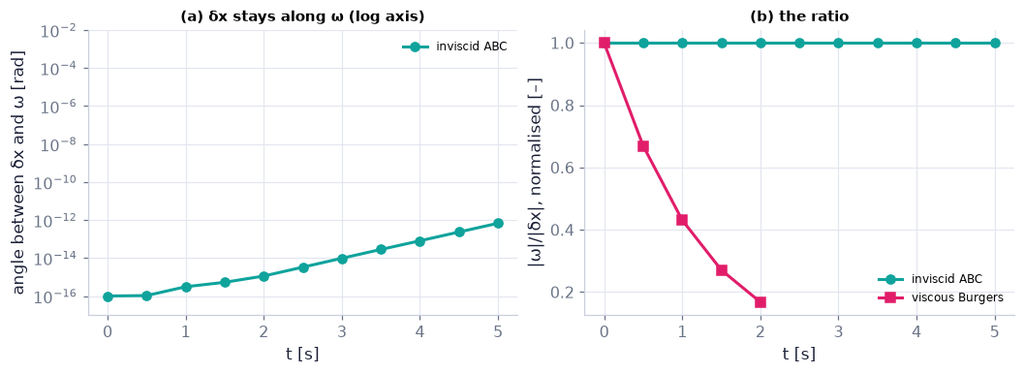

```python
fig, (a, b) = plt.subplots(1, 2, figsize=(9.5, 3.4))                  # angle | ratio
a.semilogy(fr["t"], np.maximum(fr["angle"], 1e-16), color=COLORS["teal"], marker="o", label="inviscid ABC")   # ~1e-13
a.set_xlabel("t [s]"); a.set_ylabel("angle between δx and ω [rad]"); a.set_ylim(1e-17, 1e-2); a.legend(fontsize=8)
a.set_title("(a) δx stays along ω (log axis)", fontsize=10)
b.plot(fr["t"], fr["ratio"], color=COLORS["teal"], marker="o", label="inviscid ABC")          # flat at 1
b.plot(fv["t"], fv["ratio"], color=COLORS["rose"], marker="s", label="viscous Burgers")       # drifts
b.set_xlabel("t [s]"); b.set_ylabel("|ω|/|δx|, normalised [–]"); b.legend(fontsize=8); b.set_title("(b) the ratio", fontsize=10)
plt.show()
```

**What you see.** Left, the inviscid angle sits at the round-off floor (~10⁻¹³ rad); right, the teal ratio stays exactly 1 while the rose (viscous) ratio falls to about 0.17.

**How to read it.** Inviscid: vorticity and a material element obey the same equation, so they stay locked together (Helmholtz 1 and 4). Viscous: diffusion moves vorticity relative to the fluid, so the lock breaks.

**What would change if…** …ν → 10ν in Burgers: the core widens (√(4ν/α)) and the ratio falls away from 1 even faster in the first instants.

> ⚠️ **Common confusion:** "(5.13), $\frac{D\boldsymbol\omega}{Dt}=(\boldsymbol\omega\cdot\nabla)\mathbf u+\nu\nabla^2\boldsymbol\omega$ is linear in ω." It only looks linear: u is itself determined by ω (Biot–Savart, C07), so the advective term $(\mathbf u\cdot\nabla)\boldsymbol\omega$ and the stretching term $(\boldsymbol\omega\cdot\nabla)\mathbf u$ are both quadratic in the vorticity.

🎮 **How can a flow spin fluid faster without a torque?** (embedded after C10 in §5.6) steps through D09 in its Derivation tab.

**What would change if…** …the density varied or the frame rotated? The pressure curl would no longer vanish (a baroclinic source, C04) and the Coriolis term would add the planet's vorticity to the stretching term — $\frac{D\boldsymbol\omega}{Dt}=(\boldsymbol\omega+2\boldsymbol\Omega)\cdot\nabla\mathbf u+\frac1{\rho^2}\nabla\rho\times\nabla p+\nu\nabla^2\boldsymbol\omega$ *(5.30)*, C09.

## 5.5 Velocity Induced by a Vortex Filament: Law of Biot and Savart

**What is this section about?** If you know the vorticity everywhere, you know the velocity everywhere (up to a potential flow). This section derives the formula — Biot–Savart, the same law that gives a magnetic field from an electric current — and its working form for thin vortex filaments. The book's printed (5.14), $\mathbf u(\mathbf x,t)=+\frac1{4\pi}\int_{V'}\frac{\nabla'\times\boldsymbol\omega(\mathbf x',t)}{\lvert\mathbf x-\mathbf x'\rvert}d^3x'\ \ (\text{sign corrected; the book prints }-\tfrac1{4\pi})$ carries a sign slip; we derive the correct sign.

### 🧩 Biot–Savart: velocity from vorticity `C07`

*The question:* A vortex spins in one corner of a pond. Water on the far side moves too, although nothing touches it there. Given where the vorticity is, is the velocity everywhere decided?

*In one line:* $\mathbf u(\mathbf x,t)=\frac1{4\pi}\int_{V'}\frac{\boldsymbol\omega(\mathbf x',t)\times(\mathbf x-\mathbf x')}{\lvert\mathbf x-\mathbf x'\rvert^3}d^3x'$ *(5.16)*

#### The problem in plain words

Aerodynamicists replace a wing by the vortices it sheds and compute the downwash they induce; oceanographers invert a map of vorticity for the currents; vortex methods in CFD move blobs of vorticity with the velocity they induce on each other. All of them need one formula: velocity from vorticity.

#### The idea

```
w = curl u,  div u = 0   --curl again-->   lap(u) = -curl(w)          (a Poisson equation: like gravity or electrostatics)
point-source solution of lap: -1/(4 pi r)   --add up-->   u = (1/4pi) Int (curl' w)/r d3x'      (5.14), sign corrected
move the curl off w (product rule + Gauss)  -->  u = (1/4pi) Int w x (x-x')/r^3 d3x'           (5.16) = current -> magnetic field
```

*The numbered equations in the sketch:* $\mathbf u(\mathbf x,t)=+\frac1{4\pi}\int_{V'}\frac{\nabla'\times\boldsymbol\omega(\mathbf x',t)}{\lvert\mathbf x-\mathbf x'\rvert}d^3x'\ \ (\text{sign corrected; the book prints }-\tfrac1{4\pi})$ *(5.14)* · $\mathbf u(\mathbf x,t)=\frac1{4\pi}\int_{V'}\frac{\boldsymbol\omega(\mathbf x',t)\times(\mathbf x-\mathbf x')}{\lvert\mathbf x-\mathbf x'\rvert^3}d^3x'$ *(5.16)*

> 📎 **Primer — Poisson equation and Green's function.** `P139` · A Poisson equation ∇²φ = q asks for the field produced by a source density q (gravity from mass, voltage from charge). Its building block is the response to one point source, the Green's function: in 3-D, $G=-1/(4\pi\lvert\mathbf x-\mathbf x'\rvert)$ solves $\nabla^2G=\delta(\mathbf x-\mathbf x')$, the Dirac delta being a unit source concentrated at one point (Ch. 3 met it as a gloss). Because the equation is linear, the response to any q is the sum of point responses, $\phi(\mathbf x)=\int G(\mathbf x,\mathbf x')q(\mathbf x')d^3x'$ (superposition).

```python
x, y, z = sp.symbols('x y z')                                   # a point in space; the source sits at the origin
r = sp.sqrt(x**2 + y**2 + z**2)                                 # distance from the source [m]
G = -1/(4*sp.pi*r)                                              # the Green's function of ∇²
print(sp.simplify(sum(sp.diff(G, v, 2) for v in (x, y, z))))    # ∇²G = 0 away from the source
```

```
0
```

> 📎 **Primer — gradient of 1/distance with respect to the source point.** `P140` · With x fixed and the source point x′ moving, $\nabla'(1/\lvert\mathbf x-\mathbf x'\rvert)=+(\mathbf x-\mathbf x')/\lvert\mathbf x-\mathbf x'\rvert^3$ — it points from the source toward the field point. Differentiating with respect to x instead flips the sign; the book's two sign slips in §5.5 are exactly this trap.

```python
X = sp.symbols('x y z'); Xp = sp.symbols('xp yp zp')            # field point x, source point x′
d = [a - b for a, b in zip(X, Xp)]; r = sp.sqrt(sum(di**2 for di in d))   # x − x′ and its length
grad_p = [sp.diff(1/r, v) for v in Xp]                          # ∇′(1/r): derivatives with respect to x′
print([sp.simplify(g - di/r**3) for g, di in zip(grad_p, d)])   # [0, 0, 0]: ∇′(1/r) = +(x − x′)/r³
```

```
[0, 0, 0]
```

> 📎 **Primer — curl of a product (product rule).** `P141` · For a scalar f and a vector A, $\nabla\times(f\mathbf A)=f\nabla\times\mathbf A+\nabla f\times\mathbf A$ — the product rule, with the order of the cross product kept. D11 uses it to move the curl off ω. (Gloss: the cross product is antisymmetric, **a** × **b** = −**b** × **a**, so reordering it flips the sign.)

```python
x, y, z = sp.symbols('x y z'); f = sp.Function('f')(x, y, z)          # a generic scalar field
A = sp.Matrix([sp.Function(n)(x, y, z) for n in 'PQR'])              # a generic vector field
curl = lambda V: sp.Matrix([sp.diff(V[2], y) - sp.diff(V[1], z), sp.diff(V[0], z) - sp.diff(V[2], x), sp.diff(V[1], x) - sp.diff(V[0], y)])   # ∇×
grad = sp.Matrix([sp.diff(f, v) for v in (x, y, z)])                  # ∇f
print(sp.simplify(curl(f*A) - f*curl(A) - grad.cross(A)))             # zero vector: the product rule holds
```

```
Matrix([[0], [0], [0]])
```

> 🔁 **Tools from earlier chapters used here** (see `knowledge/primers.md`)
- **curl of a curl identity** — $\nabla\times(\nabla\times\mathbf u)=\nabla(\nabla\cdot\mathbf u)-\nabla^2\mathbf u$ (Ch. 4 P122; the book's (B.3.13)).

📝 **Note.** **Velocity obeys a Poisson equation** `N24` — For incompressible flow the curl of the vorticity is minus the Laplacian of the velocity (the curl-of-curl identity, Ch. 4 P122). On a periodic box the Poisson equation is solved in one line with Fourier modes — the next primer and cell. → Vorticity–stream-function CFD (Ch. 10), PV inversion (Ch. 13).

$$ \nabla\times\boldsymbol\omega=\nabla\times(\nabla\times\mathbf u)=\nabla(\nabla\cdot\mathbf u)-\nabla^2\mathbf u=-\nabla^2\mathbf u $$

> 📎 **Primer — Fourier modes and the FFT Poisson solver.** `P142` · On a periodic box every smooth field is a sum of waves $e^{i\mathbf k\cdot\mathbf x}$; a derivative ∂/∂x multiplies a wave by $ik_x$ and ∇² by $-\lvert\mathbf k\rvert^2$. So ∇²ψ = −ω becomes $\hat\psi=\hat\omega/\lvert\mathbf k\rvert^2$ for each wave (k = 0 is the mean, set to 0). `numpy.fft.fft2` finds the waves, `ifft2` adds them back.

```python
n, L = 32, 2*np.pi; x = np.arange(n)*L/n; X, Y = np.meshgrid(x, x)   # a periodic 32 × 32 grid on [0, 2π)² [m]
w = 2*np.sin(X)*np.sin(Y)                                            # vorticity of ψ = sin x sin y [1/s]
k = np.fft.fftfreq(n, L/n)*2*np.pi; KX, KY = np.meshgrid(k, k); K2 = KX**2 + KY**2; K2[0, 0] = 1   # wavenumbers; avoid 0/0
psi = np.real(np.fft.ifft2(np.fft.fft2(w)/K2))                       # ψ̂ = ω̂/k², back to the grid
print(np.max(abs(psi - np.sin(X)*np.sin(Y))))                        # ~1e-15: the exact stream function
```

```
5.551115123125783e-16
```

```python
U = ch05.velocity_from_vorticity_fft(w, 2*np.pi)                     # the library: (u, v) on the same grid [m/s]
print(np.max(abs(U[0] - np.sin(X)*np.cos(Y))), np.max(abs(U[1] + np.cos(X)*np.sin(Y))))   # cellular flow recovered to round-off
```

```
5.551115123125783e-16 5.551115123125783e-16
```

#### 🧮 Derivation — Velocity from vorticity: ∇×ω = −∇²u and its Green's-function solution (5.14), with the correct sign `D10` (Eq. 5.14)

**What we want to show.** Given the vorticity everywhere, find the velocity it induces — an explicit integral. The book prints the answer, Eq. 5.14, as $\mathbf u=-\frac1{4\pi}\int_{V'}\frac{\nabla'\times\boldsymbol\omega}{\lvert\mathbf x-\mathbf x'\rvert}d^3x'$ — with a wrong sign — and leaves the proof to "Exercise 5.8" (meaning 5.9); we derive it.

**Assumptions.** Incompressible (step 3); unbounded domain, u → 0 at infinity (steps 9, 12).

**The plan.**

1. Take the curl of ω and use the curl-of-curl identity to get a Poisson equation for u.
2. Build the Green's function of ∇².
3. Superpose point sources.
4. Track the signs.

**Tools we use** (each explained before this point): curl of a curl (ch04 P122, reminder) · Poisson equation and Green's function (primer in C07) · Gauss' theorem on a small sphere (2.30), $\int_V\nabla\cdot\mathbf Q\,dV=\int_A\mathbf Q\cdot\mathbf n\,dA$ (Ch. 2 §2.12) · superposition for a linear equation (gloss).

**We start from**

$$ \boldsymbol\omega=\nabla\times\mathbf u\ \text{,}\ \nabla\cdot\mathbf u=0\ \text{, all space, u → 0 far away} $$

*In words:* an incompressible flow whose vorticity we know.

**Step 1 of 12 — Take the curl of the vorticity.**

$$ \nabla\times\boldsymbol\omega=\nabla\times(\nabla\times\mathbf u) $$

- *Why we can do this:* We want an equation that contains u and the known ω only; the curl of ω brings back second derivatives of u.
- *In words:* Look at how the vorticity itself curls.

**Step 2 of 12 — Apply the curl-of-curl identity.**

$$ \nabla\times(\nabla\times\mathbf u)=\nabla(\nabla\cdot\mathbf u)-\nabla^2\mathbf u $$

- *Why we can do this:* Identity (B.3.13), proved with ε–δ in Ch. 4 (P122).
- *In words:* A curl of a curl is a gradient of divergence minus a Laplacian.

**Step 3 of 12 — Use incompressibility.**

$$ \nabla^2\mathbf u=-\nabla\times\boldsymbol\omega $$

- *Why we can do this:* ∇·u = 0 removes the gradient term. This is the book's line before (5.14), $\mathbf u(\mathbf x,t)=+\frac1{4\pi}\int_{V'}\frac{\nabla'\times\boldsymbol\omega(\mathbf x',t)}{\lvert\mathbf x-\mathbf x'\rvert}d^3x'\ \ (\text{sign corrected; the book prints }-\tfrac1{4\pi})$.
- *In words:* The velocity obeys a Poisson equation whose source is the curl of the vorticity.

**Step 4 of 12 — Treat each component separately.**

$$ \nabla^2u_i=q_i,\qquad q_i=-(\nabla\times\boldsymbol\omega)_i $$

- *Why we can do this:* In Cartesian components the vector Laplacian is three scalar Laplacians; three independent Poisson equations.
- *In words:* Three copies of one scalar problem.

**Step 5 of 12 — Look for a point-source solution.**

$$ \nabla^2G(\mathbf x,\mathbf x')=\delta(\mathbf x-\mathbf x') $$

- *Why we can do this:* The Green's-function idea (primer): solve for one concentrated unit source first, then add sources up.
- *In words:* How does the field respond to a single pinpoint source?

**Step 6 of 12 — Check 1/r is harmonic off the source.**

$$ \nabla^2\frac{1}{r}=0\quad(r=\lvert\mathbf x-\mathbf x'\rvert>0) $$

- *Why we can do this:* In spherical coordinates ∇²f = r⁻²(r²f′)′, and r²·(−1/r²) is constant (sympy check).
- *In words:* Away from the point, 1/r has no sources.

**Step 7 of 12 — Measure the source strength of 1/r.**

$$ \oint_{\lvert\mathbf x-\mathbf x'\rvert=\epsilon}\nabla\frac1r\cdot\mathbf n\,dA=-\frac{1}{\epsilon^2}\,4\pi\epsilon^2=-4\pi\ \Rightarrow\ \nabla^2\frac1r=-4\pi\,\delta $$

- *Why we can do this:* Gauss (2.30), $\int_V\nabla\cdot\mathbf Q\,dV=\int_A\mathbf Q\cdot\mathbf n\,dA$ on a small sphere: the flux of ∇(1/r) is −4π for every radius, so all of 1/r's "source" sits at the centre.
- *In words:* 1/r is the field of a point source of strength −4π.

**Step 8 of 12 — Normalise to a unit source.**

$$ G(\mathbf x,\mathbf x')=-\frac{1}{4\pi\lvert\mathbf x-\mathbf x'\rvert} $$

- *Why we can do this:* Divide step 7 by −4π: the equation is linear, so scaling 1/r scales its point source by the same factor, and we want a source of strength exactly 1.
- *In words:* Minus one over 4π r is the response to a unit source.

**Step 9 of 12 — Superpose all the sources.**

$$ u_i(\mathbf x)=\int_{V'}G(\mathbf x,\mathbf x')\,q_i(\mathbf x')\,d^3x' $$

- *Why we can do this:* The Poisson equation is linear, so the response to many sources is the sum of the responses (gloss); with u → 0 at infinity the solution is unique.
- *In words:* Add up every point's contribution.

**Step 10 of 12 — Insert G and the source.**

$$ \mathbf u(\mathbf x)=\int_{V'}\Big(-\frac{1}{4\pi\lvert\mathbf x-\mathbf x'\rvert}\Big)\big(-\nabla'\times\boldsymbol\omega(\mathbf x')\big)d^3x' $$

- *Why we can do this:* Steps 4 and 8. ∇′ differentiates with respect to the source point x′.
- *In words:* Two minus signs appear.

**Step 11 of 12 — Cancel the two minus signs.**

$$ \mathbf u(\mathbf x,t)=+\frac{1}{4\pi}\int_{V'}\frac{\nabla'\times\boldsymbol\omega(\mathbf x',t)}{\lvert\mathbf x-\mathbf x'\rvert}\,d^3x' $$

- *Why we can do this:* (−)(−) = +. **The book prints −1/(4π) in (5.14), $\mathbf u(\mathbf x,t)=+\frac1{4\pi}\int_{V'}\frac{\nabla'\times\boldsymbol\omega(\mathbf x',t)}{\lvert\mathbf x-\mathbf x'\rvert}d^3x'\ \ (\text{sign corrected; the book prints }-\tfrac1{4\pi})$: a sign slip** — with it a vortex would swirl backwards (code).
- *In words:* Vorticity's curl, spread out as 1/distance, gives the velocity.

**Step 12 of 12 — Note what may be added.**

$$ \mathbf u=\mathbf u_\omega+\nabla\phi,\qquad\nabla^2\phi=0 $$

- *Why we can do this:* Any irrotational, divergence-free flow adds nothing to ∇×ω, so the integral gives only the "vorticity-induced portion"; far-field decay removes the rest here (Ch. 6 adds it back).
- *In words:* Vorticity fixes the velocity up to a potential flow.

**Result**

$$ \begin{array}{l}\mathbf u(\mathbf x,t)=\frac{1}{4\pi}\int_{V'}\frac{\nabla'\times\boldsymbol\omega(\mathbf x',t)}{\lvert\mathbf x-\mathbf x'\rvert}\,d^3x'\ \text{— the corrected (5.14), which} \\ \text{the book prints as}\ \mathbf u(\mathbf x,t)=-\frac{1}{4\pi}\int_{V'}\frac{1}{\lvert\mathbf x-\mathbf x'\rvert}(\nabla'\times\boldsymbol\omega(\mathbf x',t))d^3x'\end{array} $$

*In words:* the velocity at x is a 1/distance-weighted sum of the curl of the vorticity everywhere.

**What it means.** Vorticity is the "cause" of velocity in the sense a current causes a magnetic field: know ω and you know u (plus a potential flow). It is the basis of vortex methods (Ch. 10), lifting-line theory (Ch. 14) and potential-vorticity inversion (Ch. 13).

**Check it.** Units: [∇′×ω] = 1/(m s) and d³x′/|x − x′| = m², so u is in m/s ✓. Gaussian tube (Γ = 1 m²/s, σ_c = 0.1 m) at r = 0.5 m: the + sign gives u_θ = +0.3088 m/s — the finite tube of length 4 m, whose exact value is 0.308838 m/s (the infinite line would give Γ/2πr = 0.318310) — and the printed sign −0.3088 m/s ✓ (the sympy cell below and the sign-test cell after note N25). **sympy check (the cell right after this derivation, every line commented):** re-run steps 2, 6, 7 and 11: (a) the curl-of-curl identity for a generic field; (b) ∇²(1/r) = 0 for r > 0; (c) the flux of ∇(1/r) through a sphere of radius ε equals −4π for every ε (integrate in spherical coordinates); (d) that G = −1/(4πr) solves ∇²G = 0 off the source with unit flux; then numerically apply `velocity_from_curl_omega(sign=±1)` to the Gaussian tube and compare with Γ/2πr.

```python
x, y, z = sp.symbols('x y z', real=True)                             # a field point; the source sits at the origin
X = (x, y, z)                                                        # the coordinates as a tuple
A, B, C = [sp.Function(n)(x, y, z) for n in 'ABC']                   # a generic velocity field for step 2
U = sp.Matrix([A, B, C])
curl = lambda V: sp.Matrix([sp.diff(V[2], y) - sp.diff(V[1], z), sp.diff(V[0], z) - sp.diff(V[2], x), sp.diff(V[1], x) - sp.diff(V[0], y)])   # ∇×
grad = lambda f: sp.Matrix([sp.diff(f, v) for v in X])               # ∇
div = lambda V: sum(sp.diff(V[i], X[i]) for i in range(3))           # ∇·
lapv = lambda V: sp.Matrix([sum(sp.diff(V[i], v, 2) for v in X) for i in range(3)])   # vector Laplacian (Cartesian)
print("step 2, curl curl u − [∇(∇·u) − ∇²u]:", sp.simplify(curl(curl(U)) - (grad(div(U)) - lapv(U))).T)   # zero vector
r = sp.sqrt(x**2 + y**2 + z**2)                                      # distance from the source [m]
print("step 6, ∇²(1/r) for r > 0:", sp.simplify(sum(sp.diff(1/r, v, 2) for v in X)))     # 0
rr, eps, th, ph = sp.symbols('r epsilon theta phi', positive=True)   # radius, sphere radius, sphere angles
dfdr = sp.diff(1/rr, rr).subs(rr, eps)                               # radial derivative of 1/r on the sphere: −1/ε²
flux = sp.integrate(sp.integrate(dfdr*eps**2*sp.sin(th), (th, 0, sp.pi)), (ph, 0, 2*sp.pi))   # step 7: ∮∇(1/r)·n dA
print("step 7, flux of ∇(1/r) through a sphere of radius ε:", flux)  # −4π, whatever ε is
print("step 8, flux of ∇G with G = −1/(4πr):", sp.simplify(flux*(-1/(4*sp.pi))))           # 1: a unit source
F = ch05.gaussian_tube_fields(Gamma=1.0, sigma=0.1, L=4.0)           # step 11 with numbers: a smooth tube of length 4 m
nodes, weights = ch05.cylinder_quadrature(F["bounds"]["radius"], F["bounds"]["z0"], F["bounds"]["z1"], nr=24, nphi=32, nz=24)
for s in (+1, -1):                                                   # the corrected sign, then the book's printed sign
    print(f"step 11, sign {s:+d}: u_θ(0.5 m) = {ch05.velocity_from_curl_omega(F['curl_omega'], np.array([0.5, 0, 0]), nodes, weights, sign=s)[1]:+.4f} m/s")
print(f"exact for this finite tube: {F['u_theta_reference'](0.5):.6f} m/s (counterclockwise, like the vortex)")
```

```
step 2, curl curl u − [∇(∇·u) − ∇²u]:
```

```
 Matrix([[0, 0, 0]])
step 6, ∇²(1/r) for r > 0: 0
```

```
step 7, flux of ∇(1/r) through a sphere of radius ε: -4*pi
step 8, flux of ∇G with G = −1/(4πr): 1
step 11, sign +1: u_θ(0.5 m) = +0.3088 m/s
step 11, sign -1: u_θ(0.5 m) = -0.3088 m/s
exact for this finite tube: 0.308838 m/s (counterclockwise, like the vortex)
```

> ⚠️ **Common confusion (traps in `D10`):** Taking G = +1/(4πr) (then ∇²G = −δ). Letting ∇ act on x instead of x′ in the source. Trusting the printed sign.

📝 **Note.** **(5.14) with its sign corrected** `N25` — D10's result is below. ⚠️ **The book prints** $\mathbf u(\mathbf x,t)=-\frac{1}{4\pi}\int_{V'}\frac{1}{\lvert\mathbf x-\mathbf x'\rvert}(\nabla'\times\boldsymbol\omega(\mathbf x',t))d^3x'$ **(5.14) with −1/(4π); the correct factor is +1/(4π).** It also cites "Exercise 5.8" for the proof; the Green's-function exercise is 5.9. The code below computes both signs on a smooth vortex tube — only one of them spins the right way.

$$ \mathbf u(\mathbf x,t)=\frac1{4\pi}\int_{V'}\frac{\nabla'\times\boldsymbol\omega(\mathbf x',t)}{\lvert\mathbf x-\mathbf x'\rvert}d^3x' \qquad \text{(5.14)} $$

> 📎 **Primer — Gauss–Legendre quadrature in 3-D and a smoothed kernel.** `P143` · Gauss–Legendre picks n nodes and weights per axis so that polynomials up to degree 2n − 1 integrate exactly; a box uses all n³ combinations (weights multiply). `ch05.cylinder_quadrature` does the same on a cylinder: Gauss–Legendre in R (with the weight R) and z, equal steps in φ. Near a singular kernel like 1/r³ we replace r² by r² + ε² (a tiny smoothing length) so no node ever divides by zero.

```python
from fluidpy.core.integral_theorems import gauss_legendre_nodes     # 1-D nodes and weights on an interval
x, w = gauss_legendre_nodes(0.0, 1.0, 4)                             # 4 nodes on [0, 1]
X, Y, Z = np.meshgrid(x, x, x, indexing='ij'); W = w[:, None, None]*w[None, :, None]*w[None, None, :]   # the 4³ box rule
print(np.sum(W*X**3*Y**2*Z), 1/4*1/3*1/2)                            # exact for a polynomial: 0.041667 twice
```

```
0.041666666666666644 0.041666666666666664
```

**The sign test:** a straight Gaussian vortex tube (Γ = 1 m²/s, core σ_c = 0.1 m, length 4 m, flat ends normal to ω), velocity at 0.5 m from its axis in its mid-plane, by (5.14), $\mathbf u(\mathbf x,t)=+\frac1{4\pi}\int_{V'}\frac{\nabla'\times\boldsymbol\omega(\mathbf x',t)}{\lvert\mathbf x-\mathbf x'\rvert}d^3x'\ \ (\text{sign corrected; the book prints }-\tfrac1{4\pi})$ with both signs and by (5.16), $\mathbf u(\mathbf x,t)=\frac1{4\pi}\int_{V'}\frac{\boldsymbol\omega(\mathbf x',t)\times(\mathbf x-\mathbf x')}{\lvert\mathbf x-\mathbf x'\rvert^3}d^3x'$.

```python
F = ch05.gaussian_tube_fields(Gamma=1.0, sigma=0.1, L=4.0)           # ω and ∇×ω of the tube as functions; its bounding cylinder
nq = (32, 48, 40) if not FAST else (24, 32, 24)                       # Gauss nodes in R, φ, z
nodes, weights = ch05.cylinder_quadrature(F["bounds"]["radius"], F["bounds"]["z0"], F["bounds"]["z1"], nr=nq[0], nphi=nq[1], nz=nq[2])
xp = np.array([0.5, 0.0, 0.0])                                       # the field point [m]
for s in (+1, -1):                                                   # corrected (+1/4π) and printed (−1/4π) forms of (5.14)
    print(f"(5.14) with sign {s:+d}: u_y = {ch05.velocity_from_curl_omega(F['curl_omega'], xp, nodes, weights, sign=s)[1]:+.6f} m/s")
print(f"(5.16) Biot–Savart:    u_y = {ch05.biot_savart_volume(F['omega'], xp, nodes, weights)[1]:+.6f} m/s")
print(f"exact, this 4 m tube:  u_θ = {F['u_theta_reference'](0.5):.6f} m/s;  infinite line Γ/2πr = {F['u_theta_infinite'](0.5):.6f} m/s")
```

```
(5.14) with sign +1: u_y = +0.308837 m/s
```

```
(5.14) with sign -1: u_y = -0.308837 m/s
(5.16) Biot–Savart:    u_y = +0.308837 m/s
exact, this 4 m tube:  u_θ = 0.308838 m/s;  infinite line Γ/2πr = 0.318310 m/s
```

**What does the code above do?**

1. A smooth vortex tube, its vorticity and the curl of its vorticity as callables, and Gauss nodes on a cylinder round it.
2. (5.14), $\mathbf u(\mathbf x,t)=+\frac1{4\pi}\int_{V'}\frac{\nabla'\times\boldsymbol\omega(\mathbf x',t)}{\lvert\mathbf x-\mathbf x'\rvert}d^3x'\ \ (\text{sign corrected; the book prints }-\tfrac1{4\pi})$ with both signs: the corrected +1/(4π) gives +0.3088 m/s (counterclockwise, the way the vortex turns); the book's −1/(4π) gives −0.3088 m/s — the swirl backwards.
3. (5.16), $\mathbf u(\mathbf x,t)=\frac1{4\pi}\int_{V'}\frac{\boldsymbol\omega(\mathbf x',t)\times(\mathbf x-\mathbf x')}{\lvert\mathbf x-\mathbf x'\rvert^3}d^3x'$, Biot–Savart, gives the same +0.3088 m/s: D11 turns one into the other.
4. The exact value for this **finite** tube is 0.308838 m/s (the segment law of D13 applied to the core); an infinitely long line would give Γ(1 − e⁻²⁵)/2πr = 0.318310 m/s — the 3 % gap is the tube's finite length, not an error.

#### 🧮 Derivation — From (5.14) to Biot–Savart: product rule, Gauss in curl form (5.15), a tube-aligned volume → (5.16) `D11` (Eq. 5.16)

**What we want to show.** Rewrite the corrected (5.14), $\mathbf u(\mathbf x,t)=+\frac1{4\pi}\int_{V'}\frac{\nabla'\times\boldsymbol\omega(\mathbf x',t)}{\lvert\mathbf x-\mathbf x'\rvert}d^3x'\ \ (\text{sign corrected; the book prints }-\tfrac1{4\pi})$ so that ω itself, not its curl, appears in the integrand — the Biot–Savart law — and see why a volume hugging the vortex makes the leftover surface term vanish.

**Assumptions.** ω smooth inside V′ (steps 2, 8); V′ built as in Fig. 5.8 (steps 10–11).

**The plan.**

1. Move the curl off ω with the product rule.
2. Compute ∇′(1/|x − x′|) carefully.
3. Turn the pure-curl integral into a surface integral (5.15), $\int_{V'}\nabla'\times\Big(\frac{\boldsymbol\omega}{\lvert\mathbf x-\mathbf x'\rvert}\Big)d^3x'=\int_{A'}\frac{\mathbf n\times\boldsymbol\omega}{\lvert\mathbf x-\mathbf x'\rvert}d^2x'$.
4. Choose V′ so the surface term vanishes.

**Tools we use** (each explained before this point): Product rule for a curl (primer in C07) · gradient of 1/|x − x′| with respect to x′ (primer in C07) · cross-product antisymmetry (gloss) · Gauss' theorem (2.30), $\int_V\nabla\cdot\mathbf Q\,dV=\int_A\mathbf Q\cdot\mathbf n\,dA$ applied component by component with ε_kij (Ch. 2 §2.7, §2.12).

**We start from**

$$ \begin{array}{l}\mathbf u(\mathbf x,t)=\frac1{4\pi}\int_{V'}\frac{\nabla'\times\boldsymbol\omega(\mathbf x',t)}{\lvert\mathbf x-\mathbf x'\rvert}d^3x'\ \text{(D10's result, the corrected} \\ \text{(5.14))}\end{array} $$

*In words:* the velocity as a weighted sum of the curl of the vorticity.

**Step 1 of 12 — Name the kernel.**

$$ \phi(\mathbf x')=\frac{1}{\lvert\mathbf x-\mathbf x'\rvert} $$

- *Why we can do this:* x is fixed while we integrate over x′, so the kernel is a scalar field of x′.
- *In words:* Call the 1/distance weight φ.

**Step 2 of 12 — Apply the product rule for a curl.**

$$ \nabla'\times(\phi\,\boldsymbol\omega)=\phi\,\nabla'\times\boldsymbol\omega+\nabla'\phi\times\boldsymbol\omega $$

- *Why we can do this:* ∇×(fA) = f∇×A + ∇f × A (primer), with ∇′. We want φ∇′×ω, which is our integrand.
- *In words:* Curling a product gives two pieces.

**Step 3 of 12 — Solve for the integrand.**

$$ \phi\,\nabla'\times\boldsymbol\omega=\nabla'\times(\phi\,\boldsymbol\omega)-\nabla'\phi\times\boldsymbol\omega $$

- *Why we can do this:* Move one term across. This is the book's first line of the rewrite, which it prints correctly.
- *In words:* The integrand = a pure curl minus a leftover.

**Step 4 of 12 — Differentiate the kernel with respect to x′.**

$$ \nabla'\frac{1}{\lvert\mathbf x-\mathbf x'\rvert}=+\frac{\mathbf x-\mathbf x'}{\lvert\mathbf x-\mathbf x'\rvert^3} $$

- *Why we can do this:* Chain rule: ∂′_i|x − x′| = −(x_i − x′_i)/|x − x′|, and d(1/s)/ds = −1/s²; two minus signs (primer, sympy).
- *In words:* The kernel grows toward the field point.

**Step 5 of 12 — Substitute and reorder the cross product.**

$$ -\nabla'\phi\times\boldsymbol\omega=-\frac{\mathbf x-\mathbf x'}{\lvert\mathbf x-\mathbf x'\rvert^3}\times\boldsymbol\omega=\boldsymbol\omega\times\frac{\mathbf x-\mathbf x'}{\lvert\mathbf x-\mathbf x'\rvert^3} $$

- *Why we can do this:* a × b = −b × a (gloss). **The book prints "+((x − x′)/|x − x′|³) × ω" here — a second sign slip that cancels the one in (5.14), $\mathbf u(\mathbf x,t)=+\frac1{4\pi}\int_{V'}\frac{\nabla'\times\boldsymbol\omega(\mathbf x',t)}{\lvert\mathbf x-\mathbf x'\rvert}d^3x'\ \ (\text{sign corrected; the book prints }-\tfrac1{4\pi})$.**
- *In words:* The leftover is ω crossed into the direction of the field point.

**Step 6 of 12 — Split u into two integrals.**

$$ \mathbf u=\frac1{4\pi}\int_{V'}\nabla'\times\Big(\frac{\boldsymbol\omega}{\lvert\mathbf x-\mathbf x'\rvert}\Big)d^3x'+\frac1{4\pi}\int_{V'}\frac{\boldsymbol\omega\times(\mathbf x-\mathbf x')}{\lvert\mathbf x-\mathbf x'\rvert^3}d^3x' $$

- *Why we can do this:* Insert steps 3 and 5 into D10's result; linearity. (The book's first integral carries the wrong sign; it vanishes below, so no harm.)
- *In words:* A pure-curl part and the Biot–Savart part.

**Step 7 of 12 — Write the curl in index notation.**

$$ \Big[\nabla'\times\Big(\frac{\boldsymbol\omega}{\lvert\mathbf x-\mathbf x'\rvert}\Big)\Big]_k=\varepsilon_{kij}\frac{\partial}{\partial x'_i}\Big(\frac{\omega_j}{\lvert\mathbf x-\mathbf x'\rvert}\Big) $$

- *Why we can do this:* (∇×A)_k = ε_kij ∂A_j/∂x_i (Ch. 2 §2.7). For each fixed k this is a divergence of the vector F_i = ε_kijA_j.
- *In words:* Each component of the curl is a divergence in disguise.

**Step 8 of 12 — Apply Gauss for each component.**

$$ \int_{V'}\varepsilon_{kij}\frac{\partial}{\partial x'_i}\Big(\frac{\omega_j}{\lvert\mathbf x-\mathbf x'\rvert}\Big)d^3x'=\int_{A'}\varepsilon_{kij}\Big(\frac{\omega_j}{\lvert\mathbf x-\mathbf x'\rvert}\Big)n_i\,d^2x' $$

- *Why we can do this:* Gauss (2.30), $\int_V\nabla\cdot\mathbf Q\,dV=\int_A\mathbf Q\cdot\mathbf n\,dA$ on F_i = ε_kij ω_j/|x − x′|, with n the outward normal of A′ = ∂V′. It needs the field point x outside V′ (the kernel smooth inside).
- *In words:* The volume integral becomes a surface integral.

**Step 9 of 12 — Return to vector form.**

$$ \int_{V'}\nabla'\times\Big(\frac{\boldsymbol\omega}{\lvert\mathbf x-\mathbf x'\rvert}\Big)d^3x'=\int_{A'}\frac{\mathbf n\times\boldsymbol\omega}{\lvert\mathbf x-\mathbf x'\rvert}d^2x' $$

- *Why we can do this:* ε_kij n_i ω_j = (n × ω)_k. This is (5.15), $\int_{V'}\nabla'\times\Big(\frac{\boldsymbol\omega}{\lvert\mathbf x-\mathbf x'\rvert}\Big)d^3x'=\int_{A'}\frac{\mathbf n\times\boldsymbol\omega}{\lvert\mathbf x-\mathbf x'\rvert}d^2x'$ — the line above, Gauss' theorem in curl form (N27; `curl_theorem_box` checks it).
- *In words:* A volume curl equals a surface "n cross" integral.

**Step 10 of 12 — Cap V′ with ends normal to ω.**

$$ \mathbf n\parallel\boldsymbol\omega\ \Rightarrow\ \mathbf n\times\boldsymbol\omega=\mathbf 0\ \text{on the ends} $$

- *Why we can do this:* Fig. 5.8: we may choose V′; flat ends perpendicular to the local vorticity make the cross product vanish there.
- *In words:* The lids contribute nothing.

**Step 11 of 12 — Put the side wall outside the vortex.**

$$ \boldsymbol\omega=\mathbf 0\ \text{on the side} $$

- *Why we can do this:* The curved side is drawn where there is no vorticity (outside the core), so the integrand is zero there too.
- *In words:* The wall contributes nothing.

**Step 12 of 12 — Keep the Biot–Savart integral.**

$$ \mathbf u(\mathbf x,t)=\frac1{4\pi}\int_{V'}\frac{\boldsymbol\omega(\mathbf x',t)\times(\mathbf x-\mathbf x')}{\lvert\mathbf x-\mathbf x'\rvert^3}d^3x' $$

- *Why we can do this:* Steps 9–11 remove the first integral of step 6. This is (5.16), $\mathbf u(\mathbf x,t)=\frac1{4\pi}\int_{V'}\frac{\boldsymbol\omega(\mathbf x',t)\times(\mathbf x-\mathbf x')}{\lvert\mathbf x-\mathbf x'\rvert^3}d^3x'$ — the line above.
- *In words:* Each bit of vorticity pushes the fluid at x perpendicular to itself and to the line joining them, falling off as 1/distance².

**Result**

$$ \mathbf u(\mathbf x,t)=\frac1{4\pi}\int_{V'}\frac{\boldsymbol\omega(\mathbf x',t)\times(\mathbf x-\mathbf x')}{\lvert\mathbf x-\mathbf x'\rvert^3}d^3x' $$

*In words:* the Biot–Savart law: vorticity induces velocity like an electric current induces a magnetic field.

**What it means.** The working form of "vorticity causes velocity": integrate over where the vorticity is. For thin tubes it becomes the filament law (5.17), $d\mathbf u\cong\frac{\Gamma\,dl}{4\pi}\mathbf e_\omega\times\frac{\mathbf x-\mathbf x'}{\lvert\mathbf x-\mathbf x'\rvert^3}$ (D12); for 2-D flows the planar kernel of point vortices (C12).